# Scribble: The Racket Documentation Tool-8.6

##### 4.2.13Manual Rendering Style

Using [#lang](http://docs.racket-lang.org/guide/Module_Syntax.html#%28part._hash-lang%29) scribble/manual for the main part of a document associates style properties on the doc export to select the Racket manual style for rendering.

A html-defaults style property is added to doc, unless doc’s style already has a html-defaults style property (e.g., supplied to title). Similarly, a latex-default style property is added if one is not already present. Finally, an css-style-addition property is always added.

For HTML rendering:

- The document’s prefix file is set to "scribble-prefix.html", as usual, in html-defaults.
- The document’s style file is set to "manual-style.css" from the "scribble" collection in html-defaults.
- The file "manual-fonts.css" from the "scribble" collection is designated as an additional accompanying file in html-defaults.
- The file "manual-racket.css" from the "scribble" collection is added as a css-style-addition.

To obtain this configuration without using [#lang](http://docs.racket-lang.org/guide/Module_Syntax.html#%28part._hash-lang%29) scribble/manual, use manual-doc-style.

#### 4.3Racket

| ([require](http://docs.racket-lang.org/reference/require.html#%28form._%28%28lib._racket%2Fprivate%2Fbase..rkt%29._require%29%29) scribble/racket) | package: scribble-lib |
| --- | --- |
| ([require](http://docs.racket-lang.org/reference/require.html#%28form._%28%28lib._racket%2Fprivate%2Fbase..rkt%29._require%29%29) scribble/scheme) |  |

The scribble/racket library (or scribble/scheme for backward compatibility) provides utilities for typesetting Racket code. The scribble/manual forms provide a higher-level interface.

> | syntax (define-code id typeset-expr) |
> | --- |
> | (define-code id typeset-expr uncode-id) |
> | (define-code id typeset-expr uncode-id d->s-expr) |
> | (define-code id typeset-expr uncode-id d->s-expr stx-prop-expr) |

Binds id to a form similar to racket or racketblock for typesetting code. The form generated by define-code handles source-location information, escapes via [unquote](http://docs.racket-lang.org/reference/quasiquote.html#%28form._%28%28quote._~23~25kernel%29._unquote%29%29) by default, preserves binding and property information, and supports element transformers.

The supplied typeset-expr expression should produce a procedure that performs the actual typesetting. This expression is normally to-element or to-paragraph. The argument supplied to typeset-expr is normally a syntax object, but more generally it is the result of applying d->s-expr.

The optional uncode-id specifies the default escape from literal code to be recognized by id, and the default for uncode-id is [unsyntax](http://docs.racket-lang.org/reference/stx-patterns.html#%28form._%28%28lib._racket%2Fprivate%2Fqqstx..rkt%29._unsyntax%29%29). A use of the id form can specify an alternate escape via #:escape, as in racketblock and racket.

The optional d->s-expr should produce a procedure that accepts three arguments suitable for [datum->syntax](http://docs.racket-lang.org/reference/stxops.html#%28def._%28%28quote._~23~25kernel%29._datum-~3esyntax%29%29): a syntax object or #f, an arbitrary value, and a vector for a source location. The result should record as much or as little of the argument information as needed by typeset-expr to typeset the code. Normally, d->s-expr is [datum->syntax](http://docs.racket-lang.org/reference/stxops.html#%28def._%28%28quote._~23~25kernel%29._datum-~3esyntax%29%29).

The stx-prop-expr should produce a procedure for recording a 'paren-shape property when the source expression uses with id has such a property. The default is [syntax-property](http://docs.racket-lang.org/reference/stxprops.html#%28def._%28%28quote._~23~25kernel%29._syntax-property%29%29).

Typesets an S-expression that is represented by a syntax object, where source-location information in the syntax object controls the generated layout. When source-location information is not available, default spacing is used (in the same single-line style as to-element).

Identifiers that have [for-label](http://docs.racket-lang.org/reference/require.html#%28form._%28%28lib._racket%2Fprivate%2Fbase..rkt%29._for-label%29%29) bindings are typeset and hyperlinked based on definitions declared elsewhere (via defproc, defform, etc.). Unless escapes? is #f, the identifiers code:line, code:comment, code:blank, code:hilite, and code:quote are handled as in racketblock, as are identifiers that start with _.

In addition, the given v can contain var-id, shaped-parens, just-context, or literal-syntax structures to be typeset specially (see each structure type for details), or it can contain element structures that are used directly in the output.

If expr? is true, then v is rendered in expression style, much like [print](http://docs.racket-lang.org/reference/Writing.html#%28def._%28%28quote._~23~25kernel%29._print%29%29) with the [print-as-expression](http://docs.racket-lang.org/reference/Writing.html#%28def._%28%28quote._~23~25kernel%29._print-as-expression%29%29) parameter set to #t. In that case, [for-label](http://docs.racket-lang.org/reference/require.html#%28form._%28%28lib._racket%2Fprivate%2Fbase..rkt%29._for-label%29%29) bindings on identifiers are ignored, since the identifiers are all quoted in the output. Typically, expr? is set to true for printing result values.

If color? is #f, then the output is typeset without coloring.

The wrap-elem procedure is applied to each element constructed for the resulting block. When combined with #f for color?, for example, the wrap-elem procedure can be used to give a style to an element.

Like to-paragraph, but prefix1 is prefixed onto the first line, prefix is prefix to any subsequent line, and suffix is added to the end. The prefix1, prefix, and suffix arguments are used as content, except that if suffix is a list of elements, it is added to the end on its own line.

> | procedure (to-element v [ #:expr? expr? #:escapes? escapes? #:defn? defn?]) → element? |
> | --- |
> | v : [any/c](http://docs.racket-lang.org/reference/data-structure-contracts.html#%28def._%28%28lib._racket%2Fcontract%2Fprivate%2Fmisc..rkt%29._any%2Fc%29%29) |
> | expr? : [any/c](http://docs.racket-lang.org/reference/data-structure-contracts.html#%28def._%28%28lib._racket%2Fcontract%2Fprivate%2Fmisc..rkt%29._any%2Fc%29%29) = #f |
> | escapes? : [any/c](http://docs.racket-lang.org/reference/data-structure-contracts.html#%28def._%28%28lib._racket%2Fcontract%2Fprivate%2Fmisc..rkt%29._any%2Fc%29%29) = #t |
> | defn? : [any/c](http://docs.racket-lang.org/reference/data-structure-contracts.html#%28def._%28%28lib._racket%2Fcontract%2Fprivate%2Fmisc..rkt%29._any%2Fc%29%29) = #f |

Like to-paragraph, except that source-location information is mostly ignored, since the result is meant to be inlined into a paragraph. If defn? is true, then an identifier is styled as a definition site.

> | procedure (to-element/no-color v [ #:expr? expr? #:escapes? escapes?]) → element? |
> | --- |
> | v : [any/c](http://docs.racket-lang.org/reference/data-structure-contracts.html#%28def._%28%28lib._racket%2Fcontract%2Fprivate%2Fmisc..rkt%29._any%2Fc%29%29) |
> | expr? : [any/c](http://docs.racket-lang.org/reference/data-structure-contracts.html#%28def._%28%28lib._racket%2Fcontract%2Fprivate%2Fmisc..rkt%29._any%2Fc%29%29) = #f |
> | escapes? : [any/c](http://docs.racket-lang.org/reference/data-structure-contracts.html#%28def._%28%28lib._racket%2Fcontract%2Fprivate%2Fmisc..rkt%29._any%2Fc%29%29) = #t |

When to-paragraph and variants encounter a var-id structure, it is typeset as sym in the variable font, like racketvarfont—unless the var-id appears under quote or quasiquote, in which case sym is typeset as a symbol.

> | struct ([struct](http://docs.racket-lang.org/reference/define-struct.html#%28form._%28%28lib._racket%2Fprivate%2Fbase..rkt%29._struct%29%29) shaped-parens (val shape) |
> | --- |
> | #:extra-constructor-name make-shaped-parens) |
> | val : [any/c](http://docs.racket-lang.org/reference/data-structure-contracts.html#%28def._%28%28lib._racket%2Fcontract%2Fprivate%2Fmisc..rkt%29._any%2Fc%29%29) |
> | shape : [char?](http://docs.racket-lang.org/reference/characters.html#%28def._%28%28quote._~23~25kernel%29._char~3f%29%29) |

When to-paragraph and variants encounter a shaped-parens structure, it is typeset like a syntax object that has a 'paren-shape property with value shape.

> | struct ([struct](http://docs.racket-lang.org/reference/define-struct.html#%28form._%28%28lib._racket%2Fprivate%2Fbase..rkt%29._struct%29%29) long-boolean (val) |
> | --- |
> | #:extra-constructor-name make-long-boolean) |
> | val : [boolean?](http://docs.racket-lang.org/reference/booleans.html#%28def._%28%28quote._~23~25kernel%29._boolean~3f%29%29) |

When to-paragraph and variants encounter a long-boolean structure, it is typeset as #true or #false, as opposed to #t or #f.

> | struct ([struct](http://docs.racket-lang.org/reference/define-struct.html#%28form._%28%28lib._racket%2Fprivate%2Fbase..rkt%29._struct%29%29) just-context (val context) |
> | --- |
> | #:extra-constructor-name make-just-context) |
> | val : [any/c](http://docs.racket-lang.org/reference/data-structure-contracts.html#%28def._%28%28lib._racket%2Fcontract%2Fprivate%2Fmisc..rkt%29._any%2Fc%29%29) |
> | context : [syntax?](http://docs.racket-lang.org/reference/stxops.html#%28def._%28%28quote._~23~25kernel%29._syntax~3f%29%29) |

When to-paragraph and variants encounter a just-context structure, it is typeset using the source-location information of val just the lexical context of ctx.

> | struct ([struct](http://docs.racket-lang.org/reference/define-struct.html#%28form._%28%28lib._racket%2Fprivate%2Fbase..rkt%29._struct%29%29) literal-syntax (stx) |
> | --- |
> | #:extra-constructor-name make-literal-syntax) |
> | stx : [any/c](http://docs.racket-lang.org/reference/data-structure-contracts.html#%28def._%28%28lib._racket%2Fcontract%2Fprivate%2Fmisc..rkt%29._any%2Fc%29%29) |

When to-paragraph and variants encounter a literal-syntax structure, it is typeset as the string form of stx. This can be used to typeset a syntax-object value in the way that the default printer would represent the value.

> | procedure (element-id-transformer? v) → [boolean?](http://docs.racket-lang.org/reference/booleans.html#%28def._%28%28quote._~23~25kernel%29._boolean~3f%29%29) |
> | --- |
> | v : [any/c](http://docs.racket-lang.org/reference/data-structure-contracts.html#%28def._%28%28lib._racket%2Fcontract%2Fprivate%2Fmisc..rkt%29._any%2Fc%29%29) |

Provided [for-syntax](http://docs.racket-lang.org/reference/require.html#%28form._%28%28lib._racket%2Fprivate%2Fbase..rkt%29._for-syntax%29%29); returns #t if v is an element transformer created by make-element-id-transformer, #f otherwise.

Provided [for-syntax](http://docs.racket-lang.org/reference/require.html#%28form._%28%28lib._racket%2Fprivate%2Fbase..rkt%29._for-syntax%29%29); creates an element transformer. When an identifier has a transformer binding to an element transformer, then forms generated by define-code (including racket and racketblock) typeset the identifier by applying the proc to the identifier. The result must be an expression whose value, typically an element, is passed on to functions like to-paragraph .

> | procedure (variable-id? v) → [boolean?](http://docs.racket-lang.org/reference/booleans.html#%28def._%28%28quote._~23~25kernel%29._boolean~3f%29%29) |
> | --- |
> | v : [any/c](http://docs.racket-lang.org/reference/data-structure-contracts.html#%28def._%28%28lib._racket%2Fcontract%2Fprivate%2Fmisc..rkt%29._any%2Fc%29%29) |

Provided [for-syntax](http://docs.racket-lang.org/reference/require.html#%28form._%28%28lib._racket%2Fprivate%2Fbase..rkt%29._for-syntax%29%29); returns #t if v is an element transformer created by make-variable-id, #f otherwise.

Provided [for-syntax](http://docs.racket-lang.org/reference/require.html#%28form._%28%28lib._racket%2Fprivate%2Fbase..rkt%29._for-syntax%29%29); like make-element-id-transformer for a transformer that produces sym typeset as a variable (like racketvarfont)—unless it appears under quote or quasiquote, in which case sym is typeset as a symbol.

> | value output-color : style? |
> | --- |
> | value input-color : style? |
> | value input-background-color : style? |
> | value no-color : style? |
> | value reader-color : style? |
> | value result-color : style? |
> | value keyword-color : style? |
> | value comment-color : style? |
> | value paren-color : style? |
> | value meta-color : style? |
> | value value-color : style? |
> | value symbol-color : style? |
> | value variable-color : style? |
> | value opt-color : style? |
> | value error-color : style? |
> | value syntax-link-color : style? |
> | value value-link-color : style? |
> | value module-color : style? |
> | value module-link-color : style? |
> | value block-color : style? |
> | value highlighted-color : style? |

Styles that are used for coloring Racket programs, results, and I/O.

#### 4.4Evaluation and Examples

| ([require](http://docs.racket-lang.org/reference/require.html#%28form._%28%28lib._racket%2Fprivate%2Fbase..rkt%29._require%29%29) scribble/example) | package: scribble-lib |
| --- | --- |

The scribble/example library provides utilities for evaluating code at document-build time and incorporating the results in the document, especially to show example uses of defined procedures and syntax.

Added in version 1.16 of package scribble-lib.

Similar to racketinput, except that the result for each input datum is shown on the next line. The result is determined by evaluating the [quote](http://docs.racket-lang.org/reference/quote.html#%28form._%28%28quote._~23~25kernel%29._quote%29%29)d form of the datum using the evaluator produced by eval-expr.

Each keyword option can be provided at most once:

- #:eval eval-expr — Specifies an evaluator, where eval-expr must produce either #f or a sandbox evaluator via [make-evaluator](http://docs.racket-lang.org/reference/Sandboxed_Evaluation.html#%28def._%28%28lib._racket%2Fsandbox..rkt%29._make-evaluator%29%29) or [make-module-evaluator](http://docs.racket-lang.org/reference/Sandboxed_Evaluation.html#%28def._%28%28lib._racket%2Fsandbox..rkt%29._make-module-evaluator%29%29) with the [sandbox-output](http://docs.racket-lang.org/reference/Sandboxed_Evaluation.html#%28def._%28%28lib._racket%2Fsandbox..rkt%29._sandbox-output%29%29) and [sandbox-error-output](http://docs.racket-lang.org/reference/Sandboxed_Evaluation.html#%28def._%28%28lib._racket%2Fsandbox..rkt%29._sandbox-error-output%29%29) parameters set to 'string. If eval-expr is not provided or is #f, an evaluator is created using make-base-eval. See also make-eval-factory.
- #:once — Specifies that the evaluator should be closed with close-eval after the all datums are evaluated. The #:once option is assumed if #:eval is not specified.
- #:escape escape-id — Specifies an escape identifier, as in racketblock.
- #:label label-expr — Specifies a label for the examples, which defaults to “Example:” or “Examples:” (depending on the number of datums). A #f value for label-expr suppresses the label.
- #:hidden — Specifies that the datums and results should not be typeset, but instead evaluated for a side-effect, and disables eval:error. Typically, this option is combined with #:eval to configure an evaluator.
- #:result-only — Specifies that the datum results should be typeset, but not the datums themselves, and implies #:label #f.
- #:no-result — Implies #:no-prompt and #:label #f, specifies that no results should be typeset, and disables eval:error.
- #:no-inset — Specifies that the examples should be typeset without indentation, i.e., like racketinput0 instead of racketinput.
- #:no-prompt — Specifies that each examples should be typeset without a leading prompt, i.e., like racketblock instead of racketinput. A prompt can be omitted from a specific datum by wrapping it with eval:no-prompt.
- #:preserve-source-locations — Specifies that the original source locations for each datum should be preserved for evaluation. Preserving source locations can be useful for documenting forms that depend on source locations, such as Redex’s typesetting macros.
- #:lang — Implies #:no-result prefixes the typeset datum sequence with a [#lang](http://docs.racket-lang.org/guide/Module_Syntax.html#%28part._hash-lang%29) line using language-name as the module’s language.

Certain patterns in datum are treated specially:

- A datum of the form (code:line code-datum (code:comment comment-datum [...](http://docs.racket-lang.org/reference/stx-patterns.html#%28form._%28%28lib._racket%2Fprivate%2Fstxcase-scheme..rkt%29._......%29%29))) is treated as code-datum for evaluation.
- A datum of the form (code:line code-datum [...](http://docs.racket-lang.org/reference/stx-patterns.html#%28form._%28%28lib._racket%2Fprivate%2Fstxcase-scheme..rkt%29._......%29%29)) evaluates each code-datum, but only the last result is used.
- Other uses of code:comment, code:contract, and code:blank are stripped from each datum before evaluation.
- A datum of the form (eval:error eval-datum) is treated like eval-datum, but eval-datum is expected to raise an exception, and an error is shown as the evaluation’s result.
- A datum of the form (eval:alts show-datum eval-datum) is treated as show-datum for typesetting and eval-datum for evaluation.
- A datum of the form (eval:check eval-datum expect-datum) is treated like eval-datum, but check-datum is also evaluated, and an error is raised if they are not [equal?](http://docs.racket-lang.org/reference/Equality.html#%28def._%28%28quote._~23~25kernel%29._equal~3f%29%29).
- A datum of the form (eval:result content-expr out-expr err-expr) involves no sandboxed evaluation; instead, the content result of content-expr is used as the typeset form of the result, out-expr is treated as output printed by the expression, and err-expr is error output printed by the expression. The out-expr and/or err-expr can be omitted, in which case they default to empty strings.

  Normally, eval:result is used in the second part of an eval:alts combination. Otherwise, content-expr is typeset as the input form (which rarely makes sense for a reader of the example).
- A datum of the form (eval:results content-list-expr out-expr err-expr) is treated like an eval:result form, except that content-list-expr should produce a list of content for multiple results of evaluation. As with eval:result, out-expr and err-expr are optional.
- A datum of the form (eval:no-prompt eval-datum [...](http://docs.racket-lang.org/reference/stx-patterns.html#%28form._%28%28lib._racket%2Fprivate%2Fstxcase-scheme..rkt%29._......%29%29)) is treated like (code:line eval-datum [...](http://docs.racket-lang.org/reference/stx-patterns.html#%28form._%28%28lib._racket%2Fprivate%2Fstxcase-scheme..rkt%29._......%29%29)), but no prompt is shown before the group, and a blank line is added before and after eval-datum and its result.

A datum cannot be a keyword. To specify a datum that is a keyword, wrap it with code:line.

When evaluating a datum produces an error (and datum does not have an eval:error wrapper), an exception is raised by examples.

If the value of [current-print](http://docs.racket-lang.org/reference/eval.html#%28def._%28%28quote._~23~25kernel%29._current-print%29%29) in the sandbox is changed from its default value, or if [print-as-expression](http://docs.racket-lang.org/reference/Writing.html#%28def._%28%28quote._~23~25kernel%29._print-as-expression%29%29) in the sandbox is set to #f, then each evaluation result is formatted to a port by applying ([current-print](http://docs.racket-lang.org/reference/eval.html#%28def._%28%28quote._~23~25kernel%29._current-print%29%29)) to the value; the output port is set to a pipe that supports specials in the sense of [write-special](http://docs.racket-lang.org/reference/Byte_and_String_Output.html#%28def._%28%28quote._~23~25kernel%29._write-special%29%29), and non-character values written to the port are used as content. Otherwise, when the default [current-print](http://docs.racket-lang.org/reference/eval.html#%28def._%28%28quote._~23~25kernel%29._current-print%29%29) is in place, result values are typeset using to-element/no-color.

uses an evaluator whose language is [typed/racket/base](http://docs.racket-lang.org/ts-reference/index.html).

Creates an evaluator using ([make-evaluator](http://docs.racket-lang.org/reference/Sandboxed_Evaluation.html#%28def._%28%28lib._racket%2Fsandbox..rkt%29._make-evaluator%29%29) 'racket/base #:lang lang input-program [...](http://docs.racket-lang.org/reference/stx-patterns.html#%28form._%28%28lib._racket%2Fprivate%2Fstxcase-scheme..rkt%29._......%29%29)), setting sandbox parameters to disable limits, setting the outputs to 'string, and not adding extra security guards.

If pretty-print? is true, the sandbox’s printer is set to [pretty-print-handler](http://docs.racket-lang.org/reference/pretty-print.html#%28def._%28%28lib._racket%2Fpretty..rkt%29._pretty-print-handler%29%29). In that case, values that are convertible in the sense of [convertible?](http://docs.racket-lang.org/file/convertible.html#%28def._%28%28lib._file%2Fconvertible..rkt%29._convertible~3f%29%29) are printed using [write-special](http://docs.racket-lang.org/reference/Byte_and_String_Output.html#%28def._%28%28quote._~23~25kernel%29._write-special%29%29), except that values that are serializable in the sense of [serializable?](http://docs.racket-lang.org/reference/serialization.html#%28def._%28%28lib._racket%2Fprivate%2Fserialize..rkt%29._serializable~3f%29%29) are serialized for tranfers from inside the sandbox to outside (which can avoid pulling code and support from the sandboxed environment into the document-rendering environment).

Changed in version 1.6 of package scribble-lib: Changed treatment of convertible values that are serializable.

Produces a function that is like make-base-eval, except that each module in mod-paths is attached to the evaluator’s namespace. The modules are loaded and instantiated once (when the returned make-base-eval-like function is called the first time) and then attached to each evaluator that is created.

Like make-base-eval-factory, but each module in mod-paths is also required into the top-level environment for each generated evaluator.

Creates an evaluator (like make-base-eval) that uses a log file to either record or replay evaluations.

If mode is 'record, the evaluator records every interaction to log-file, replacing log-file if it already exists. The result of each interaction must be [serializable](http://docs.racket-lang.org/reference/serialization.html).

If mode is 'replay, the evaluator uses the contents of log-file instead of actually performing evaluatings. For each interaction, it compares the term to evaluate against the next interaction recorded in log-file. If the term matches, the stored result is returned; if not, the evaluator raises an error indicating that it is out of sync with log-file.

Use make-log-based-eval to document libraries when the embedded examples rely on external features that may not be present or appropriately configured on all machines.

Added in version 1.12 of package scribble-lib.

Shuts down an evaluator produced by make-base-eval. Use close-eval when garbage collection cannot otherwise reclaim an evaluator (e.g., because it is defined in a module body).

A parameter that serves as a hook for evaluation. The evaluator to use is supplied as the first argument to the parameter’s value. The second argument is #t if exceptions are being captured (to display exception results), #f otherwise. The third argument is the form to evaluate.

##### 4.4.1Legacy Evaluation

| ([require](http://docs.racket-lang.org/reference/require.html#%28form._%28%28lib._racket%2Fprivate%2Fbase..rkt%29._require%29%29) scribble/eval) | package: scribble-lib |
| --- | --- |

The scribble/eval library provides an older interface to the functionality of scribble/example. The scribble/example library should be used, instead.

In addition to the forms listed below, scribble/eval re-exports several functions from scribble/example: make-base-eval make-base-eval-factory, make-eval-factory, make-log-based-eval, close-eval, and scribble-eval-handler.

> | syntax (interaction maybe-options datum ...) |
> | --- |
> | maybe-options = maybe-eval \| maybe-escape \| maybe-no-errors maybe-eval = \| #:eval eval-expr maybe-escape = \| #:escape escape-id maybe-no-errors = \| #:no-errors? no-errors?-expr |

Like examples from scribble/example, except that

- the “Examples:” label is always supressed,
- exceptions raised during the evaluation of a datum are always rendered as errors, unless #:no-errors? is specified with a true value; and
- the #:once option is never implicitly used.

Changed in version 1.14 of package scribble-lib: Added #:no-errors?, eval:no-prompt, and eval:error, and changed code:line to support multiple datums.

> | syntax (interaction0 maybe-options datum ...) |
> | --- |

Like interaction, but without insetting the code via nested.

> | syntax (interaction/no-prompt maybe-eval maybe-escape datum) |
> | --- |

Like interaction, but does not render each datum with a prompt.

Use examples with #:no-prompt, instead.

> | syntax (interaction-eval maybe-eval datum) |
> | --- |

Like interaction, evaluates the [quote](http://docs.racket-lang.org/reference/quote.html#%28form._%28%28quote._~23~25kernel%29._quote%29%29)d form of datum, but returns the empty string and does not catch exceptions (so eval:error has no effect).

Use examples with #:hidden, instead.

> | syntax (interaction-eval-show maybe-eval datum) |
> | --- |

Like interaction-eval, but produces an element representing the printed form of the evaluation result.

Use examples with #:result-only, instead.

> | syntax (racketblock+eval maybe-eval maybe-escape datum ...) |
> | --- |

Combines racketblock and interaction-eval.

Use examples with #:no-result, instead.

> | syntax (racketblock0+eval maybe-eval maybe-escape datum ...) |
> | --- |

Combines racketblock0 and interaction-eval.

> | syntax (racketmod+eval maybe-eval maybe-escape name datum ...) |
> | --- |

Combines racketmod and interaction-eval.

Use examples with #:lang, instead.

> | syntax (def+int maybe-options defn-datum expr-datum ...) |
> | --- |

Like interaction, except the defn-datum is typeset as for racketblock (i.e., no prompt) and a line of space is inserted before the expr-datums.

> | syntax (defs+int maybe-options (defn-datum ...) expr-datum ...) |
> | --- |

Like def+int, but for multiple leading definitions.

Use examples with eval:no-prompt wrappers on definitions, instead.

> | syntax (examples maybe-options datum ...) |
> | --- |

Like interaction, but with an “Examples:” label prefixed.

Use examples from scribble/example, instead.

> | syntax (examples* label-expr maybe-options datum ...) |
> | --- |

Like examples, but using the result of label-expr in place of the default “Examples:” label.

Use examples from scribble/example with the #:label option, instead.

> | syntax (defexamples maybe-options datum ...) |
> | --- |

Like examples, but each definition using [define](http://docs.racket-lang.org/reference/define.html#%28form._%28%28lib._racket%2Fprivate%2Fbase..rkt%29._define%29%29) or [define-struct](http://docs.racket-lang.org/reference/define-struct.html#%28form._%28%28lib._racket%2Fprivate%2Fbase..rkt%29._define-struct%29%29) among the datums is typeset without a prompt, and with line of space after it.

Use examples with eval:no-prompt wrappers on definitions, instead.

> | syntax (defexamples* label-expr maybe-options datum ...) |
> | --- |

Like defexamples, but using the result of label-expr in place of the default “Examples:” label.

Use examples with the #:label option and eval:no-prompt wrappers on definitions, instead.

> | procedure (as-examples b) → block? |
> | --- |
> | b : block? |
> | (as-examples label b) → block? |
> | label : ([or/c](http://docs.racket-lang.org/reference/data-structure-contracts.html#%28def._%28%28lib._racket%2Fcontract%2Fbase..rkt%29._or%2Fc%29%29) block? content?) |
> | b : block? |

Adds an “examples” label to b, using either a default label or the given label.

> | syntax (with-eval-preserve-source-locations expr ...) |
> | --- |

By default, the evaluation forms provided by this module, such as interaction and examples, discard the source locations from the expressions they evaluate. Within a with-eval-preserve-source-locations form, the source locations are preserved. This can be useful for documenting forms that depend on source locations, such as Redex’s typesetting macros.

Use examples with the #:preserve-source-locations option, instead.

#### 4.5In-Source Documentation

The scribble/srcdoc and scribble/extract libraries support writing documentation within the documented code along with an export contract, similar to using JavaDoc. With this approach, a single contract specification is used both for the run-time contract and the documentation of an exported binding.

The scribble/srcdoc library provides forms for exporting a binding with associated documentation. The scribble/extract library is used to pull scribble/srcdoc-based documentation into a Scribble document (perhaps for multiple libraries).

Although documentation is written with a library’s implementation when using scribble/srcdoc, the documentation creates no run-time overhead for the library. Similarly, typesetting the documentation does not require running the library. The two phases (run time versus documentation time) are kept separate in much the same way that the module system keeps expansion-time code separate from run-time code, and documentation information is recorded in a submodule to be separately loadable from the enclosing module.

For an example use, see [this post](https://blog.racket-lang.org/2012/06/submodules.html) at blog.racket-lang.org.

##### 4.5.1Source Annotations for Documentation

| ([require](http://docs.racket-lang.org/reference/require.html#%28form._%28%28lib._racket%2Fprivate%2Fbase..rkt%29._require%29%29) scribble/srcdoc) | package: scribble-lib |
| --- | --- |

Documentation information generated by scribble/srcdoc forms are accumulated into a srcdoc submodule. The generated submodule is accessed by the bindings of scribble/extract.

> | syntax (for-doc require-spec ...) |
> | --- |

A [require](http://docs.racket-lang.org/reference/require.html#%28form._%28%28lib._racket%2Fprivate%2Fbase..rkt%29._require%29%29) sub-form for bindings that are needed at documentation time (and documentation-expansion time, etc.) instead of run time (and expansion time, etc.). A for-doc import has no effect on a normal use of the library; it affects only documentation extraction.

Typically, a library that uses scribble/srcdoc includes at least ([require](http://docs.racket-lang.org/reference/require.html#%28form._%28%28lib._racket%2Fprivate%2Fbase..rkt%29._require%29%29) (for-doc scribble/base scribble/manual)) to get core Racket forms and basic Scribble functions to use in documentation expressions.

Each require-spec is used in a submodule relative to the enclosing submodule. To access other submodules of the enclosing module, use a module path of the form ([submod](http://docs.racket-lang.org/reference/require.html#%28form._%28%28lib._racket%2Fprivate%2Fbase..rkt%29._submod%29%29) ".." name [...](http://docs.racket-lang.org/reference/stx-patterns.html#%28form._%28%28lib._racket%2Fprivate%2Fstxcase-scheme..rkt%29._......%29%29)).

A [provide](http://docs.racket-lang.org/reference/require.html#%28form._%28%28lib._racket%2Fprivate%2Fbase..rkt%29._provide%29%29) sub-form that exports id with the contract described by contract just like using [contract-out](http://docs.racket-lang.org/reference/attaching-contracts-to-values.html#%28form._%28%28lib._racket%2Fcontract%2Fbase..rkt%29._contract-out%29%29).

The arg-spec specifies the names of arguments and the default values, which are not normally written as part of a contract. They are combined with the contract expression to generate the description of the binding in the documentation via defproc. The (arg-id default-expr) pairs specify the names and default values of the optional arguments. If the contract supports optional arguments, then the first arg-specs form must be used, otherwise the second must be used.

The desc-expr is a sequence of documentation-time expressions that produces prose to describe the exported binding—that is, the last part of the generated defproc, so the description can refer to the arg-ids using racket.

The normal [require](http://docs.racket-lang.org/reference/require.html#%28form._%28%28lib._racket%2Fprivate%2Fbase..rkt%29._require%29%29)s of the enclosing library are effectively converted into [for-label](http://docs.racket-lang.org/reference/require.html#%28form._%28%28lib._racket%2Fprivate%2Fbase..rkt%29._for-label%29%29) [require](http://docs.racket-lang.org/reference/require.html#%28form._%28%28lib._racket%2Fprivate%2Fbase..rkt%29._require%29%29)s when generating documentation, so that identifiers in the contracts are linked to their corresponding documentation. Similarly, any binding that is available in the run-time phase of the enclosing library can be referenced in documentation prose using the racket form.

Like proc-doc/names, but supporting contract forms that embed argument identifiers. Only a subset of [->i](http://docs.racket-lang.org/reference/function-contracts.html#%28form._%28%28lib._racket%2Fcontract%2Fbase..rkt%29._-~3ei%29%29) and [->d](http://docs.racket-lang.org/reference/function-contracts.html#%28form._%28%28lib._racket%2Fcontract%2Fbase..rkt%29._-~3ed%29%29) forms are currently supported.

If the sequence of optional arguments, (opt [...](http://docs.racket-lang.org/reference/stx-patterns.html#%28form._%28%28lib._racket%2Fprivate%2Fstxcase-scheme..rkt%29._......%29%29)) is empty then the maybe-arg-desc must be not be present. If it is non-empty, then it must have as many default expressions are there are optional arguments.

> | syntax (thing-doc id contract-expr (desc-expr ...)) |
> | --- |

Like proc-doc, but for an export of an arbitrary value.

Like proc-doc, but for exporting a parameter.

> | syntax (struct*-doc struct-name ([field-name contract-expr-datum] ...) maybe-omit-constructor maybe-mutable maybe-non-opaque maybe-constructor (desc-expr ...)) |
> | --- |
> | maybe-omit-constructor = \| #:omit-constructor |

Like proc-doc, but for struct declarations that use [struct](http://docs.racket-lang.org/reference/define-struct.html#%28form._%28%28lib._racket%2Fprivate%2Fbase..rkt%29._struct%29%29).

The maybe-mutable, maybe-non-opaque, and maybe-constructor options are as in defstruct.

> > syntax

> > | (struct-doc struct-name |
> > | --- |
> > | ([field-name contract-expr-datum] ...) |
> > | maybe-omit-constructor |
> > | maybe-mutable maybe-non-opaque maybe-constructor |
> > | (desc-expr ...)) |

Like struct*-doc, but for struct declarations that use [define-struct](http://docs.racket-lang.org/reference/define-struct.html#%28form._%28%28lib._racket%2Fprivate%2Fbase..rkt%29._define-struct%29%29).

Like proc-doc, but for an export of a syntactic form. If #:id is provided, then id is the exported identifier, otherwise the exported identifier is extracted from form-datum.

See defform for information on options, form-datum, maybe-grammar, and maybe-contracts.

Added in version 1.6 of package scribble-lib.

> | syntax (class*-doc id super (intf-id ...) pre-flow) |
> | --- |

Like proc-doc, but for class declarations that use [class*](http://docs.racket-lang.org/reference/createclass.html#%28form._%28%28lib._racket%2Fprivate%2Fclass-internal..rkt%29._class%2A%29%29).

The id, super, and intf-id expressions have the same meaning as in defclass.

Added in version 1.30 of package scribble-lib.

> | syntax (class-doc id super pre-flow) |
> | --- |

Like class*-doc, but for class declarations that use [class](http://docs.racket-lang.org/reference/createclass.html#%28form._%28%28lib._racket%2Fprivate%2Fclass-internal..rkt%29._class%29%29) omitting interface-exprs.

The id, and super expressions have the same meaning as in defclass.

Added in version 1.30 of package scribble-lib.

> | syntax (begin-for-doc form ...) |
> | --- |

Like to [begin-for-syntax](http://docs.racket-lang.org/reference/begin.html#%28form._%28%28quote._~23~25kernel%29._begin-for-syntax%29%29), but for documentation time instead of expansion time. The forms can refer to binding [require](http://docs.racket-lang.org/reference/require.html#%28form._%28%28lib._racket%2Fprivate%2Fbase..rkt%29._require%29%29)d with for-doc.

For example, a definition in begin-for-doc can be referenced by a desc-expr in proc-doc/names.

> | syntax (generate-delayed-documents) |
> | --- |

Causes documentation information to be recorded as a macro that is expanded (along with any for-doc imports) in the module that uses include-extracted or provide-extracted, instead of within (a submodule of) the module that declares the information.

Delaying document generation in this way allows (for-doc ([for-label](http://docs.racket-lang.org/reference/require.html#%28form._%28%28lib._racket%2Fprivate%2Fbase..rkt%29._for-label%29%29) ....)) imports that would otherwise create cyclic module dependencies.

To avoid problems with accumulated for-doc imports across modules, generate-delayed-documents declaration should appear before any for-doc import.

> | syntax (require/doc require-spec ...) |
> | --- |

A legacy shorthand for ([require](http://docs.racket-lang.org/reference/require.html#%28form._%28%28lib._racket%2Fprivate%2Fbase..rkt%29._require%29%29) (for-doc require-spec [...](http://docs.racket-lang.org/reference/stx-patterns.html#%28form._%28%28lib._racket%2Fprivate%2Fstxcase-scheme..rkt%29._......%29%29))).

> | syntax (provide/doc spec ...) |
> | --- |

A legacy alternative to ([provide](http://docs.racket-lang.org/reference/require.html#%28form._%28%28lib._racket%2Fprivate%2Fbase..rkt%29._provide%29%29) spec [...](http://docs.racket-lang.org/reference/stx-patterns.html#%28form._%28%28lib._racket%2Fprivate%2Fstxcase-scheme..rkt%29._......%29%29))

##### 4.5.2Extracting Documentation from Source

| ([require](http://docs.racket-lang.org/reference/require.html#%28form._%28%28lib._racket%2Fprivate%2Fbase..rkt%29._require%29%29) scribble/extract) | package: scribble-lib |
| --- | --- |

> | syntax (include-extracted module-path) |
> | --- |

Expands to a sequence of documentation forms extracted from module-path, which is expected to be a module that uses scribble/srcdoc (so that the module has a srcdoc submodule).

> | syntax (provide-extracted module-path) |
> | --- |

Similar to include-extracted, but the documentation is packaged and exported as exported, instead of left inline.

Use this form in combination with include-previously-extracted when documentation from a single source is to be split and typeset among multiple documentation locations. The provide-extracted form extracts the documentation once, and then include-previously-extracted form extracts documentation for specific bindings as needed.

> | syntax (include-previously-extracted module-path regexp) |
> | --- |

Similar to include-extracted, but instead of referring to the source that contains its own documentation, module-path refers to a module that uses provide-extracted. The include-previously-extracted form expands to documentation forms for all identifiers whose string forms match regexp.

#### 4.6BNF Grammars

| ([require](http://docs.racket-lang.org/reference/require.html#%28form._%28%28lib._racket%2Fprivate%2Fbase..rkt%29._require%29%29) scribble/bnf) | package: scribble-lib |
| --- | --- |

The scribble/bnf library provides utilities for typesetting grammars.

For example,

| @(let ([open @litchar{(}] |
| --- |
| [close @litchar{)}]) |
| @BNF[(list @nonterm{expr} |
| @nonterm{id} |
| @BNF-seq[open @kleeneplus[@nonterm{expr}] close] |
| @BNF-seq[open @litchar{lambda} |
| open @kleenestar[@nonterm{id}] close |
| @nonterm{expr} close] |
| @nonterm{val}) |
| (list @nonterm{val} |
| @BNF-alt[@nonterm{number} @nonterm{primop}]) |
| (list @nonterm{id} |
| @elem{any name except for @litchar{lambda}})]) |

produces the output

|  | ‹expr› | ::= | ‹id› |
| --- | --- | --- | --- |
|  |  | \| | ( ‹expr›+ ) |
|  |  | \| | ( lambda ( ‹id›* ) ‹expr› ) |
|  |  | \| | ‹val› |
|  | ‹val› | ::= | ‹number› \| ‹primop› |
|  | ‹id› | ::= | any name except for lambda |

See also racketgrammar.

> > procedure

> > (BNF prod ...) → table?

Typesets a grammar table. Each production starts with an element (typically constructed with nonterm) for the non-terminal being defined, and then a list of possibilities (typically constructed with BNF-seq, etc.) to show on separate lines.

> | procedure (nonterm pre-content ...) → element? |
> | --- |
> | pre-content : pre-content? |

Typesets a non-terminal: italic in angle brackets.

> | procedure (BNF-seq elem ...) → ([or/c](http://docs.racket-lang.org/reference/data-structure-contracts.html#%28def._%28%28lib._racket%2Fcontract%2Fbase..rkt%29._or%2Fc%29%29) element? "") |
> | --- |
> | elem : content? |

Typesets a sequence.

> | procedure (BNF-seq-lines elems ...) → block? |
> | --- |
> | elems : ([listof](http://docs.racket-lang.org/reference/data-structure-contracts.html#%28def._%28%28lib._racket%2Fcontract%2Fbase..rkt%29._listof%29%29) content?) |

Typesets a sequence that is broken into multiple lines, where each elems is one line.

> | procedure (BNF-group pre-content ...) → element? |
> | --- |
> | pre-content : pre-content? |

Typesets a group surrounded by curly braces (so the entire group can be repeated, for example).

> | procedure (optional pre-content ...) → element? |
> | --- |
> | pre-content : pre-content? |

Typesets an optional element: in square brackets.

> | procedure (kleenestar pre-content ...) → element? |
> | --- |
> | pre-content : pre-content? |

Typesets a 0-or-more repetition.

> | procedure (kleeneplus pre-content ...) → element? |
> | --- |
> | pre-content : pre-content? |

Typesets a 1-or-more repetition.

> | procedure (kleenerange n m pre-content ...) → element? |
> | --- |
> | n : [any/c](http://docs.racket-lang.org/reference/data-structure-contracts.html#%28def._%28%28lib._racket%2Fcontract%2Fprivate%2Fmisc..rkt%29._any%2Fc%29%29) |
> | m : [any/c](http://docs.racket-lang.org/reference/data-structure-contracts.html#%28def._%28%28lib._racket%2Fcontract%2Fprivate%2Fmisc..rkt%29._any%2Fc%29%29) |
> | pre-content : pre-content? |

Typesets a n-to-m repetition. The n and m arguments are converted to a string using ([format](http://docs.racket-lang.org/reference/Writing.html#%28def._%28%28quote._~23~25kernel%29._format%29%29) "~a" n) and ([format](http://docs.racket-lang.org/reference/Writing.html#%28def._%28%28quote._~23~25kernel%29._format%29%29) "~a" m).

> | procedure (BNF-alt elem ...) → element? |
> | --- |
> | elem : element? |

Typesets alternatives for a production’s right-hand side to appear on a single line. The result is normally used as a single possibility in a production list for BNF.

> | value BNF-etc : element? |
> | --- |

An element to use for omitted productions or content. Renders as: ...

#### 4.7Compatibility Libraries

##### 4.7.1Compatibility Structures And Processing

| ([require](http://docs.racket-lang.org/reference/require.html#%28form._%28%28lib._racket%2Fprivate%2Fbase..rkt%29._require%29%29) scribble/struct) | package: scribble-lib |
| --- | --- |

The scribble/struct compatibility library mostly re-exports scribble/core, but using some different names (e.g., blockquote instead of nested-flow).

The following structure types and functions are re-exported directly:

> | collect-info resolve-info tag? block? |
> | --- |
> | delayed-block collected-info delayed-element |
> | part-relative-element collect-info-parents |
> | collect-element render-element generated-tag |
> | tag-key content->string element->string |
> | block-width element-width |
> | info-key? part-collected-info collect-put! |
> | resolve-get resolve-get/tentative resolve-get/ext? |
> | resolve-search resolve-get-keys |

The following structure types are re-exported, but the constructors and some selectors are replaced as documented further below:

> | part paragraph table itemization compound-paragraph |
> | --- |
> | element toc-element target-element toc-target-element toc-target2-element |
> | page-target-element redirect-target-element link-element |
> | index-element |

Several additional compatibility functions and structure types are also exported.

For backward compatibility. Compared to the normal constructor for part, parses style to convert old formats to the current one. Also, if title-content is a list with a single item, the item by itself is stored in the resulting part.

> | procedure (part-flow p) → ([listof](http://docs.racket-lang.org/reference/data-structure-contracts.html#%28def._%28%28lib._racket%2Fcontract%2Fbase..rkt%29._listof%29%29) block?) |
> | --- |
> | p : part? |

For backward compatibility. An alias for part-blocks.

> | procedure (part-title-content p) → [list?](http://docs.racket-lang.org/reference/pairs.html#%28def._%28%28quote._~23~25kernel%29._list~3f%29%29) |
> | --- |
> | p : part? |

For backward compatibility. Like the normal selector, but if the result would not be a list, it is coerced to one.

> | procedure (versioned-part? v) → [boolean?](http://docs.racket-lang.org/reference/booleans.html#%28def._%28%28quote._~23~25kernel%29._boolean~3f%29%29) |
> | --- |
> | v : [any/c](http://docs.racket-lang.org/reference/data-structure-contracts.html#%28def._%28%28lib._racket%2Fcontract%2Fprivate%2Fmisc..rkt%29._any%2Fc%29%29) |

For backward compatibility. Like make-part, but adds a the document-version style property using the given version. The versioned-part? predicate recognizes a part with a document-version property.

> | procedure (unnumbered-part? v) → [boolean?](http://docs.racket-lang.org/reference/booleans.html#%28def._%28%28quote._~23~25kernel%29._boolean~3f%29%29) |
> | --- |
> | v : [any/c](http://docs.racket-lang.org/reference/data-structure-contracts.html#%28def._%28%28lib._racket%2Fcontract%2Fprivate%2Fmisc..rkt%29._any%2Fc%29%29) |

For backward compatibility. Like make-part, but adds the 'unnumbered style property. The unnumbered-part? predicate recognizes a part with the 'unnumbered property.

> | procedure (make-paragraph content) → paragraph? |
> | --- |
> | content : [list?](http://docs.racket-lang.org/reference/pairs.html#%28def._%28%28quote._~23~25kernel%29._list~3f%29%29) |

For backward compatibility. Compared to the normal constructor for paragraph, omits a style argument. Also, if content is a list containing a single item, the item by itself is stored in the resulting paragraph.

> | procedure (paragraph-content p) → [list?](http://docs.racket-lang.org/reference/pairs.html#%28def._%28%28quote._~23~25kernel%29._list~3f%29%29) |
> | --- |
> | p : paragraph? |

For backward compatibility. Like the normal selector, but if the result would not be a list, it is coerced to one.

For backward compatibility. Compared to the normal constructor for paragraph, parses style to convert old formats to the current one. The styled-paragraph? predicate and styled-paragraph-style accessor are aliases for paragraph? and paragraph-style.

> | procedure (make-omitable-paragraph content) → paragraph? |
> | --- |
> | content : [list?](http://docs.racket-lang.org/reference/pairs.html#%28def._%28%28quote._~23~25kernel%29._list~3f%29%29) |

> | procedure (omitable-paragraph? v) → [boolean?](http://docs.racket-lang.org/reference/booleans.html#%28def._%28%28quote._~23~25kernel%29._boolean~3f%29%29) |
> | --- |
> | v : [any/c](http://docs.racket-lang.org/reference/data-structure-contracts.html#%28def._%28%28lib._racket%2Fcontract%2Fprivate%2Fmisc..rkt%29._any%2Fc%29%29) |

For backward compatibility. Like make-paragraph, but adds the 'omitable style property. The omitable-paragraph? predicate checks for a paragraph with the property.

For backward compatibility. Compared to the normal constructor for table, the style is converted, and each cell has a list of blocks instead of a single block. If any such list has multiple blocks, they are combined into a nested-flow.

For backward compatibility. Like table-blockss, but adds a list wrapper to be consistent with make-table.

For backward compatibility. Compared to the normal constructor for itemization, omits a style argument.

For backward compatibility. Compared to the normal constructor for itemization, parses style to convert old formats to the current one. The styled-itemization? predicate is an alias for itemization?, and styled-itemization-style is an alias for itemization-style.

> | procedure (make-blockquote style blocks) → nested-flow? |
> | --- |
> | style : [any/c](http://docs.racket-lang.org/reference/data-structure-contracts.html#%28def._%28%28lib._racket%2Fcontract%2Fprivate%2Fmisc..rkt%29._any%2Fc%29%29) |
> | blocks : ([listof](http://docs.racket-lang.org/reference/data-structure-contracts.html#%28def._%28%28lib._racket%2Fcontract%2Fbase..rkt%29._listof%29%29) block?) |

For backward compatibility. Like make-nested-flow, but style is parsed to the current format.

> | procedure (auxiliary-table? v) → [boolean?](http://docs.racket-lang.org/reference/booleans.html#%28def._%28%28quote._~23~25kernel%29._boolean~3f%29%29) |
> | --- |
> | v : [any/c](http://docs.racket-lang.org/reference/data-structure-contracts.html#%28def._%28%28lib._racket%2Fcontract%2Fprivate%2Fmisc..rkt%29._any%2Fc%29%29) |

For backward compatibility. Like make-table, but adds the 'aux style property. The auxiliary-table? predicate recognizes tables with the 'aux property.

> | procedure (make-compound-paragraph style blocks) → compound-paragraph? |
> | --- |
> | style : [any/c](http://docs.racket-lang.org/reference/data-structure-contracts.html#%28def._%28%28lib._racket%2Fcontract%2Fprivate%2Fmisc..rkt%29._any%2Fc%29%29) |
> | blocks : ([listof](http://docs.racket-lang.org/reference/data-structure-contracts.html#%28def._%28%28lib._racket%2Fcontract%2Fbase..rkt%29._listof%29%29) block?) |

For backward compatibility. Compared to the normal constructor for compound-paragraph, parses style to convert old formats to the current one.

For backward compatibility. Compared to the normal constructors, parses style to convert old formats to the current one.

For backward compatibility. A content list is treated as an element by these functions, and the result of element-content is always a list.

> | procedure (make-aux-element style content) → element? |
> | --- |
> | style : [any/c](http://docs.racket-lang.org/reference/data-structure-contracts.html#%28def._%28%28lib._racket%2Fcontract%2Fprivate%2Fmisc..rkt%29._any%2Fc%29%29) |
> | content : [list?](http://docs.racket-lang.org/reference/pairs.html#%28def._%28%28quote._~23~25kernel%29._list~3f%29%29) |

For backward compatibility. Like make-element, but adds the 'aux style property.

> | procedure (make-hover-element style content text) → element? |
> | --- |
> | style : [any/c](http://docs.racket-lang.org/reference/data-structure-contracts.html#%28def._%28%28lib._racket%2Fcontract%2Fprivate%2Fmisc..rkt%29._any%2Fc%29%29) |
> | content : [list?](http://docs.racket-lang.org/reference/pairs.html#%28def._%28%28quote._~23~25kernel%29._list~3f%29%29) |
> | text : [string?](http://docs.racket-lang.org/reference/strings.html#%28def._%28%28quote._~23~25kernel%29._string~3f%29%29) |

For backward compatibility. Like make-element, but adds hover-property containing text to the element’s style.

For backward compatibility. Like make-element, but adds script-property containing type and script to the element’s style.

For backward compatibility. Used for an element’s style to combine a base style with arbitrary HTML attributes. When the style field is itself an instance of with-attributes, its content is automatically flattened into the enclosing with-attributes when it is used (when, e.g., rendering an element or paragraph).

> | struct ([struct](http://docs.racket-lang.org/reference/define-struct.html#%28form._%28%28lib._racket%2Fprivate%2Fbase..rkt%29._struct%29%29) target-url (addr style) |
> | --- |
> | #:extra-constructor-name make-target-url) |
> | addr : [path-string?](http://docs.racket-lang.org/reference/Manipulating_Paths.html#%28def._%28%28lib._racket%2Fprivate%2Fmisc..rkt%29._path-string~3f%29%29) |
> | style : [any/c](http://docs.racket-lang.org/reference/data-structure-contracts.html#%28def._%28%28lib._racket%2Fcontract%2Fprivate%2Fmisc..rkt%29._any%2Fc%29%29) |

For backward compatibility. Used as a style for an element. The style at this layer is a style for the hyperlink.

For backward compatibility. Used as a style for an element to inline an image. The path field can be a result of [path->main-collects-relative](http://docs.racket-lang.org/raco/relative-paths.html#%28def._%28%28lib._setup%2Fmain-collects..rkt%29._path-~3emain-collects-relative%29%29).

> | procedure (element->string element) → [string?](http://docs.racket-lang.org/reference/strings.html#%28def._%28%28quote._~23~25kernel%29._string~3f%29%29) |
> | --- |
> | element : content? |
> | (element->string element renderer p info) → [string?](http://docs.racket-lang.org/reference/strings.html#%28def._%28%28quote._~23~25kernel%29._string~3f%29%29) |
> | element : content? |
> | renderer : [any/c](http://docs.racket-lang.org/reference/data-structure-contracts.html#%28def._%28%28lib._racket%2Fcontract%2Fprivate%2Fmisc..rkt%29._any%2Fc%29%29) |
> | p : part? |
> | info : resolve-info? |

For backward compatibility. An alias for content->string.

##### 4.7.2Compatibility Basic Functions

| ([require](http://docs.racket-lang.org/reference/require.html#%28form._%28%28lib._racket%2Fprivate%2Fbase..rkt%29._require%29%29) scribble/basic) | package: scribble-lib |
| --- | --- |

The scribble/basic compatibility library mostly just re-exports scribble/base.

> | procedure (span-class style-name pre-content ...) → element? |
> | --- |
> | style-name : [string?](http://docs.racket-lang.org/reference/strings.html#%28def._%28%28quote._~23~25kernel%29._string~3f%29%29) |
> | pre-content : [any/c](http://docs.racket-lang.org/reference/data-structure-contracts.html#%28def._%28%28lib._racket%2Fcontract%2Fprivate%2Fmisc..rkt%29._any%2Fc%29%29) |

For backward compatibility. Wraps the decoded pre-content as an element with style style-name.

For backward compatibility. Like itemlist, but whitespace strings among the itms are ignored.

### 5Literate Programming

Programs written using scribble/lp2 are simultaneously two things: a program and a document describing the program:

- When the program is run, all of the chunk expressions are collected and stitched together into a program, and the rest of the module is discarded.
- When the program is provided to Scribble—or used through include-section in another Scribble document with a ([submod](http://docs.racket-lang.org/reference/require.html#%28form._%28%28lib._racket%2Fprivate%2Fbase..rkt%29._submod%29%29) [...](http://docs.racket-lang.org/reference/stx-patterns.html#%28form._%28%28lib._racket%2Fprivate%2Fstxcase-scheme..rkt%29._......%29%29) doc) module path—the entire contents of the module are treated like an ordinary Scribble document, where chunks are typeset in a manner similar to codeblock.

For example, consider this program:

> | [#lang](http://docs.racket-lang.org/guide/Module_Syntax.html#%28part._hash-lang%29) scribble/lp2 |
> | --- |
> | @([require](http://docs.racket-lang.org/reference/require.html#%28form._%28%28lib._racket%2Fprivate%2Fbase..rkt%29._require%29%29) scribble/manual) |
> | Literate programs have chunks of code, like this one: |
> | @chunk[<f> |
> | ([define](http://docs.racket-lang.org/reference/define.html#%28form._%28%28lib._racket%2Fprivate%2Fbase..rkt%29._define%29%29) (f x) |
> | <fs-body>)] |
> | and this one: |
> | @chunk[<fs-body> |
> | ([*](http://docs.racket-lang.org/reference/generic-numbers.html#%28def._%28%28quote._~23~25kernel%29._%2A%29%29) x x)] |
> | that, when assembled, produce a complete program, in this case: |
> | @racketblock[([define](http://docs.racket-lang.org/reference/define.html#%28form._%28%28lib._racket%2Fprivate%2Fbase..rkt%29._define%29%29) (f x) |
> | ([*](http://docs.racket-lang.org/reference/generic-numbers.html#%28def._%28%28quote._~23~25kernel%29._%2A%29%29) x x))] |

When this file is [require](http://docs.racket-lang.org/reference/require.html#%28form._%28%28lib._racket%2Fprivate%2Fbase..rkt%29._require%29%29)d in the normal manner, it defines a function f that squares its argument, and the documentation is ignored. When it is rendered as a Scribble document, the output looks like this:

> Literate programs have chunks of code, like this one:

> <f> ::=

> > | (define (f x) |
> > | --- |
> > | <fs-body>) |

> and this one:

> <fs-body> ::=

> > (* x x)

> that, when assembled, produce a complete program, in this case:

> > | (define (f x) |
> > | --- |
> > | (* x x)) |

#### 5.1scribble/lp2 Language

| [#lang](http://docs.racket-lang.org/guide/Module_Syntax.html#%28part._hash-lang%29) scribble/lp2 | package: scribble-lib |
| --- | --- |

The scribble/lp language provides core support for literate programming. It is read like a scribble/base program, but its bindings extend [racket/base](http://docs.racket-lang.org/reference/index.html) with two forms: chunk and CHUNK.

More precisely, a module in scribble/lp2 has its [racket/base](http://docs.racket-lang.org/reference/index.html)-like content in a doc submodule, which is recognized by tools such as raco scribble. The content of the chunk and CHUNK forms is stitched together as the immediate content of the module.

The chunk and CHUNK content is discovered by first [expand](http://docs.racket-lang.org/reference/Expanding_Top-Level_Forms.html#%28def._%28%28quote._~23~25kernel%29._expand%29%29)ing the module as written. The content is collected into a new module, and then the original module content is placed into a doc submodule that is expanded (so that the content is effectively re-expanded). The doc submodule is declared with [module*](http://docs.racket-lang.org/reference/module.html#%28form._%28%28quote._~23~25kernel%29._module%2A%29%29).

To include a scribble/lp2 document named "file.scrbl" into another Scribble document, import the doc submodule:

> | @include-section[([submod](http://docs.racket-lang.org/reference/require.html#%28form._%28%28lib._racket%2Fprivate%2Fbase..rkt%29._submod%29%29) "file.scrbl" doc)] |
> | --- |

Added in version 1.8 of package scribble-lib.  
Changed in version 1.17: Declared the doc submodule with [module*](http://docs.racket-lang.org/reference/module.html#%28form._%28%28quote._~23~25kernel%29._module%2A%29%29) instead of [module](http://docs.racket-lang.org/reference/module.html#%28form._%28%28quote._~23~25kernel%29._module%29%29).

> | syntax (chunk id form ...) |
> | --- |

Introduces a chunk, binding id for use in other chunks. Normally, id starts with < and ends with >.

When running the enclosing program, only the code inside the chunks is run; the rest is ignored.

If id is <*>, then this chunk is used as the main chunk in the file. If <*> is never used, then the first chunk in the file is treated as the main chunk. If some chunk is not referenced from the main chunk (possibly indirectly via other chunks that the main chunk references), then it is not included in the program and thus is not run.

The forms are typeset using racketblock, so code:comment, etc., can be used to adjust the output. Those output-adjusting forms are stripped from each form for running the program.

Changed in version 1.17 of package scribble-lib: Strip code:comment, etc., for running.

> | syntax (CHUNK id form ...) |
> | --- |

Like chunk, but typesets with RACKETBLOCK, so [unsyntax](http://docs.racket-lang.org/reference/stx-patterns.html#%28form._%28%28lib._racket%2Fprivate%2Fqqstx..rkt%29._unsyntax%29%29) can be used normally in each form. To escape, use UNSYNTAX.

#### 5.2scribble/lp Language

| [#lang](http://docs.racket-lang.org/guide/Module_Syntax.html#%28part._hash-lang%29) scribble/lp | package: scribble-lib |
| --- | --- |

Programs written using the older scribble/lp language are similar to scribble/lp2 programs, except that the module cannot be provided directly to Scribble. Instead, the document content must be extracted using lp-include.

The scribble/lp language effectively binds only chunk and CHUNK, while all other bindings for documentation are taken from the context where lp-include is used.

#### 5.3scribble/lp-include Module

| ([require](http://docs.racket-lang.org/reference/require.html#%28form._%28%28lib._racket%2Fprivate%2Fbase..rkt%29._require%29%29) scribble/lp-include) | package: scribble-lib |
| --- | --- |

The scribble/lp-include library is normally used within a Scribble document—that is, a module that starts with something like [#lang](http://docs.racket-lang.org/guide/Module_Syntax.html#%28part._hash-lang%29) scribble/base or [#lang](http://docs.racket-lang.org/guide/Module_Syntax.html#%28part._hash-lang%29) scribble/manual, instead of [#lang](http://docs.racket-lang.org/guide/Module_Syntax.html#%28part._hash-lang%29) [racket](http://docs.racket-lang.org/reference/index.html).

> | syntax (lp-include filename) |
> | --- |

Includes the source of filename as the typeset version of the literate program.

### 6Low-Level Scribble API

| 6.1 Scribble Layers |
| --- |
| 6.1.1 Typical Composition |
| 6.1.2 Layer Roadmap |
| 6.2 @ Reader Internals |
| 6.2.1 Using the @ Reader |
| 6.2.2 Syntax Properties |
| 6.2.3 Adding @-expressions to a Language |
| 6.2.4 Interface |
| 6.3 Structures And Processing |
| 6.3.1 Parts, Flows, Blocks, and Paragraphs |
| 6.3.2 Tags |
| 6.3.3 Styles |
| 6.3.4 Collected and Resolved Information |
| 6.3.5 Structure Reference |
| 6.3.6 HTML Style Properties |
| 6.3.7 Latex Style Properties |
| 6.4 Renderers |
| 6.4.1 Rendering Driver |
| 6.4.2 Base Renderer |
| 6.4.3 Text Renderer |
| 6.4.4 Markdown Renderer |
| 6.4.5 HTML Renderer |
| 6.4.6 Latex Renderer |
| 6.4.7 PDF Renderer |
| 6.4.8 Contract (Blue boxes) Renderer |
| 6.5 Decoding Text |
| 6.6 Document Language |
| 6.6.1 scribble/doclang |
| 6.7 Document Reader |
| 6.8 Cross-Reference Utilities |
| 6.9 Tag Utilities |
| 6.10 Blue Boxes Utilities |
| 6.11 Extending and Configuring Scribble Output |
| 6.11.1 Implementing Styles |
| 6.11.2 Configuring Output |
| 6.11.3 Base CSS Style Classes |
| 6.11.4 Manual CSS Style Classes |
| 6.11.5 Base Latex Macros |
| 6.11.6 Latex Prefix Support |

#### 6.1Scribble Layers

Scribble is made of independently usable parts. For example, the Scribble reader can be used in any situation that requires lots of free-form text. You can also skip Scribble’s special reader support, and instead use the document-generation structure directly.

##### 6.1.1Typical Composition

A Scribble document normally starts

> [#lang](http://docs.racket-lang.org/guide/Module_Syntax.html#%28part._hash-lang%29) scribble/manual

but it could also start

> [#lang](http://docs.racket-lang.org/guide/Module_Syntax.html#%28part._hash-lang%29) scribble/base

or

> [#lang](http://docs.racket-lang.org/guide/Module_Syntax.html#%28part._hash-lang%29) scribble/doc

The last one introduces the smallest number of typesetting bindings in the document body. Using scribble/base after [#lang](http://docs.racket-lang.org/guide/Module_Syntax.html#%28part._hash-lang%29) is the same as using scribble/doc plus ([require](http://docs.racket-lang.org/reference/require.html#%28form._%28%28lib._racket%2Fprivate%2Fbase..rkt%29._require%29%29) scribble/base), and using scribble/manual after [#lang](http://docs.racket-lang.org/guide/Module_Syntax.html#%28part._hash-lang%29) is the same as using scribble/doc plus ([require](http://docs.racket-lang.org/reference/require.html#%28form._%28%28lib._racket%2Fprivate%2Fbase..rkt%29._require%29%29) scribble/manual).

Besides making the file a module, each of the [#lang](http://docs.racket-lang.org/guide/Module_Syntax.html#%28part._hash-lang%29) declarations selects the Scribble reader (instead of the usual Racket reader), and it starts the body of the file in “text” mode. The reader layer mostly leaves text alone, but @-forms escape to S-expression mode.

A module written as

| #lang scribble/doc |
| --- |
| @(require scribble/manual) |
| @(define to-be "To Be") |
| @title{@\|to-be\| or Not @\|to-be\|} |
| @bold{That} is the question. |
| Whether 'tis nobler... |

reads as

> | ([module](http://docs.racket-lang.org/reference/module.html#%28form._%28%28quote._~23~25kernel%29._module%29%29) ‹name› scribble/doc |
> | --- |
> | ([require](http://docs.racket-lang.org/reference/require.html#%28form._%28%28lib._racket%2Fprivate%2Fbase..rkt%29._require%29%29) scribble/manual) |
> | "\n" |
> | ([define](http://docs.racket-lang.org/reference/define.html#%28form._%28%28lib._racket%2Fprivate%2Fbase..rkt%29._define%29%29) to-be "To Be") "\n" |
> | "\n" |
> | (title to-be " or Not " to-be) "\n" |
> | "\n" |
> | (bold "That") " is the question." "\n" |
> | "Whether 'tis nobler..." "\n") |

As shown in this example, the read result is a module whose content mingles text and definitions. The scribble/doc language lifts definitions, [require](http://docs.racket-lang.org/reference/require.html#%28form._%28%28lib._racket%2Fprivate%2Fbase..rkt%29._require%29%29)s, and [provide](http://docs.racket-lang.org/reference/require.html#%28form._%28%28lib._racket%2Fprivate%2Fbase..rkt%29._provide%29%29)s to the beginning of the module, while everything else is collected into a document bound to the provided identifier doc. That is, the module is transformed to something like this:

> | ([module](http://docs.racket-lang.org/reference/module.html#%28form._%28%28quote._~23~25kernel%29._module%29%29) ‹name› racket/base |
> | --- |
> | ([require](http://docs.racket-lang.org/reference/require.html#%28form._%28%28lib._racket%2Fprivate%2Fbase..rkt%29._require%29%29) scribble/decode |
> | scribble/manual) |
> | ([define](http://docs.racket-lang.org/reference/define.html#%28form._%28%28lib._racket%2Fprivate%2Fbase..rkt%29._define%29%29) to-be "To Be") |
> | ([define](http://docs.racket-lang.org/reference/define.html#%28form._%28%28lib._racket%2Fprivate%2Fbase..rkt%29._define%29%29) doc |
> | (decode |
> | "\n" "\n" "\n" |
> | (title to-be " or Not " to-be) "\n" |
> | "\n" |
> | (bold "That") " is the question." "\n" |
> | "Whether 'tis nobler..." "\n")) |
> | ([provide](http://docs.racket-lang.org/reference/require.html#%28form._%28%28lib._racket%2Fprivate%2Fbase..rkt%29._provide%29%29) doc)) |

The decode function produces a part structure instance that represents the document. To build the part instance, it inspects its arguments to find a title-decl value created by title to name the part, part-start values created by section to designate sub-parts, etc.

A part is the input to a rendering back-end, such as the HTML renderer. All renderers recognize a fixed structure hierarchy: the content of a part is a flow, which is a sequence of flow elements, such as paragraphs and tables; a table, in turn, consists of a list of list of flows; a paragraph is a list of elements, which can be instances of the element structure type, plain strings, or certain special symbols.

Notice that the ' in the input’s 'tis has turned into 'rsquo (rendered as a curly apostrophe). The conversion to use 'rsquo was performed by decode via decode-flow via decode-paragraph via decode-content via decode-string.

In contrast, (make-element 'bold ([list](http://docs.racket-lang.org/reference/pairs.html#%28def._%28%28quote._~23~25kernel%29._list%29%29) "That")) was produced by the bold function. The decode operation is a function, not a syntactic form, and so bold has control over its argument before decode sees the result. Also, decoding traverses only immediate string arguments.

As it turns out, bold also decodes its argument, because the bold function is implemented as

> | ([define](http://docs.racket-lang.org/reference/define.html#%28form._%28%28lib._racket%2Fprivate%2Fbase..rkt%29._define%29%29) (bold . strs) |
> | --- |
> | (make-element 'bold (decode-content strs))) |

The verbatim function, however, does not decode its content, and instead typesets its text arguments directly.

A document module can construct elements directly using make-element, but normally functions like bold and verbatim are used to construct them. In particular, the scribble/manual library provides many functions and forms to typeset elements and flow elements.

The part structure hierarchy includes built-in element types for setting hyperlink targets and references. Again, this machinery is normally packaged into higher-level functions and forms, such as secref, defproc, and racket.

##### 6.1.2Layer Roadmap

Working roughly from the bottom up, the Scribble layers are:

- scribble/reader: A reader that extends the syntax of Racket with @-forms for conveniently embedding a mixin of text and escapes. See @ Syntax.
- scribble/core: A set of document datatypes and utilities that define the basic layout and processing of a document. For example, the part datatype is defined in this layer. See Structures And Processing.
- scribble/base-render with scribble/html-render, scribble/latex-render, or scribble/text-render: A base renderer and mixins that generate documents in various formats from instances of the scribble/struct datatypes. See Renderers.
- scribble/decode: Processes a stream of text, section-start markers, etc. to produce instances of the scribble/core datatypes. See Decoding Text.
- scribble/doclang: A language to be used for the initial import of a module; processes the module top level through scribble/decode, and otherwise provides all of [racket/base](http://docs.racket-lang.org/reference/index.html). See Document Language.
- scribble/doc: A language that combines scribble/reader with scribble/doclang. See Document Reader.
- scribble/base: A library of basic document operators—such as title, section, and secref—for use with scribble/decode and a renderer. This library name also can be used as a language, where it combines scribble/doc with the exports of scribble/base. See Base Document Format.
- scribble/racket: A library of functions for typesetting Racket code. See Racket. These functions are not normally used directly, but instead used through scribble/manual.
- scribble/manual: A library of functions for writing Racket documentation; re-exports scribble/base. Also, the scribble/manual-struct library provides types for index-entry descriptions created by functions in scribble/manual. See Manual Forms.
- scribble/eval: A library of functions for evaluating code at document-build time, especially for showing examples. See Evaluation and Examples.
- scribble/bnf: A library of support functions for writing grammars. See BNF Grammars.
- scribble/xref: A library of support functions for using cross-reference information, typically after a document is rendered (e.g., to search). See Cross-Reference Utilities.
- [scribble/text](http://docs.racket-lang.org/scribble-pp/text.html): A language that uses scribble/reader preprocessing text files.

The scribble command-line utility generates output with a specified renderer. More specifically, the executable installs a renderer, loads the modules specified on the command line, extracts the doc export of each module (which must be an instance of part), and renders each—potentially with links that span documents.

#### 6.2@ Reader Internals

##### 6.2.1Using the @ Reader

You can use the reader via Racket’s #reader form:

> #reader scribble/reader @foo{This is free-form text!}

or use the at-exp meta-language as described in Adding @-expressions to a Language.

Note that the Scribble reader reads @-forms as S-expressions. This means that it is up to you to give meanings for these expressions in the usual way: use Racket functions, define your functions, or require functions. For example, typing the above into racket is likely going to produce a “reference to undefined identifier” error, unless foo is defined. You can use [string-append](http://docs.racket-lang.org/reference/strings.html#%28def._%28%28quote._~23~25kernel%29._string-append%29%29) instead, or you can define foo as a function (with variable arity).

A common use of the Scribble @-reader is when using Scribble as a documentation system for producing manuals. In this case, the manual text is likely to start with

> [#lang](http://docs.racket-lang.org/guide/Module_Syntax.html#%28part._hash-lang%29) scribble/doc

which installs the @ reader starting in “text mode,” wraps the file content afterward into a Racket module where many useful Racket and documentation related functions are available, and parses the body into a document using scribble/decode. See Document Reader for more information.

Another way to use the reader is to use the use-at-readtable function to switch the current readtable to a readtable that parses @-forms. You can do this in a single command line:

racket -ile scribble/reader "(use-at-readtable)"

##### 6.2.2Syntax Properties

The Scribble reader attaches properties to syntax objects. These properties might be useful in some rare situations.

Forms that Scribble reads are marked with a 'scribble property, and a value of a list of three elements: the first is 'form, the second is the number of items that were read from the datum part, and the third is the number of items in the body part (strings, sub-forms, and escapes). In both cases, a 0 means an empty datum/body part, and #f means that the corresponding part was omitted. If the form has neither parts, the property is not attached to the result. This property can be used to give different meanings to expressions from the datum and the body parts, for example, implicitly quoted keywords:

In addition, the Scribble parser uses syntax properties to mark syntax items that are not physically in the original source — indentation spaces and newlines. Both of these will have a 'scribble property; an indentation string of spaces will have 'indentation as the value of the property, and a newline will have a '(newline S) value where S is the original newline string including spaces that precede and follow it (which includes the indentation for the following item). This can be used to implement a verbatim environment: drop indentation strings, and use the original source strings instead of the single-newline string. Here is an example of this.

##### 6.2.3Adding @-expressions to a Language

| [#lang](http://docs.racket-lang.org/guide/Module_Syntax.html#%28part._hash-lang%29) at-exp | package: at-exp-lib |
| --- | --- |

The at-exp language installs @-reader support in the readtable used to read a module, and then chains to the reader of another language that is specified immediately after at-exp.

For example, [#lang](http://docs.racket-lang.org/guide/Module_Syntax.html#%28part._hash-lang%29) at-exp racket/base adds @-reader support to racket/base, so that

reports "Hello, friend.".

In addition to configuring the reader for a module body, at-exp attaches a run-time configuration annotation to the module, so that if it used as the main module, the [current-read-interaction](http://docs.racket-lang.org/reference/eval.html#%28def._%28%28quote._~23~25kernel%29._current-read-interaction%29%29) parameter is adjusted to use the @-reader readtable extension.

Changed in version 1.2 of package at-exp-lib: Added [current-read-interaction](http://docs.racket-lang.org/reference/eval.html#%28def._%28%28quote._~23~25kernel%29._current-read-interaction%29%29) run-time configuration.

##### 6.2.4Interface

| ([require](http://docs.racket-lang.org/reference/require.html#%28form._%28%28lib._racket%2Fprivate%2Fbase..rkt%29._require%29%29) scribble/reader) | package: at-exp-lib |
| --- | --- |

The scribble/reader module provides direct Scribble reader functionality for advanced needs.

Implements the Scribble reader using the readtable produced by

> | (make-at-readtable #:command-readtable 'dynamic |
> | --- |
> | #:datum-readtable 'dynamic) |

Changed in version 1.1 of package at-exp-lib: Changed to use 'dynamic for the command and datum readtables.

Like read and read-syntax, but starting as if inside a @{...} to return a (syntactic) list, which is useful for implementing languages that are textual by default.

The given command-char is used to customize the readtable used by the reader, effectively passing it along to make-at-readtable.

Changed in version 1.1 of package at-exp-lib: Changed to use 'dynamic for the command and datum readtables.

Constructs an @-readtable. The keyword arguments can customize the resulting reader in several ways:

- readtable — a readtable to base the @-readtable on.
- command-char — the character used for @-forms.
- command-readtable — determines the readtable that is extended for reading the command part of an @-form:
  - a readtable — extended to make | a delimiter instead of a symbol-quoting character
  - 'dynamic — extends ([current-readtable](http://docs.racket-lang.org/reference/Reading.html#%28def._%28%28quote._~23~25kernel%29._current-readtable%29%29)) at the point where a command is parsed to make | a delimiter
- datum-readtable — the readtable used for reading the datum part of an @-form:
  - #t — uses the constructed @-readtable itself
  - a readtable — uses the given readtable
  - a readtable-to-readtable function — called to construct a readtable from the generated @-readtable
  - 'dynamic — uses ([current-readtable](http://docs.racket-lang.org/reference/Reading.html#%28def._%28%28quote._~23~25kernel%29._current-readtable%29%29)) at the point where the datum part is parsed

  The idea is that you may want to have completely different uses for the datum part, for example, introducing a convenient key=val syntax for attributes.
- syntax-post-proc — function that is applied on each resulting syntax value after it has been parsed (but before it is wrapped quoting punctuations). You can use this to further control uses of @-forms, for example, making the command be the head of a list:

Changed in version 1.1 of package at-exp-lib: Added #:command-readtable and the 'dynamic option for #:datum-readtable.

> | procedure (make-at-reader #:syntax? syntax? #:inside? inside? ...) → [procedure?](http://docs.racket-lang.org/reference/procedures.html#%28def._%28%28quote._~23~25kernel%29._procedure~3f%29%29) |
> | --- |
> | syntax? : #t |
> | inside? : #f |

Constructs a variant of a @-readtable. The arguments are the same as in make-at-readtable, with two more that determine the kind of reader function that will be created: syntax? chooses between a read- or read-syntax-like function, and inside? chooses a plain reader or an -inside variant.

The resulting function has a different contract and action based on these inputs. The expected inputs are as in read or read-syntax depending on syntax?; the function will read a single expression or, if inside? is true, the whole input; it will return a syntactic list of expressions rather than a single one in this case.

Note that syntax? defaults to #t, as this is the more expected common case when you’re dealing with concrete-syntax reading.

> | procedure (use-at-readtable ...) → [void?](http://docs.racket-lang.org/reference/void.html#%28def._%28%28quote._~23~25kernel%29._void~3f%29%29) |
> | --- |

Passes all arguments to make-at-readtable, and installs the resulting readtable using [current-readtable](http://docs.racket-lang.org/reference/Reading.html#%28def._%28%28quote._~23~25kernel%29._current-readtable%29%29). It also enables line counting for the current input-port via [port-count-lines!](http://docs.racket-lang.org/reference/linecol.html#%28def._%28%28quote._~23~25kernel%29._port-count-lines%21%29%29).

This is mostly useful for playing with the Scribble syntax on the REPL.

#### 6.3Structures And Processing

| ([require](http://docs.racket-lang.org/reference/require.html#%28form._%28%28lib._racket%2Fprivate%2Fbase..rkt%29._require%29%29) scribble/core) | package: scribble-lib |
| --- | --- |

A document is represented as a part, as described in Parts, Flows, Blocks, and Paragraphs. This representation is intended to be independent of its eventual rendering, and it is intended to be immutable; rendering extensions and specific data in a document can collude arbitrarily, however.

A document is processed in four passes:

- The traverse pass traverses the document content in document order so that information from one part of a document can be communicated to other parts of the same document. The information is transmitted through a symbol-keyed mapping that can be inspected and extended by traverse-elements and traverse-blocks in the document. The traverse pass iterates the traversal until it obtains a fixed point (i.e., the mapping from one iteration is unchanged from the previous iteration).
- The collect pass globally collects information in the document that can span documents that are built at separate times, such as targets for hyperlinking.
- The resolve pass matches hyperlink references with targets and expands delayed elements (where the expansion should not contribute new hyperlink targets).
- The render pass generates the result document.

None of the passes mutate the document representation. Instead, the traverse pass, collect pass, and resolve pass accumulate information in a side hash table, collect-info table, and resolve-info table. The collect pass and resolve pass are effectively specialized version of traverse pass that work across separately built documents.

##### 6.3.1Parts, Flows, Blocks, and Paragraphs

This diagram shows the large-scale structure of the type hierarchy for Scribble documents. A box represents a struct or a built-in Racket type; for example part is a struct. The bottom portion of a box shows the fields; for example part has three fields, title, blocks, and subparts. The substruct relationship is shown vertically with navy blue lines connected by a triangle; for example, a compound-paragraph is a block. The types of values on fields are shown via dark red lines in the diagram. Doubled lines represent lists and tripled lines represent lists of lists; for example, the blocks field of compound-paragraph is a list of blocks. Dotted lists represent functions that compute elements of a given field; for example, the block field of a traverse-block struct is a function that computes a block.

The diagram is not completely accurate: a table may have 'cont in place of a block in its cells field, and the types of fields are only shown if they are other structs in the diagram. A prose description with more detail follows the diagram.

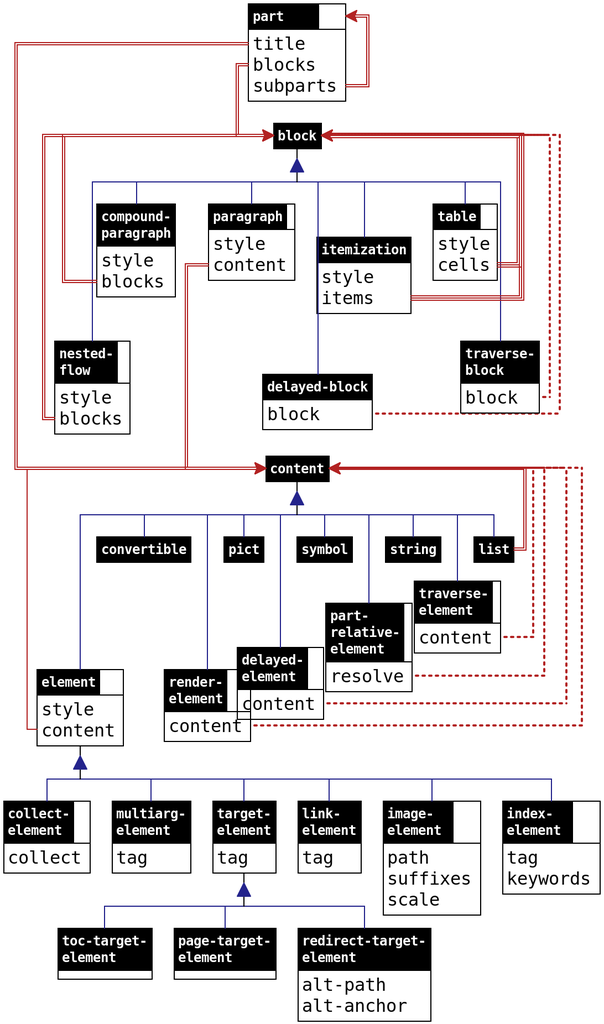

A part is an instance of part; among other things, it has a title content, an initial flow, and a list of subsection parts. There is no difference between a part and a full document; a particular source module just as easily defines a subsection (incorporated via include-section) as a document.

A flow is a list of blocks.

A block is either a table, an itemization, a nested flow, a paragraph, a compound paragraph, a traverse block, or a delayed block.

- A table is an instance of table; it has a list of list of blocks corresponding to table cells.
- A itemization is an instance of itemization; it has a list of flows.
- A nested flow is an instance of nested-flow; it has a flow that is typeset as sub-flow.
- A paragraph is an instance of paragraph; it has a content:
  - A content can be a string, one of a few symbols, a convertible value in the sense of [convertible?](http://docs.racket-lang.org/file/convertible.html#%28def._%28%28lib._file%2Fconvertible..rkt%29._convertible~3f%29%29), an instance of element (possibly link-element, etc.), a multiarg-element, a traverse element, a part-relative element, a delayed element, or a list of content.
    - A string is included in the result document verbatim, except for space, and unless the content’s enclosing style is 'hspace. In a style other than 'hspace, consecutive spaces in the output may be collapsed togther or replaced with a line break. In the style 'hspace, all text is converted to uncollapsible spaces that cannot be broken across lines.
    - A symbol content is either 'mdash, 'ndash, 'ldquo, 'lsquo, 'rdquo, 'rsquo, 'larr, 'rarr, or 'prime; it is rendered as the corresponding HTML entity (even for Latex output).
    - A convertible value in the sense of [convertible?](http://docs.racket-lang.org/file/convertible.html#%28def._%28%28lib._file%2Fconvertible..rkt%29._convertible~3f%29%29) is used in a renderer-specific way, but values convertible to 'text renders the same as the resulting string. If a renderer is not able to convert the value to a known format, the value is converted to a string using [write](http://docs.racket-lang.org/reference/Writing.html#%28def._%28%28quote._~23~25kernel%29._write%29%29).
    - An instance of element has a content plus a style. The style’s interpretation depends on the renderer, but it can be one of a few special symbols (such as 'bold) that are recognized by all renderers.
    - An instance of link-element has a tag for the target of the link.
    - An instance of target-element has a tag to be referenced by link-elements. An instance of the subtype toc-target-element is treated like a kind of section label, to be shown in the “on this page” table for HTML output.
    - An instance of index-element has a tag (as a target), a list of strings for the keywords (for sorting and search), and a list of contents to appear in the end-of-document index.
    - An instance of image-element incorporates an image from a file into the rendered document.
    - An instance of multiarg-element combines a style with a list of content, where the style corresponds to a rendered command that takes multiple arguments.
    - An instance of collect-element has a procedure that is called in the collect pass of document processing to record information used by later passes.
    - A traverse element is an instance of traverse-element, which ultimately produces content, but can accumulate and inspect information in the traverse pass.
    - A part-relative element is an instance of part-relative-element, which has a procedure that is called in the collect pass of document processing to obtain content. When the part-relative element’s procedure is called, collected information is not yet available, but information about the enclosing parts is available.
    - A delayed element is an instance of delayed-element, which has a procedure that is called in the resolve pass of document processing to obtain content.
    - An instance of render-element has a procedure that is called in the render pass of document processing.
- A compound paragraph is an instance of compound-paragraph; like blockquote, it has list of blocks, but the blocks are typeset as a single paragraph (e.g., no indentation after the first block) instead of inset.
- A traverse block is an instance of traverse-block, which ultimately produces another block, but can accumulate and inspect information during the traverse pass.
- A delayed block is an instance of delayed-block, which has a procedure that is called in the resolve pass of document processing to obtain a block.

Changed in version 1.23 of package scribble-lib: Changed the handling of [convertible?](http://docs.racket-lang.org/file/convertible.html#%28def._%28%28lib._file%2Fconvertible..rkt%29._convertible~3f%29%29) values to recognize a 'text conversion and otherwise use [write](http://docs.racket-lang.org/reference/Writing.html#%28def._%28%28quote._~23~25kernel%29._write%29%29).

##### 6.3.2Tags

A tag is a list containing a symbol and either a string, a generated-tag instance, or an arbitrary list. The symbol effectively identifies the type of the tag, such as 'part for a tag that links to a part, or 'def for a Racket function definition. The symbol also effectively determines the interpretation of the second half of the tag.

A part can have a tag prefix, which is effectively added onto the second item within each tag whose first item is 'part, 'tech, or 'cite, or whose second item is a list that starts with 'prefixable:

- The prefix is added to a string second item by creating a list containing the prefix and string.
- The prefix is added to a list second item after 'part, 'tech, or 'cite using [cons](http://docs.racket-lang.org/reference/pairs.html#%28def._%28%28quote._~23~25kernel%29._cons%29%29).
- The prefix is added to a second item that starts 'prefixable by adding it to the list after 'prefixable.
- A prefix is not added to a generated-tag item.

The prefix is used for reference outside the part, including the use of tags in the part’s tags field. Typically, a document’s main part has a tag prefix that applies to the whole document; references to sections and defined terms within the document from other documents must include the prefix, while references within the same document omit the prefix. Part prefixes can be used within a document as well, to help disambiguate references within the document.

Some procedures accept a “tag” that is just the string part of the full tag, where the symbol part is supplied automatically. For example, section and secref both accept a string “tag”, where 'part is implicit.

The scribble/tag library provides functions for constructing tags.

##### 6.3.3Styles

A style combines a style name with a list of style properties in a style structure. A style name is either a string, symbol, or #f. A style property can be anything, including a symbol or a structure such as color-property.

A style has a single style name, because the name typically corresponds to a configurable instruction to a renderer. For example, with Latex output, a string style name corresponds to a Latex command or environment. For more information on how string style names interact with configuration of a renderer, see Extending and Configuring Scribble Output. Symbolic style names, meanwhile, provide a simple layer of abstraction between the renderer and documents for widely supported style; for example, the 'italic style name is supported by all renderers.

Style properties within a style compose with style names and other properties. Again, symbols are often used for properties that are directly supported by renderers. For example, 'unnumbered style property for a part renders the part without a section number. Many properties are renderer-specific, such as a hover-property structure that associates text with an element to be shown in an HTML display when the mouse hovers over the text.

##### 6.3.4Collected and Resolved Information

The collect pass, resolve pass, and render pass processing steps all produce information that is specific to a rendering mode. Concretely, the operations are all represented as methods on a render<%> object.

The result of the collect method is a collect-info instance. This result is provided back as an argument to the resolve method, which produces a resolve-info value that encapsulates the results from both iterations. The resolve-info value is provided back to the resolve method for final rendering.

Optionally, before the resolve method is called, serialized information from other documents can be folded into the collect-info instance via the deserialize-info method. Other methods provide serialized information out of the collected and resolved records.

During the collect pass, the procedure associated with a collect-element instance can register information with collect-put!.

During the resolve pass, collected information for a part can be extracted with part-collected-info, which includes a part’s number and its parent part (or #f). More generally, the resolve-get method looks up information previously collected. This resolve-time information is normally obtained by the procedure associated with a delayed block or delayed element.

The resolve-get information accepts both a part and a resolve-info argument. The part argument enables searching for information in each enclosing part before sibling parts.

##### 6.3.5Structure Reference

> | struct ([struct](http://docs.racket-lang.org/reference/define-struct.html#%28form._%28%28lib._racket%2Fprivate%2Fbase..rkt%29._struct%29%29) part ( tag-prefix tags title-content style to-collect block… |
> | --- |
> | #:extra-constructor-name make-part) |
> | tag-prefix : ([or/c](http://docs.racket-lang.org/reference/data-structure-contracts.html#%28def._%28%28lib._racket%2Fcontract%2Fbase..rkt%29._or%2Fc%29%29) #f [string?](http://docs.racket-lang.org/ref… |
> | tags : ([listof](http://docs.racket-lang.org/reference/data-structure-contracts.html#%28def._%28%28lib._racket%2Fcontract%2Fbase..rkt%29._listof%29%29) tag?) |
> | title-content : ([or/c](http://docs.racket-lang.org/reference/data-structure-contracts.html#%28def._%28%28lib._racket%2Fcontract%2Fbase..rkt%29._or%2Fc%29%29) #f [list?](http://docs.racket-lang.org/re… |
> | style : style? |
> | to-collect : [list?](http://docs.racket-lang.org/reference/pairs.html#%28def._%28%28quote._~23~25kernel%29._list~3f%29%29) |
> | blocks : ([listof](http://docs.racket-lang.org/reference/data-structure-contracts.html#%28def._%28%28lib._racket%2Fcontract%2Fbase..rkt%29._listof%29%29) block?) |
> | parts : ([listof](http://docs.racket-lang.org/reference/data-structure-contracts.html#%28def._%28%28lib._racket%2Fcontract%2Fbase..rkt%29._listof%29%29) part?) |

The tag-prefix field determines the optional tag prefix for the part.

The tags indicates a list of tags that each link to the section. Normally, tags should be a non-empty list, so that hyperlinks can target the section.

The title-content field holds the part’s title, if any.

For the style field, the currently recognized symbolic style names are as follows:

- 'index — The part represents an index.

The recognized style properties are as follows:

- 'unnumbered — A section number is not computed or rendered for the section.
- 'hidden-number — A section number is computed for the section, but it is not rendered as part of the section name.
- 'toc-hidden — The part title is not shown in tables of contents, including in “on this page” boxes. For Latex rendering, the part title is omitted only if it is unnumbered or has a hidden number.
- 'hidden — The part title is not shown; for Latex output, the part title is not shown only if its is empty, and in that case, it is also excluded from tables of contents. The 'toc-hidden style property usually should be included with 'hidden (for consistency in non-Latex output).
- 'grouper — The part is numbered with a Roman numeral, by default, and its subsections continue numbering as if they appeared in the preceeding part. In other words, the part acts like a “part” in a book where chapter numbering is continuous across parts.
- numberer — A numberer created with make-numberer determines a representation of the part’s section number as an extension of it’s parent’s number. A numberer overrides the default representation, which is a natural number or (in the case of an accompanying 'grouper property) a Roman numeral. If a 'unnumbered property is also present, a numberer property is ignored.
- 'toc — Sub-parts of the part are rendered on separate pages for multi-page HTML mode.
- 'non-toc — Initial sub-parts of the part are not rendered on separate pages for multi-page HTML mode; this style property applies only to the main part.
- 'reveal — Shows sub-parts when this part is displayed in a table-of-contents panel in HTML output (which normally shows only the top-level sections).
- 'quiet — In HTML output and most other output modes, hides entries for sub-parts of this part in a table-of-contents or local-table-of-contents listing except when those sub-parts are top-level entries in the listing.
- 'no-toc+aux — As a style property for the main part of a rendered page, causes the HTML output to not include a margin box for the main table of contents, “on this page”, or tables with the 'aux style property. The 'no-toc+aux property effectively implies 'no-toc and 'no-sidebar, but also suppresses 'aux tables.
- 'no-toc — As a style property for the main part of a rendered page, causes the HTML output to not include a margin box for the main table of contents; the “on this page” box that contains toc-element and toc-target-element links (and that only includes an “on this page” label for multi-page documents) takes on the location and color of the main table of contents, instead.
- 'no-sidebar — As a style property for the main part of a document, causes the HTML output to not include an “on this page” margin box.
- 'no-index — Has no effect as a style property on a part, but as a style property on a title or part-start that provides a part’s style via decode, the 'no-index style property cause decode to skip the generation of an entry for the part’s title in the document index.
- document-version structure — A version number for this part and its sub-parts (except as overridden). When it is not "" may be used when rendering a document; at a minimum, a non-"" version is rendered when it is attached to a part representing the whole document. The default version for a document is ([version](http://docs.racket-lang.org/reference/runtime.html#%28def._%28%28quote._~23~25kernel%29._version%29%29)). In rendered form, the version is normally prefixed with the word “Version,” but this formatting can be controlled by overriding .version:before and/or .versionNoNav:before in CSS for HTML rendering or by redefining the \SVersionBefore macro for Latex rendering (see Extending and Configuring Scribble Output).
- document-date structure — A date for the part, normally used on a document’s main part for for Latex output. The default date for a document is #f, which avoids explicitly specifying a date at the Latex level, so that the current date is used as the document date. Set the date to "" to suppress a date in an output document.
- body-id structure — Generated HTML uses the given string id attribute of the <body> tag; this style property can be set separately for parts that start different HTML pages, otherwise it is effectively inherited by sub-parts; the default is "scribble-racket-lang.org", but raco setup installs "doc-racket-lang.org" as the id for any document that it builds.
- attributes structure — Provides additional HTML attributes for the <html> tag when the part corresponds to its own HTML page.
- head-extra structure — Provides additional HTML content for the <head> tag when the part corresponds to its own HTML page.
- color-property structure — For HTML, applies a color to the part title.
- background-color-property structure — For HTML, applies a color to the background of the part title.
- hover-property structure — For HTML, adds a text label to the title to be shown when the mouse hovers over it.
- render-convertible-as structure — For HTML, controls how objects that subscribe to the [file/convertible](http://docs.racket-lang.org/file/convertible.html) protocol are rendered.
- document-source structure — For HTML, provides a module path for the part’s source. Clicking on an HTML section title generated for the part or its sub-parts may show the module path plus a section-tag string, so that the user can create a reference to the section.
- link-render-style structure — Determines the default rendering of links to sections or other destinations within the section. See also link-element and current-link-render-style.
- 'enable-index-merge — On an index parts or one of its enclosing parts for Latex output, causes index entries to be merged when they have the same content, with multiple references for the same entry combined with \Smanypageref. The \Smanypageref Latex macro must be redefined to accept multiple ,-separated labels and generate a suitable set of references. See also [scriblib/book-index](http://docs.racket-lang.org/scriblib/book-index.html).

The to-collect field contains content that is inspected during the collect pass, but ignored in later passes (i.e., it doesn’t directly contribute to the output).

The blocks field contains the part’s initial flow (before sub-parts).

The parts field contains sub-parts.

Changed in version 1.25 of package scribble-lib: Added 'no-index support.  
Changed in version 1.26: Added link-render-style support.  
Changed in version 1.27: Added 'no-toc+aux support.

> | struct ([struct](http://docs.racket-lang.org/reference/define-struct.html#%28form._%28%28lib._racket%2Fprivate%2Fbase..rkt%29._struct%29%29) paragraph (style content) |
> | --- |
> | #:extra-constructor-name make-paragraph) |
> | style : style? |
> | content : content? |

A paragraph has a style and a content.

For the style field, a string style name corresponds to a CSS class for HTML output or a macro for Latex output (see Implementing Styles). The following symbolic style names are recognized:

- 'author — Typeset as the author of a document. Such paragraphs normally should appear only in the initial flow of a part for a document, where they are treated specially by the Latex renderer by moving the author information to the title.
- 'pretitle — Typeset before the title of the enclosing part.
- 'wraps — Like a #f style name, but not boxable in the sense of box-mode for Latex output.

When a paragraph’s style is #f, then it is boxable in the sense of box-mode for Latex output.

The currently recognized style properties are as follows:

- 'omitable — When a table cell contains a single paragraph with the 'omitable style property, then when rendering to HTML, no <p> tag wraps the cell content.
- 'div — Generates <div> HTML output instead of <p> (unless a alt-tag property is provided).
- alt-tag structure — Generates the indicated HTML tag instead of <p> or <div>.
- attributes structure — Provides additional HTML attributes for the <p>, <div>, or alternate tag.
- 'never-indents — For Latex and compound paragraphs; see compound-paragraph.
- box-mode structure — For Latex output, uses an alternate rendering form for boxing contexts (such as a table cell); see box-mode.

> | struct ([struct](http://docs.racket-lang.org/reference/define-struct.html#%28form._%28%28lib._racket%2Fprivate%2Fbase..rkt%29._struct%29%29) table (style blockss) |
> | --- |
> | #:extra-constructor-name make-table) |
> | style : style? |
> | blockss : ([listof](http://docs.racket-lang.org/reference/data-structure-contracts.html#%28def._%28%28lib._racket%2Fcontract%2Fbase..rkt%29._listof%29%29) ([listof](http://docs.racket-lang.org/referen… |

See also the tabular function.

A table has, roughly, a list of list of blocks. A cell in the table can span multiple columns by using 'cont instead of a block in the following columns (i.e., for all but the first in a set of cells that contain a single block).

Within style, a string style name corresponds to a CSS class for HTML output or an environment for Latex output (see Implementing Styles). The following symbolic style names are also recognized:

- 'boxed — Renders as a definition. This style name is not intended for use on a table that is nested within a 'boxed table; nested uses may look right for some renders of the style but not others.
- 'centered — Centers HTML output horizontally.
- 'block — Prevents pages breaks in Latex output.

The following style properties are currently recognized:

- table-columns structure — Provides column-specific styles, but only column-attributes properties (if any) are used if a table-cells structure is included as a style property. See table-cells for information about how a column style is used for each cell.
- table-cells structure — Provides cell-specific styles. See table-cells for information about how the styles are used.
- attributes structure — Provides additional HTML attributes for the <table> tag.
- 'aux — For HTML, include the table in the table-of-contents display for the enclosing part.
- 'never-indents — For Latex and compound paragraphs; see compound-paragraph.

For Latex output, a paragraph as a cell value is not automatically line-wrapped, unless a vertical alignment is specified for the cell through a table-cells or table-columns style property. To get a line-wrapped paragraph, use a compound-paragraph or use an element with a string style and define a corresponding Latex macro in terms of \parbox. For Latex output of blocks in the flow that are nested-flows, itemizations, compound-paragraphs, or delayed-blocks, the block is wrapped with minipage using \linewidth divided by the column count as the width.

> | struct ([struct](http://docs.racket-lang.org/reference/define-struct.html#%28form._%28%28lib._racket%2Fprivate%2Fbase..rkt%29._struct%29%29) itemization (style blockss) |
> | --- |
> | #:extra-constructor-name make-itemization) |
> | style : style? |
> | blockss : ([listof](http://docs.racket-lang.org/reference/data-structure-contracts.html#%28def._%28%28lib._racket%2Fcontract%2Fbase..rkt%29._listof%29%29) ([listof](http://docs.racket-lang.org/referen… |

A itemization has a style and a list of flows.

In style, a string style name corresponds to a CSS class for HTML output or a macro for Latex output (see Implementing Styles). In addition, the following symbolic style names are recognized:

- 'compact — Reduces space between items.
- 'ordered — Generates <ol> HTML output instead of <ul> or an Latex enumeration instead of an itemization.

The following style properties are currently recognized:

- attributes structure — Provides additional HTML attributes for the <ul> or <ol> tag.
- 'never-indents — For Latex and compound paragraphs; see compound-paragraph.

> | struct ([struct](http://docs.racket-lang.org/reference/define-struct.html#%28form._%28%28lib._racket%2Fprivate%2Fbase..rkt%29._struct%29%29) nested-flow (style blocks) |
> | --- |
> | #:extra-constructor-name make-nested-flow) |
> | style : style? |
> | blocks : ([listof](http://docs.racket-lang.org/reference/data-structure-contracts.html#%28def._%28%28lib._racket%2Fcontract%2Fbase..rkt%29._listof%29%29) block?) |

A nested flow has a style and a flow.

In style, the style name is normally a string that corresponds to a CSS class for HTML <blockquote> output or a Latex environment (see Implementing Styles). The following symbolic style names are recognized:

- 'inset — Insets the nested flow relative to surrounding text.
- 'code-inset — Insets the nested flow relative to surrounding text in a way suitable for code. If the nested flow has a single block, then it is boxable in the sense of box-mode for Latex output.
- 'vertical-inset — Insets the nested flow vertically relative to surrounding text, but not horizontally. If the nested flow has a single block, then it is boxable in the sense of box-mode for Latex output.

The following style properties are currently recognized:

- 'command — For Latex output, a string style name is used as a command name instead of an environment name.
- 'multicommand — For Latex output, a string style name is used as a command name with a separate argument for each block in blocks.
- attributes structure — Provides additional HTML attributes for the <blockquote> tag.
- 'never-indents — For Latex and compound paragraphs; see compound-paragraph.
- box-mode structure — For Latex output, uses an alternate rendering form for boxing contexts (such as a table cell); see box-mode.
- 'decorative — The content of the nested flow is intended for decoration. Text output skips a decorative nested flow.
- alt-tag structure — Generates the indicated HTML tag instead of <blockquote>.
- 'pretitle — For Latex, raises the contents of the flow to above the title.

> | struct ([struct](http://docs.racket-lang.org/reference/define-struct.html#%28form._%28%28lib._racket%2Fprivate%2Fbase..rkt%29._struct%29%29) compound-paragraph (style blocks) |
> | --- |
> | #:extra-constructor-name make-compound-paragraph) |
> | style : style? |
> | blocks : ([listof](http://docs.racket-lang.org/reference/data-structure-contracts.html#%28def._%28%28lib._racket%2Fcontract%2Fbase..rkt%29._listof%29%29) block?) |

A compound paragraph has a style and a list of blocks.

For HTML, a paragraph block in blocks is rendered without a <p> tag, unless the paragraph has a style with a non-#f style name. For Latex, each block in blocks is rendered with a preceding \noindent, unless the block has the 'never-indents property (checking recursively in a nested-flow or compound-paragraph if the nested-flow or compound-paragraph itself has no 'never-indents property).

The style field of a compound paragraph is normally a string that corresponds to a CSS class for HTML output or Latex environment for Latex output (see Implementing Styles). The following style properties are currently recognized:

- 'command — For Latex output, a string style name is used as a command name instead of an environment name.
- alt-tag structure — Generates the given HTML tag instead of <p>.
- attributes structure — Provides additional HTML attributes for the <p> or alternate tag.
- 'never-indents — For Latex within another compound paragraph; see above.

> | struct ([struct](http://docs.racket-lang.org/reference/define-struct.html#%28form._%28%28lib._racket%2Fprivate%2Fbase..rkt%29._struct%29%29) traverse-block (traverse) |
> | --- |
> | #:extra-constructor-name make-traverse-block) |
> | traverse : block-traverse-procedure/c |

Produces another block during the traverse pass, eventually.

The traverse procedure is called with get and set procedures to get and set symbol-keyed information; the traverse procedure should return either a block (which effectively takes the traverse-block’s place) or a procedure like traverse to be called in the next iteration of the traverse pass.

All traverse-element and traverse-blocks that have not been replaced are forced in document order relative to each other during an iteration of the traverse pass.

The get procedure passed to traverse takes a symbol and any value to act as a default; it returns information registered for the symbol or the given default if no value has been registered. The set procedure passed to traverse takes a symbol and a value to be registered for the symbol.

See also [cond-block](http://docs.racket-lang.org/scriblib/render-cond.html#%28form._%28%28lib._scriblib%2Frender-cond..rkt%29._cond-block%29%29) in [scriblib/render-cond](http://docs.racket-lang.org/scriblib/render-cond.html). The symbol 'scribble:current-render-mode is automatically registered to a list of symbols that describe the target of document rendering. The list contains 'html when rendering to HTML, 'latex when rendering via Latex, and 'text when rendering to text. The registration of 'scribble:current-render-mode cannot be changed via set.

> | struct ([struct](http://docs.racket-lang.org/reference/define-struct.html#%28form._%28%28lib._racket%2Fprivate%2Fbase..rkt%29._struct%29%29) delayed-block (resolve) |
> | --- |
> | #:extra-constructor-name make-delayed-block) |
> | resolve : ([any/c](http://docs.racket-lang.org/reference/data-structure-contracts.html#%28def._%28%28lib._racket%2Fcontract%2Fprivate%2Fmisc..rkt%29._any%2Fc%29%29) part? resolve-info? . [->](http://d… |

The resolve procedure is called during the resolve pass to obtain a normal block. The first argument to resolve is the renderer.

> | struct ([struct](http://docs.racket-lang.org/reference/define-struct.html#%28form._%28%28lib._racket%2Fprivate%2Fbase..rkt%29._struct%29%29) element (style content) |
> | --- |
> | #:extra-constructor-name make-element) |
> | style : element-style? |
> | content : content? |

Styled content within an enclosing paragraph or other content.

The style field can be a style structure, but it can also be just a style name.

In style, a string style name corresponds to a CSS class for HTML output and a macro name for Latex output (see Implementing Styles). The following symbolic style names are recognized:

- 'tt, 'italic, 'bold, 'roman, 'sf, 'url, 'subscript, 'superscript, 'smaller, 'larger — Basic styles recognized by all renders.
- 'hspace — Renders its content as monospace blanks.
- 'newline — Renders a line break independent of the content.
- 'no-break — Prevents line breaks when rendering content.

The following style properties are currently recognized:

- target-url structure — Generates a hyperlink.
- url-anchor structure — For HTML, inserts a hyperlink target before content.
- color-property structure — Applies a color to the text of content.
- background-color-property structure — Applies a color to the background of content.
- alt-tag structure — Generates the given HTML tag instead of the default one (<span>, <b>, etc.).
- attributes structure — Provides additional HTML attributes for a tag.
- hover-property structure — For HTML, adds a text label to the content to be shown when the mouse hovers over it.
- script-property structure — For HTML, supplies a script alternative to content.
- xexpr-property structure — For HTML, supplies literal HTML to render before and after content.
- 'aux — Intended for use in titles, where the auxiliary part of the title can be omitted in hyperlinks. See, for example, secref.
- 'tt-chars — For Latex output, when the style name is a string, render the element’s content with escapes suitable for Latex tt mode.
- 'exact-chars — For Latex output, when the style name is a string or #f, render the elements content exactly (without escapes).
- command-extras structure — For Latex output, adds strings as arguments to the Latex command.

Changed in version 1.6 of package scribble-lib: Changed 'exact-chars handling to take effect when the style name is #f.  
Changed in version 1.27: Changed to support xexpr-property.

> | struct ([struct](http://docs.racket-lang.org/reference/define-struct.html#%28form._%28%28lib._racket%2Fprivate%2Fbase..rkt%29._struct%29%29) image-element element (path suffixes scale) |
> | --- |
> | #:extra-constructor-name make-image-element) |
> | path : ([or/c](http://docs.racket-lang.org/reference/data-structure-contracts.html#%28def._%28%28lib._racket%2Fcontract%2Fbase..rkt%29._or%2Fc%29%29) [path-string?](http://docs.racket-lang.org/referen… |
> | suffixes : ([listof](http://docs.racket-lang.org/reference/data-structure-contracts.html#%28def._%28%28lib._racket%2Fcontract%2Fbase..rkt%29._listof%29%29) #rx"^[.]") |
> | scale : [real?](http://docs.racket-lang.org/reference/number-types.html#%28def._%28%28quote._~23~25kernel%29._real~3f%29%29) |

Used as a style for an element to inline an image. The path field can be a result of [path->main-collects-relative](http://docs.racket-lang.org/raco/relative-paths.html#%28def._%28%28lib._setup%2Fmain-collects..rkt%29._path-~3emain-collects-relative%29%29).

For each string in suffixes, if the rendered works with the corresponding suffix, the suffix is added to path and used if the resulting path refers to a file that exists. The order in suffixes determines the order in which suffixes are tried. The HTML renderer supports ".png", ".gif", and ".svg", while the Latex renderer supports ".png", ".pdf", and ".ps" (but rendering Latex output to PDF will not work with ".ps" files, while rendering to Latex DVI output works only with ".ps" files). If suffixes is empty or if none of the suffixes lead to files that exist, path is used as-is.

The scale field scales the image in its rendered form.

> | struct ([struct](http://docs.racket-lang.org/reference/define-struct.html#%28form._%28%28lib._racket%2Fprivate%2Fbase..rkt%29._struct%29%29) target-element element (tag) |
> | --- |
> | #:extra-constructor-name make-target-element) |
> | tag : tag? |

Declares the content as a hyperlink target for tag.

> > struct

> > | ([struct](http://docs.racket-lang.org/reference/define-struct.html#%28form._%28%28lib._racket%2Fprivate%2Fbase..rkt%29._struct%29%29) |  | toc-target-element target-element () |
> > | --- | --- | --- |

> #:extra-constructor-name make-toc-target-element)

Like target-element, the content is also a kind of section label to be shown in the “on this page” table for HTML output.

> | struct ([struct](http://docs.racket-lang.org/reference/define-struct.html#%28form._%28%28lib._racket%2Fprivate%2Fbase..rkt%29._struct%29%29) toc-target2-element toc-target-element (toc-content) |
> | --- |
> | #:extra-constructor-name make-toc-target2-element) |
> | toc-content : content? |

Extends target-element with a separate field for the content to be shown in the “on this page” table for HTML output.

> > struct

> > | ([struct](http://docs.racket-lang.org/reference/define-struct.html#%28form._%28%28lib._racket%2Fprivate%2Fbase..rkt%29._struct%29%29) |  | page-target-element target-element () |
> > | --- | --- | --- |

> #:extra-constructor-name make-page-target-element)

Like target-element, but a link to the element goes to the top of the containing page.

> | struct ([struct](http://docs.racket-lang.org/reference/define-struct.html#%28form._%28%28lib._racket%2Fprivate%2Fbase..rkt%29._struct%29%29) redirect-target-element target-element ( alt-path alt-ancho… |
> | --- |
> | #:extra-constructor-name make-redirect-target-element) |
> | alt-path : [path-string?](http://docs.racket-lang.org/reference/Manipulating_Paths.html#%28def._%28%28lib._racket%2Fprivate%2Fmisc..rkt%29._path-string~3f%29%29) |
> | alt-anchor : [string?](http://docs.racket-lang.org/reference/strings.html#%28def._%28%28quote._~23~25kernel%29._string~3f%29%29) |

Like target-element, but a link to the element is redirected to the given URL.

> | struct ([struct](http://docs.racket-lang.org/reference/define-struct.html#%28form._%28%28lib._racket%2Fprivate%2Fbase..rkt%29._struct%29%29) toc-element element (toc-content) |
> | --- |
> | #:extra-constructor-name make-toc-element) |
> | toc-content : content? |

Similar to toc-target-element, but with specific content for the “on this page” table specified in the toc-content field.

> | struct ([struct](http://docs.racket-lang.org/reference/define-struct.html#%28form._%28%28lib._racket%2Fprivate%2Fbase..rkt%29._struct%29%29) link-element element (tag) |
> | --- |
> | #:extra-constructor-name make-link-element) |
> | tag : tag? |

Represents a hyperlink to tag.

Normally, the content of the element is rendered as the hyperlink. When tag is a part tag and the content of the element is [null](http://docs.racket-lang.org/reference/pairs.html#%28def._%28%28quote._~23~25kernel%29._null%29%29), however, rendering is treated specially based on the mode value of a link-render-style style property:

- For HTML output, in the 'default mode, the generated reference is the hyperlinked title of the elements in the section’s title content, except that elements with the 'aux style property are omitted in the hyperlink label.

  In 'number mode, the section title is not shown. Instead, the word “section” is shown followed by a hyperlinked section number. The word “section” starts in uppercase if the element’s style includes a 'uppercase property.
- For Latex/PDF output, the generated reference’s format can depend on the document style in addition the mode. For the 'default mode and a default document style, a section number is shown by the word “section” followed by the section number, and the word “section” and the section number are together hyperlinked. The word “section” starts in uppercase if the element’s style includes a 'uppercase property. The scribble/manual style uses the symbol “§” in place of the word “section”.

  In 'number mode, rendering is the same, except that only the number is hyperlinked, not the word “section” or the “§” symbol.

  A new document style can customize Latex/PDF output (see Extending and Configuring Scribble Output) by redefining the \SecRefLocal, etc., macros (see Base Latex Macros). The \SecRef, etc., variants are used in 'number mode.

If a link-render-style style property is not attached to a link-element that refers to a part, a link-render-style style property that is attached to an enclosing part is used, since attaching a link-render-style style property to a part causes current-link-render-style to be set while rendering the part. Otherwise, the render-time value of current-link-render-style determine’s a link-element’s rendering.

The following style properties are recognized in addition to the style properties for all elements:

- link-render-style structure — As described above.
- 'indirect-link — For HTML output, treats the link as “external”. When rendering to HTML and the set-external-tag-path method is called to provide an external-link URL, then the resolution of the hyperlink can be deferred until the link is clicked (or, in some cases, patched by JavaScript when the documentation is viewed in a browser).

  Note that deferred resolution relies on cooperation with the page pointed to by the external-link URL, and arbitrary tags are not supported. Functions and forms like seclink, other-doc, racketmodname, tech, and techlink provide higher-level interfaces for creating supported kinds of indirect links.

Changed in version 1.26 of package scribble-lib: Added link-render-style support.

> | struct ([struct](http://docs.racket-lang.org/reference/define-struct.html#%28form._%28%28lib._racket%2Fprivate%2Fbase..rkt%29._struct%29%29) index-element element (tag plain-seq entry-seq desc) |
> | --- |
> | #:extra-constructor-name make-index-element) |
> | tag : tag? |
> | plain-seq : ([and/c](http://docs.racket-lang.org/reference/data-structure-contracts.html#%28def._%28%28lib._racket%2Fcontract%2Fbase..rkt%29._and%2Fc%29%29) [pair?](http://docs.racket-lang.org/referen… |
> | entry-seq : ([listof](http://docs.racket-lang.org/reference/data-structure-contracts.html#%28def._%28%28lib._racket%2Fcontract%2Fbase..rkt%29._listof%29%29) content?) |
> | desc : [any/c](http://docs.racket-lang.org/reference/data-structure-contracts.html#%28def._%28%28lib._racket%2Fcontract%2Fprivate%2Fmisc..rkt%29._any%2Fc%29%29) |

The plain-seq specifies the keys for sorting, where the first string is the main key, the second is a sub-key, etc. For example, an “night” portion of an index might have sub-entries for “night, things that go bump in” and “night, defender of the”. The former would be represented by plain-seq '("night" "things that go bump in"), and the latter by '("night" "defender of the"). Naturally, single-string plain-seq lists are the common case, and at least one word is required, but there is no limit to the word-list length. The strings in plain-seq must not contain a newline character.

The entry-seq list must have the same length as plain-seq. It provides the form of each key to render in the final document.

The desc field provides additional information about the index entry as supplied by the entry creator. For example, a reference to a procedure binding can be recognized when desc is an instance of procedure-index-desc. See scribble/manual-struct for other typical types of desc values.

See also index.

> | struct ([struct](http://docs.racket-lang.org/reference/define-struct.html#%28form._%28%28lib._racket%2Fprivate%2Fbase..rkt%29._struct%29%29) multiarg-element (style contents) |
> | --- |
> | #:extra-constructor-name make-multiarg-element) |
> | style : element-style? |
> | contents : ([listof](http://docs.racket-lang.org/reference/data-structure-contracts.html#%28def._%28%28lib._racket%2Fcontract%2Fbase..rkt%29._listof%29%29) content?) |

Like element with a list for content, except that for Latex output, if the style name in style is a string, then it corresponds to a Latex command that accepts as many arguments (each in curly braces) as elements of contents.

> | struct ([struct](http://docs.racket-lang.org/reference/define-struct.html#%28form._%28%28lib._racket%2Fprivate%2Fbase..rkt%29._struct%29%29) traverse-element (traverse) |
> | --- |
> | #:extra-constructor-name make-traverse-element) |
> | traverse : element-traverse-procedure/c |

See also [cond-element](http://docs.racket-lang.org/scriblib/render-cond.html#%28form._%28%28lib._scriblib%2Frender-cond..rkt%29._cond-element%29%29) in [scriblib/render-cond](http://docs.racket-lang.org/scriblib/render-cond.html). Like traverse-block, but the traverse procedure must eventually produce content, rather than a block.

> | struct ([struct](http://docs.racket-lang.org/reference/define-struct.html#%28form._%28%28lib._racket%2Fprivate%2Fbase..rkt%29._struct%29%29) delayed-element (resolve sizer plain) |
> | --- |
> | #:extra-constructor-name make-delayed-element) |
> | resolve : ([any/c](http://docs.racket-lang.org/reference/data-structure-contracts.html#%28def._%28%28lib._racket%2Fcontract%2Fprivate%2Fmisc..rkt%29._any%2Fc%29%29) part? resolve-info? . [->](http://d… |
> | sizer : ([->](http://docs.racket-lang.org/reference/function-contracts.html#%28form._%28%28lib._racket%2Fcontract%2Fbase..rkt%29._-~3e%29%29) [any/c](http://docs.racket-lang.org/reference/data-structu… |
> | plain : ([->](http://docs.racket-lang.org/reference/function-contracts.html#%28form._%28%28lib._racket%2Fcontract%2Fbase..rkt%29._-~3e%29%29) [any/c](http://docs.racket-lang.org/reference/data-structu… |

The resolve procedure’s arguments are the same as for delayed-block, but the result is content. Unlike delayed-block, the result of the resolve procedure’s argument is remembered on the first call for re-use for a particular resolve pass.

The sizer field is a procedure that produces a substitute content for the delayed element for the purposes of determining the delayed element’s width (see element-width).

The plain field is a procedure that produces a substitute content when needed before the collect pass, such as when element->string is used before the collect pass.

> | struct ([struct](http://docs.racket-lang.org/reference/define-struct.html#%28form._%28%28lib._racket%2Fprivate%2Fbase..rkt%29._struct%29%29) part-relative-element (resolve sizer plain) |
> | --- |
> | #:extra-constructor-name make-part-relative-element) |
> | resolve : (collect-info? . [->](http://docs.racket-lang.org/reference/function-contracts.html#%28form._%28%28lib._racket%2Fcontract%2Fbase..rkt%29._-~3e%29%29) . content?) |
> | sizer : ([->](http://docs.racket-lang.org/reference/function-contracts.html#%28form._%28%28lib._racket%2Fcontract%2Fbase..rkt%29._-~3e%29%29) [any/c](http://docs.racket-lang.org/reference/data-structu… |
> | plain : ([->](http://docs.racket-lang.org/reference/function-contracts.html#%28form._%28%28lib._racket%2Fcontract%2Fbase..rkt%29._-~3e%29%29) [any/c](http://docs.racket-lang.org/reference/data-structu… |

Similar to delayed-block, but the replacement content is obtained in the collect pass by calling the function in the resolve field.

The resolve function can call collect-info-parents to obtain a list of parts that enclose the element, starting with the nearest enclosing section. Functions like part-collected-info and collected-info-number can extract information like the part number.

> | struct ([struct](http://docs.racket-lang.org/reference/define-struct.html#%28form._%28%28lib._racket%2Fprivate%2Fbase..rkt%29._struct%29%29) collect-element element (collect) |
> | --- |
> | #:extra-constructor-name make-collect-element) |
> | collect : (collect-info . [->](http://docs.racket-lang.org/reference/function-contracts.html#%28form._%28%28lib._racket%2Fcontract%2Fbase..rkt%29._-~3e%29%29) . [any](http://docs.racket-lang.org/refer… |

Like element, but the collect procedure is called during the collect pass. The collect procedure normally calls collect-put!.

Unlike delayed-element or part-relative-element, the element remains intact (i.e., it is not replaced) by either the collect pass or resolve pass.

> | struct ([struct](http://docs.racket-lang.org/reference/define-struct.html#%28form._%28%28lib._racket%2Fprivate%2Fbase..rkt%29._struct%29%29) render-element element (render) |
> | --- |
> | #:extra-constructor-name make-render-element) |
> | render : ([any/c](http://docs.racket-lang.org/reference/data-structure-contracts.html#%28def._%28%28lib._racket%2Fcontract%2Fprivate%2Fmisc..rkt%29._any%2Fc%29%29) part? resolve-info? . [->](http://do… |

Like delayed-element, but the render procedure is called during the render pass.

If a render-element instance is serialized (such as when saving collected info), it is reduced to a element instance.

> | struct ([struct](http://docs.racket-lang.org/reference/define-struct.html#%28form._%28%28lib._racket%2Fprivate%2Fbase..rkt%29._struct%29%29) collected-info (number parent info) |
> | --- |
> | #:extra-constructor-name make-collected-info) |
> | number : ([listof](http://docs.racket-lang.org/reference/data-structure-contracts.html#%28def._%28%28lib._racket%2Fcontract%2Fbase..rkt%29._listof%29%29) part-number-item?) |
> | parent : ([or/c](http://docs.racket-lang.org/reference/data-structure-contracts.html#%28def._%28%28lib._racket%2Fcontract%2Fbase..rkt%29._or%2Fc%29%29) #f part?) |
> | info : [any/c](http://docs.racket-lang.org/reference/data-structure-contracts.html#%28def._%28%28lib._racket%2Fcontract%2Fprivate%2Fmisc..rkt%29._any%2Fc%29%29) |

Computed for each part by the collect pass.

The length of the number list indicates the section’s nesting depth. Elements of number correspond to the section’s number, it’s parent’s number, and so on (that is, the section numbers are in reverse order):

- A number value corresponds to a normally numbered section.
- A non-empty string corresponds to a 'grouper section, which is shown as part of the combined section number only when it’s the first element.
- A a list corresponds to a numberer-generated section string plus its separator string, where the separator is used in a combined section number after the section string and before a subsection’s number (or, for some output modes, before the title of the section).
- For an unnumbered section, a #f is used in place of any number or lists element, while "" is used in place of all non-empty strings.

Changed in version 1.1 of package scribble-lib: Added ([list/c](http://docs.racket-lang.org/reference/data-structure-contracts.html#%28def._%28%28lib._racket%2Fcontract%2Fbase..rkt%29._list%2Fc%29%29) [string?](http://docs.racket-lang.org/reference/strings.html#%28def._%28%28quote._~23~25kernel%29._string~3f%29%29) [string?](http://docs.racket-lang.org/reference/strings.html#%28def._%28%28quote._~23~25kernel%29._string~3f%29%29)) number items for numberer-generated section numbers.

> | struct ([struct](http://docs.racket-lang.org/reference/define-struct.html#%28form._%28%28lib._racket%2Fprivate%2Fbase..rkt%29._struct%29%29) target-url (addr) |
> | --- |
> | #:extra-constructor-name make-target-url) |
> | addr : [path-string?](http://docs.racket-lang.org/reference/Manipulating_Paths.html#%28def._%28%28lib._racket%2Fprivate%2Fmisc..rkt%29._path-string~3f%29%29) |

Used as a style property for an element. A path is allowed for addr, but a string is interpreted as a URL rather than a file path.

> | struct ([struct](http://docs.racket-lang.org/reference/define-struct.html#%28form._%28%28lib._racket%2Fprivate%2Fbase..rkt%29._struct%29%29) document-version (text) |
> | --- |
> | #:extra-constructor-name make-document-version) |
> | text : ([or/c](http://docs.racket-lang.org/reference/data-structure-contracts.html#%28def._%28%28lib._racket%2Fcontract%2Fbase..rkt%29._or%2Fc%29%29) [string?](http://docs.racket-lang.org/reference/st… |

Used as a style property for a part to indicate a version number.

> | struct ([struct](http://docs.racket-lang.org/reference/define-struct.html#%28form._%28%28lib._racket%2Fprivate%2Fbase..rkt%29._struct%29%29) document-date (text) |
> | --- |
> | #:extra-constructor-name make-document-date) |
> | text : ([or/c](http://docs.racket-lang.org/reference/data-structure-contracts.html#%28def._%28%28lib._racket%2Fcontract%2Fbase..rkt%29._or%2Fc%29%29) [string?](http://docs.racket-lang.org/reference/st… |

Used as a style property for a part to indicate a date (which is typically used for Latex output).

> | struct ([struct](http://docs.racket-lang.org/reference/define-struct.html#%28form._%28%28lib._racket%2Fprivate%2Fbase..rkt%29._struct%29%29) color-property (color) |
> | --- |
> | #:extra-constructor-name make-color-property) |
> | color : ([or/c](http://docs.racket-lang.org/reference/data-structure-contracts.html#%28def._%28%28lib._racket%2Fcontract%2Fbase..rkt%29._or%2Fc%29%29) [string?](http://docs.racket-lang.org/reference/s… |

Used as a style property for an element to set its color. Recognized string names for color depend on the renderer, but at the recognized set includes at least "white", "black", "red", "green", "blue", "cyan", "magenta", and "yellow". When color is a list of bytes, the values are used as RGB levels.

When rendering to HTML, a color-property is also recognized for a block, part (and used for the title in the latter case)or cell in a table.

> | struct ([struct](http://docs.racket-lang.org/reference/define-struct.html#%28form._%28%28lib._racket%2Fprivate%2Fbase..rkt%29._struct%29%29) background-color-property (color) |
> | --- |
> | #:extra-constructor-name make-background-color-property) |
> | color : ([or/c](http://docs.racket-lang.org/reference/data-structure-contracts.html#%28def._%28%28lib._racket%2Fcontract%2Fbase..rkt%29._or%2Fc%29%29) [string?](http://docs.racket-lang.org/reference/s… |

Like color-property, but sets the background color.

> | struct ([struct](http://docs.racket-lang.org/reference/define-struct.html#%28form._%28%28lib._racket%2Fprivate%2Fbase..rkt%29._struct%29%29) table-cells (styless) |
> | --- |
> | #:extra-constructor-name make-table-cells) |
> | styless : ([listof](http://docs.racket-lang.org/reference/data-structure-contracts.html#%28def._%28%28lib._racket%2Fcontract%2Fbase..rkt%29._listof%29%29) ([listof](http://docs.racket-lang.org/referen… |

Used as a style property for a table to set its cells’ styles.

If a cell style has a string name, it is used as an HTML class for the <td> tag or as a Latex command name.

The following are recognized as cell-style properties:

- 'left — Left-align the cell content.
- 'right — Right-align the cell content top baselines.
- 'center — Center the cell content horizontally.
- 'top — Top-align the cell content.
- 'baseline — Align the cell content top baselines.
- 'bottom — bottom-align the cell content.
- 'vcenter — Center the cell content vertically.
- 'border — Draw a line around all sides of the cell. Borders along a shared edge of adjacent cells are collapsed into a single line.
- 'left-border, 'right-border, 'top-border, or 'bottom-border — Draw a line along the corresponding side of the cell (with the same border collapsing as for 'border).
- color-property structure — For HTML, applies a color to the cell content.
- background-color-property structure — For HTML, applies a color to the background of the cell.
- attributes — Provides additional HTML attributes for the cell’s <td> tag.

Changed in version 1.1 of package scribble-lib: Added color-property and background-color-property support.  
Changed in version 1.4: Added 'border, 'left-border, 'right-border, 'top-border, and 'bottom-border support.

> | struct ([struct](http://docs.racket-lang.org/reference/define-struct.html#%28form._%28%28lib._racket%2Fprivate%2Fbase..rkt%29._struct%29%29) table-columns (styles) |
> | --- |
> | #:extra-constructor-name make-table-columns) |
> | styles : ([listof](http://docs.racket-lang.org/reference/data-structure-contracts.html#%28def._%28%28lib._racket%2Fcontract%2Fbase..rkt%29._listof%29%29) style?) |

Like table-cells, but with support for a column-attributes property in each style, and the styles list is otherwise duplicated for each row in the table. The non-column-attributes parts of a table-columns are used only when a table-cells property is not present along with the table-columns property.

For HTML table rendering, for each column that has a column-attributes property in the corresponding element of styles, the attributes are put into an HTML col tag within the table.

> | struct ([struct](http://docs.racket-lang.org/reference/define-struct.html#%28form._%28%28lib._racket%2Fprivate%2Fbase..rkt%29._struct%29%29) box-mode (top-name center-name bottom-name) |
> | --- |
> | #:extra-constructor-name make-box-mode) |
> | top-name : [string?](http://docs.racket-lang.org/reference/strings.html#%28def._%28%28quote._~23~25kernel%29._string~3f%29%29) |
> | center-name : [string?](http://docs.racket-lang.org/reference/strings.html#%28def._%28%28quote._~23~25kernel%29._string~3f%29%29) |
> | bottom-name : [string?](http://docs.racket-lang.org/reference/strings.html#%28def._%28%28quote._~23~25kernel%29._string~3f%29%29) |

> | procedure (box-mode* name) → box-mode? |
> | --- |
> | name : [string?](http://docs.racket-lang.org/reference/strings.html#%28def._%28%28quote._~23~25kernel%29._string~3f%29%29) |

As a style property, indicates that a nested flow or paragraph is boxable when it is used in a boxing context for Latex output, but a nested flow is boxable only if its content is also boxable.

A boxing context starts with a table cell in a multi-column table, and the content of a block in a boxing context is also in a boxing context. If the cell’s content is boxable, then the content determines the width of the cell, otherwise a width is imposed. A paragraph with a #f style name is boxable as a single line; the 'wraps style name makes the paragraph non-boxable so that its width is imposed and its content can use multiple lines. A table is boxable when that all of its cell content is boxable.

To generate output in box mode, the box-mode property supplies Latex macro names to apply to the nested flow or paragraph content. The top-name macro is used if the box’s top line is to be aligned with other boxes, center-name if the box’s center is to be aligned, and bottom-name if the box’s bottom line is to be aligned. The box-mode* function creates a box-mode structure with the same name for all three fields.

A box-mode style property overrides any automatic boxed rendering (e.g., for a paragraph with style name #f). If a block has both a box-mode style property and a 'multicommand style property, then the Latex macro top-name, center-name, or bottom-name is applied with a separate argument for each of its content.

> | procedure (block? v) → [boolean?](http://docs.racket-lang.org/reference/booleans.html#%28def._%28%28quote._~23~25kernel%29._boolean~3f%29%29) |
> | --- |
> | v : [any/c](http://docs.racket-lang.org/reference/data-structure-contracts.html#%28def._%28%28lib._racket%2Fcontract%2Fprivate%2Fmisc..rkt%29._any%2Fc%29%29) |

Returns #t if v is a paragraph, table, itemization, nested-flow, traverse-block, or delayed-block, #f otherwise.

> | procedure (content? v) → [boolean?](http://docs.racket-lang.org/reference/booleans.html#%28def._%28%28quote._~23~25kernel%29._boolean~3f%29%29) |
> | --- |
> | v : [any/c](http://docs.racket-lang.org/reference/data-structure-contracts.html#%28def._%28%28lib._racket%2Fcontract%2Fprivate%2Fmisc..rkt%29._any%2Fc%29%29) |

Returns #t if v is a string, symbol, element, multiarg-element, traverse-element, delayed-element, part-relative-element, a convertible value in the sense of [convertible?](http://docs.racket-lang.org/file/convertible.html#%28def._%28%28lib._file%2Fconvertible..rkt%29._convertible~3f%29%29), or list of content. Otherwise, it returns #f.

> | struct ([struct](http://docs.racket-lang.org/reference/define-struct.html#%28form._%28%28lib._racket%2Fprivate%2Fbase..rkt%29._struct%29%29) style (name properties) |
> | --- |
> | #:extra-constructor-name make-style) |
> | name : ([or/c](http://docs.racket-lang.org/reference/data-structure-contracts.html#%28def._%28%28lib._racket%2Fcontract%2Fbase..rkt%29._or%2Fc%29%29) [string?](http://docs.racket-lang.org/reference/st… |
> | properties : [list?](http://docs.racket-lang.org/reference/pairs.html#%28def._%28%28quote._~23~25kernel%29._list~3f%29%29) |

Represents a style.

> | value plain : style? |
> | --- |

A style (make-style #f [null](http://docs.racket-lang.org/reference/pairs.html#%28def._%28%28quote._~23~25kernel%29._null%29%29)).

> | procedure (element-style? v) → [boolean?](http://docs.racket-lang.org/reference/booleans.html#%28def._%28%28quote._~23~25kernel%29._boolean~3f%29%29) |
> | --- |
> | v : [any/c](http://docs.racket-lang.org/reference/data-structure-contracts.html#%28def._%28%28lib._racket%2Fcontract%2Fprivate%2Fmisc..rkt%29._any%2Fc%29%29) |

Returns #t if v is a string, symbol, #f, or style structure.

> | procedure (tag? v) → [boolean?](http://docs.racket-lang.org/reference/booleans.html#%28def._%28%28quote._~23~25kernel%29._boolean~3f%29%29) |
> | --- |
> | v : [any/c](http://docs.racket-lang.org/reference/data-structure-contracts.html#%28def._%28%28lib._racket%2Fcontract%2Fprivate%2Fmisc..rkt%29._any%2Fc%29%29) |

Returns #t if v is acceptable as a link tag, which is a list containing a symbol and either a string, a generated-tag instance, or a non-empty list of [serializable?](http://docs.racket-lang.org/reference/serialization.html#%28def._%28%28lib._racket%2Fprivate%2Fserialize..rkt%29._serializable~3f%29%29) values.

> > struct

> > | ([struct](http://docs.racket-lang.org/reference/define-struct.html#%28form._%28%28lib._racket%2Fprivate%2Fbase..rkt%29._struct%29%29) |  | generated-tag () |
> > | --- | --- | --- |

> #:extra-constructor-name make-generated-tag)

A placeholder for a tag to be generated during the collect pass. Use tag-key to convert a tag containing a generated-tag instance to one containing a string.

> | procedure (content->string content) → [string?](http://docs.racket-lang.org/reference/strings.html#%28def._%28%28quote._~23~25kernel%29._string~3f%29%29) |
> | --- |
> | content : content? |
> | (content->string content renderer p info) → [string?](http://docs.racket-lang.org/reference/strings.html#%28def._%28%28quote._~23~25kernel%29._string~3f%29%29) |
> | content : content? |
> | renderer : [any/c](http://docs.racket-lang.org/reference/data-structure-contracts.html#%28def._%28%28lib._racket%2Fcontract%2Fprivate%2Fmisc..rkt%29._any%2Fc%29%29) |
> | p : part? |
> | info : resolve-info? |

Converts content to a single string (essentially rendering the content as “plain text”).

If p and info arguments are not supplied, then a pre-“collect” substitute is obtained for delayed elements. Otherwise, the two arguments are used to force the delayed element (if it has not been forced already).

> | procedure (content-width c) → [exact-nonnegative-integer?](http://docs.racket-lang.org/reference/number-types.html#%28def._%28%28quote._~23~25kernel%29._exact-nonnegative-integer~3f%29%29) |
> | --- |
> | c : content? |

Returns the width in characters of the given content.

> | procedure (block-width e) → [exact-nonnegative-integer?](http://docs.racket-lang.org/reference/number-types.html#%28def._%28%28quote._~23~25kernel%29._exact-nonnegative-integer~3f%29%29) |
> | --- |
> | e : block? |

Returns the width in characters of the given block.

> | procedure (part-number-item? v) → boolean |
> | --- |
> | v : [any/c](http://docs.racket-lang.org/reference/data-structure-contracts.html#%28def._%28%28lib._racket%2Fcontract%2Fprivate%2Fmisc..rkt%29._any%2Fc%29%29) |

Return #t if v is #f, an exact non-negative integer, a string, or a list containing two strings. See collected-info for information on how different representations are used for numbering.

Added in version 1.1 of package scribble-lib.

> | procedure (numberer? v) → [boolean?](http://docs.racket-lang.org/reference/booleans.html#%28def._%28%28quote._~23~25kernel%29._boolean~3f%29%29) v : [any/c](http://docs.racket-lang.org/reference/data-… |
> | --- |
> | procedure (make-numberer step initial-value) → numberer? step : ([any/c](http://docs.racket-lang.org/reference/data-structure-contracts.html#%28def._%28%28lib._racket%2Fcontract%2Fprivate%2Fmisc..rkt%… |
> | procedure (numberer-step n parent-number ci numberer-values) → part-number-item? [hash?](http://docs.racket-lang.org/reference/hashtables.html#%28def._%28%28quote._~23~25kernel%29._hash~3f%29%29) n : … |

A numberer implements a representation of a section number that increment separately from the default numbering style and that can be rendered differently than as Arabic numerals.

The numberer? function returns #t if v is a numberer, or #f otherwise.

The make-numberer function creates a numberer. The step function computes both the current number’s representation and increments the number, where the “number” can be an arbitrary value; the initial-value argument determines the initial value of the “number”, and the step function receives the current value as its first argument and returns an incremented value as its second result. A numberer’s “number” value starts fresh at each new nesting level. In addition to the numberer’s current value, the step function receives the parent section’s numbering (so that its result can depend on the part’s nesting depth).

The numberer-step function is normally used by a renderer. It applies a numberer, given the parent section’s number, a collect-info value, and a hash table that accumulates numberer values at a given nesting layer. The collect-info argument is needed because a numberer’s identity is based on a generated-tag. The result of numberer-step is the rendered form of the current section number plus an updated hash table with an incremented value for the numberer.

Typically, the rendered form of a section number (produced by numberer-step) is a list containing two strings. The first string is the part’s immediate number, which can be combined with a prefix for enclosing parts’ numbers. The second string is a separator that is placed after the part’s number and before a subsection’s number for each subsection. If numberer-step produces a plain string for the rendered number, then it is not added as a prefix to subsection numbers. See also collected-info.

Added in version 1.1 of package scribble-lib.

> | struct ([struct](http://docs.racket-lang.org/reference/define-struct.html#%28form._%28%28lib._racket%2Fprivate%2Fbase..rkt%29._struct%29%29) link-render-style (mode) |
> | --- |
> | #:extra-constructor-name make-link-render-style) |
> | mode : ([or/c](http://docs.racket-lang.org/reference/data-structure-contracts.html#%28def._%28%28lib._racket%2Fcontract%2Fbase..rkt%29._or%2Fc%29%29) 'default 'number) |

Used as a style property for a part or a specific link-element to control the way that a hyperlink is rendered for a part via secref or for a figure via [figure-ref](http://docs.racket-lang.org/scriblib/figure.html#%28def._%28%28lib._scriblib%2Ffigure..rkt%29._figure-ref%29%29) from [scriblib/figure](http://docs.racket-lang.org/scriblib/figure.html).

The 'default and 'number modes represent generic hyperlink-style configurations that could make sense for various kinds of references. The 'number style is intended to mean that a specific number is shown for the reference and that only the number is hyperlinked. The 'default style is more flexible, allowing a more appropriate choice for the rendering context, such as using the target section’s name for a hyperlink in HTML.

Added in version 1.26 of package scribble-lib.

> | parameter (current-link-render-style) → link-render-style? |
> | --- |
> | (current-link-render-style style) → [void?](http://docs.racket-lang.org/reference/void.html#%28def._%28%28quote._~23~25kernel%29._void~3f%29%29) |
> | style : link-render-style? |

A parameter that determines the default rendering style for a section link.

When a part has a link-render-style as one of its style properties, then the current-link-render-style parameter is set during the resolve pass and render pass for the part’s content.

Added in version 1.26 of package scribble-lib.

> | struct ([struct](http://docs.racket-lang.org/reference/define-struct.html#%28form._%28%28lib._racket%2Fprivate%2Fbase..rkt%29._struct%29%29) collect-info ( fp ht ext-ht ext-demand parts tags gen-prefi… |
> | --- |
> | #:extra-constructor-name make-collect-info) |
> | fp : [any/c](http://docs.racket-lang.org/reference/data-structure-contracts.html#%28def._%28%28lib._racket%2Fcontract%2Fprivate%2Fmisc..rkt%29._any%2Fc%29%29) |
> | ht : [any/c](http://docs.racket-lang.org/reference/data-structure-contracts.html#%28def._%28%28lib._racket%2Fcontract%2Fprivate%2Fmisc..rkt%29._any%2Fc%29%29) |
> | ext-ht : [any/c](http://docs.racket-lang.org/reference/data-structure-contracts.html#%28def._%28%28lib._racket%2Fcontract%2Fprivate%2Fmisc..rkt%29._any%2Fc%29%29) |
> | ext-demand : (tag? collect-info? . [->](http://docs.racket-lang.org/reference/function-contracts.html#%28form._%28%28lib._racket%2Fcontract%2Fbase..rkt%29._-~3e%29%29) . [any/c](http://docs.racket-lan… |
> | parts : [any/c](http://docs.racket-lang.org/reference/data-structure-contracts.html#%28def._%28%28lib._racket%2Fcontract%2Fprivate%2Fmisc..rkt%29._any%2Fc%29%29) |
> | tags : [any/c](http://docs.racket-lang.org/reference/data-structure-contracts.html#%28def._%28%28lib._racket%2Fcontract%2Fprivate%2Fmisc..rkt%29._any%2Fc%29%29) |
> | gen-prefix : [any/c](http://docs.racket-lang.org/reference/data-structure-contracts.html#%28def._%28%28lib._racket%2Fcontract%2Fprivate%2Fmisc..rkt%29._any%2Fc%29%29) |
> | relatives : [any/c](http://docs.racket-lang.org/reference/data-structure-contracts.html#%28def._%28%28lib._racket%2Fcontract%2Fprivate%2Fmisc..rkt%29._any%2Fc%29%29) |
> | parents : ([listof](http://docs.racket-lang.org/reference/data-structure-contracts.html#%28def._%28%28lib._racket%2Fcontract%2Fbase..rkt%29._listof%29%29) part?) |

Encapsulates information accumulated (or being accumulated) from the collect pass. The fields are exposed, but not currently intended for external use, except that collect-info-parents is intended for external use.

> | struct ([struct](http://docs.racket-lang.org/reference/define-struct.html#%28form._%28%28lib._racket%2Fprivate%2Fbase..rkt%29._struct%29%29) resolve-info (ci delays undef searches) |
> | --- |
> | #:extra-constructor-name make-resolve-info) |
> | ci : [any/c](http://docs.racket-lang.org/reference/data-structure-contracts.html#%28def._%28%28lib._racket%2Fcontract%2Fprivate%2Fmisc..rkt%29._any%2Fc%29%29) |
> | delays : [any/c](http://docs.racket-lang.org/reference/data-structure-contracts.html#%28def._%28%28lib._racket%2Fcontract%2Fprivate%2Fmisc..rkt%29._any%2Fc%29%29) |
> | undef : [any/c](http://docs.racket-lang.org/reference/data-structure-contracts.html#%28def._%28%28lib._racket%2Fcontract%2Fprivate%2Fmisc..rkt%29._any%2Fc%29%29) |
> | searches : [any/c](http://docs.racket-lang.org/reference/data-structure-contracts.html#%28def._%28%28lib._racket%2Fcontract%2Fprivate%2Fmisc..rkt%29._any%2Fc%29%29) |

Encapsulates information accumulated (or being accumulated) from the resolve pass. The fields are exposed, but not currently intended for external use.

> | procedure (info-key? v) → [boolean?](http://docs.racket-lang.org/reference/booleans.html#%28def._%28%28quote._~23~25kernel%29._boolean~3f%29%29) |
> | --- |
> | v : [any/c](http://docs.racket-lang.org/reference/data-structure-contracts.html#%28def._%28%28lib._racket%2Fcontract%2Fprivate%2Fmisc..rkt%29._any%2Fc%29%29) |

Returns #t if v is an info key: a list of at least two elements whose first element is a symbol. The result is #f otherwise.

For a list that is an info tag, the interpretation of the second element of the list is effectively determined by the leading symbol, which classifies the key. However, a #f value as the second element has an extra meaning: collected information mapped by such info keys is not propagated out of the part where it is collected; that is, the information is available within the part and its sub-parts, but not in ancestor or sibling parts.

Note that every tag is an info key.

> | procedure (collect-put! ci key val) → [void?](http://docs.racket-lang.org/reference/void.html#%28def._%28%28quote._~23~25kernel%29._void~3f%29%29) |
> | --- |
> | ci : collect-info? |
> | key : info-key? |
> | val : [any/c](http://docs.racket-lang.org/reference/data-structure-contracts.html#%28def._%28%28lib._racket%2Fcontract%2Fprivate%2Fmisc..rkt%29._any%2Fc%29%29) |

Registers information in ci. This procedure should be called only during the collect pass.

> | procedure (resolve-get p ri key) → [any/c](http://docs.racket-lang.org/reference/data-structure-contracts.html#%28def._%28%28lib._racket%2Fcontract%2Fprivate%2Fmisc..rkt%29._any%2Fc%29%29) |
> | --- |
> | p : ([or/c](http://docs.racket-lang.org/reference/data-structure-contracts.html#%28def._%28%28lib._racket%2Fcontract%2Fbase..rkt%29._or%2Fc%29%29) part? #f) |
> | ri : resolve-info? |
> | key : info-key? |

Extract information during the resolve pass or render pass for p from ri, where the information was previously registered during the collect pass. See also Collected and Resolved Information.

The result is #f if the no value for the given key is found. Furthermore, the search failure is recorded for potential consistency reporting, such as when racket setup is used to build documentation.

> | procedure (resolve-get/ext? p ri key) → [any/c](http://docs.racket-lang.org/reference/data-structure-contracts.html#%28def._%28%28lib._racket%2Fcontract%2Fprivate%2Fmisc..rkt%29._any%2Fc%29%29) [boole… |
> | --- |
> | p : ([or/c](http://docs.racket-lang.org/reference/data-structure-contracts.html#%28def._%28%28lib._racket%2Fcontract%2Fbase..rkt%29._or%2Fc%29%29) part? #f) |
> | ri : resolve-info? |
> | key : info-key? |

Like resolve-get, but returns a second value to indicate whether the resulting information originated from an external source (i.e., a different document).

> | procedure (resolve-get/ext-id p ri key) → [any/c](http://docs.racket-lang.org/reference/data-structure-contracts.html#%28def._%28%28lib._racket%2Fcontract%2Fprivate%2Fmisc..rkt%29._any%2Fc%29%29) ([or… |
> | --- |
> | p : ([or/c](http://docs.racket-lang.org/reference/data-structure-contracts.html#%28def._%28%28lib._racket%2Fcontract%2Fbase..rkt%29._or%2Fc%29%29) part? #f) |
> | ri : resolve-info? |
> | key : info-key? |

Like resolve-get/ext?, but the second result can be a string to indicate the source document’s identification as established via load-xref and a #:doc-id argument.

Added in version 1.1 of package scribble-lib.

> | procedure (resolve-search dep-key p ri key) → [void?](http://docs.racket-lang.org/reference/void.html#%28def._%28%28quote._~23~25kernel%29._void~3f%29%29) |
> | --- |
> | dep-key : [any/c](http://docs.racket-lang.org/reference/data-structure-contracts.html#%28def._%28%28lib._racket%2Fcontract%2Fprivate%2Fmisc..rkt%29._any%2Fc%29%29) |
> | p : ([or/c](http://docs.racket-lang.org/reference/data-structure-contracts.html#%28def._%28%28lib._racket%2Fcontract%2Fbase..rkt%29._or%2Fc%29%29) part? #f) |
> | ri : resolve-info? |
> | key : info-key? |

Like resolve-get, but a shared dep-key groups multiple searches as a single request for the purposes of consistency reporting and dependency tracking. That is, a single success for the same dep-key means that all of the failed attempts for the same dep-key have been satisfied. However, for dependency checking, such as when using racket setup to re-build documentation, all attempts are recorded (in case external changes mean that an earlier attempt would succeed next time).

The dep-key can be any value, but when it is a pair with #f as its [car](http://docs.racket-lang.org/reference/pairs.html#%28def._%28%28quote._~23~25kernel%29._car%29%29), then a failed search (possibly after re-builds) is not reported for the key.

Changed in version 1.43 of package scribble-lib: Added the convention to suppress reporting for a dep-key starts with #f.

> | procedure (resolve-get/tentative p ri key) → [any/c](http://docs.racket-lang.org/reference/data-structure-contracts.html#%28def._%28%28lib._racket%2Fcontract%2Fprivate%2Fmisc..rkt%29._any%2Fc%29%29) |
> | --- |
> | p : ([or/c](http://docs.racket-lang.org/reference/data-structure-contracts.html#%28def._%28%28lib._racket%2Fcontract%2Fbase..rkt%29._or%2Fc%29%29) part? #f) |
> | ri : resolve-info? |
> | key : info-key? |

Like resolve-search, but without dependency tracking. For multi-document settings where dependencies are normally tracked, such as when using racket setup to build documentation, this function is suitable for use only for information within a single document.

> | procedure (resolve-get-keys p ri pred) → [list?](http://docs.racket-lang.org/reference/pairs.html#%28def._%28%28quote._~23~25kernel%29._list~3f%29%29) |
> | --- |
> | p : ([or/c](http://docs.racket-lang.org/reference/data-structure-contracts.html#%28def._%28%28lib._racket%2Fcontract%2Fbase..rkt%29._or%2Fc%29%29) part? #f) |
> | ri : resolve-info? |
> | pred : (info-key? . [->](http://docs.racket-lang.org/reference/function-contracts.html#%28form._%28%28lib._racket%2Fcontract%2Fbase..rkt%29._-~3e%29%29) . [any/c](http://docs.racket-lang.org/reference… |

Applies pred to each key mapped for p in ri, returning a list of all keys for which pred returns a true value.

> | procedure (part-collected-info p ri) → collected-info? |
> | --- |
> | p : part? |
> | ri : resolve-info? |

Returns the information collected for p as recorded within ri.

> | procedure (tag-key t ri) → tag? |
> | --- |
> | t : tag? |
> | ri : resolve-info? |

Converts a generated-tag value with t to a string.

> | procedure (traverse-block-block b i) → block? |
> | --- |
> | b : traverse-block? |
> | i : ([or/c](http://docs.racket-lang.org/reference/data-structure-contracts.html#%28def._%28%28lib._racket%2Fcontract%2Fbase..rkt%29._or%2Fc%29%29) resolve-info? collect-info?) |

Produces the block that replaces b.

> | procedure (traverse-element-content e i) → content? |
> | --- |
> | e : traverse-element? |
> | i : ([or/c](http://docs.racket-lang.org/reference/data-structure-contracts.html#%28def._%28%28lib._racket%2Fcontract%2Fbase..rkt%29._or%2Fc%29%29) resolve-info? collect-info?) |

Produces the content that replaces e.

> | value block-traverse-procedure/c : [contract?](http://docs.racket-lang.org/reference/contract-utilities.html#%28def._%28%28lib._racket%2Fcontract%2Fprivate%2Fguts..rkt%29._contract~3f%29%29) |
> | --- |

Defined as

> | ([recursive-contract](http://docs.racket-lang.org/reference/contract-utilities.html#%28form._%28%28lib._racket%2Fcontract%2Fprivate%2Fbase..rkt%29._recursive-contract%29%29) |
> | --- |
> | (([symbol?](http://docs.racket-lang.org/reference/symbols.html#%28def._%28%28quote._~23~25kernel%29._symbol~3f%29%29) [any/c](http://docs.racket-lang.org/reference/data-structure-contracts.html#%28def… |
> | ([symbol?](http://docs.racket-lang.org/reference/symbols.html#%28def._%28%28quote._~23~25kernel%29._symbol~3f%29%29) [any/c](http://docs.racket-lang.org/reference/data-structure-contracts.html#%28def.… |
> | . [->](http://docs.racket-lang.org/reference/function-contracts.html#%28form._%28%28lib._racket%2Fcontract%2Fbase..rkt%29._-~3e%29%29) . ([or/c](http://docs.racket-lang.org/reference/data-structure-co… |
> | block?))) |

> | value element-traverse-procedure/c : [contract?](http://docs.racket-lang.org/reference/contract-utilities.html#%28def._%28%28lib._racket%2Fcontract%2Fprivate%2Fguts..rkt%29._contract~3f%29%29) |
> | --- |

Defined as

> | ([recursive-contract](http://docs.racket-lang.org/reference/contract-utilities.html#%28form._%28%28lib._racket%2Fcontract%2Fprivate%2Fbase..rkt%29._recursive-contract%29%29) |
> | --- |
> | (([symbol?](http://docs.racket-lang.org/reference/symbols.html#%28def._%28%28quote._~23~25kernel%29._symbol~3f%29%29) [any/c](http://docs.racket-lang.org/reference/data-structure-contracts.html#%28def… |
> | ([symbol?](http://docs.racket-lang.org/reference/symbols.html#%28def._%28%28quote._~23~25kernel%29._symbol~3f%29%29) [any/c](http://docs.racket-lang.org/reference/data-structure-contracts.html#%28def.… |
> | . [->](http://docs.racket-lang.org/reference/function-contracts.html#%28form._%28%28lib._racket%2Fcontract%2Fbase..rkt%29._-~3e%29%29) . ([or/c](http://docs.racket-lang.org/reference/data-structure-co… |
> | content?))) |

##### 6.3.6HTML Style Properties

| ([require](http://docs.racket-lang.org/reference/require.html#%28form._%28%28lib._racket%2Fprivate%2Fbase..rkt%29._require%29%29) scribble/html-properties) |  |
| --- | --- |
|  | package: scribble-lib |

The scribble/html-properties library provides datatypes used as style properties for HTML rendering.

> | struct ([struct](http://docs.racket-lang.org/reference/define-struct.html#%28form._%28%28lib._racket%2Fprivate%2Fbase..rkt%29._struct%29%29) attributes (assoc) |
> | --- |
> | #:extra-constructor-name make-attributes) |
> | assoc : ([listof](http://docs.racket-lang.org/reference/data-structure-contracts.html#%28def._%28%28lib._racket%2Fcontract%2Fbase..rkt%29._listof%29%29) ([cons/c](http://docs.racket-lang.org/reference… |

Used as a style property to add arbitrary attributes to an HTML tag.

> | struct ([struct](http://docs.racket-lang.org/reference/define-struct.html#%28form._%28%28lib._racket%2Fprivate%2Fbase..rkt%29._struct%29%29) alt-tag (name) |
> | --- |
> | #:extra-constructor-name make-alt-tag) |
> | name : ([and/c](http://docs.racket-lang.org/reference/data-structure-contracts.html#%28def._%28%28lib._racket%2Fcontract%2Fbase..rkt%29._and%2Fc%29%29) [string?](http://docs.racket-lang.org/reference/… |

Use as a style property for an element, paragraph, or compound-paragraph to substitute an alternate HTML tag (instead of <span>, <p>, <div>, etc.).

> | struct ([struct](http://docs.racket-lang.org/reference/define-struct.html#%28form._%28%28lib._racket%2Fprivate%2Fbase..rkt%29._struct%29%29) column-attributes (assoc) |
> | --- |
> | #:extra-constructor-name make-column-attributes) |
> | assoc : ([listof](http://docs.racket-lang.org/reference/data-structure-contracts.html#%28def._%28%28lib._racket%2Fcontract%2Fbase..rkt%29._listof%29%29) ([cons/c](http://docs.racket-lang.org/reference… |

Used as a style property on a style with table-columns to add arbitrary attributes to an HTML col tag within the table.

> | struct ([struct](http://docs.racket-lang.org/reference/define-struct.html#%28form._%28%28lib._racket%2Fprivate%2Fbase..rkt%29._struct%29%29) url-anchor (name) |
> | --- |
> | #:extra-constructor-name make-url-anchor) |
> | name : [string?](http://docs.racket-lang.org/reference/strings.html#%28def._%28%28quote._~23~25kernel%29._string~3f%29%29) |

Used as a style property with element to insert an anchor before the element.

> | struct ([struct](http://docs.racket-lang.org/reference/define-struct.html#%28form._%28%28lib._racket%2Fprivate%2Fbase..rkt%29._struct%29%29) hover-property (text) |
> | --- |
> | #:extra-constructor-name make-hover-property) |
> | text : [string?](http://docs.racket-lang.org/reference/strings.html#%28def._%28%28quote._~23~25kernel%29._string~3f%29%29) |

Used as a style property with element to add text that is shown when the mouse hovers over the element.

> | struct ([struct](http://docs.racket-lang.org/reference/define-struct.html#%28form._%28%28lib._racket%2Fprivate%2Fbase..rkt%29._struct%29%29) script-property (type script) |
> | --- |
> | #:extra-constructor-name make-script-property) |
> | type : [string?](http://docs.racket-lang.org/reference/strings.html#%28def._%28%28quote._~23~25kernel%29._string~3f%29%29) |
> | script : ([or/c](http://docs.racket-lang.org/reference/data-structure-contracts.html#%28def._%28%28lib._racket%2Fcontract%2Fbase..rkt%29._or%2Fc%29%29) [path-string?](http://docs.racket-lang.org/refer… |

Used as a style property with element to supply a script alternative to the element content.

> | struct ([struct](http://docs.racket-lang.org/reference/define-struct.html#%28form._%28%28lib._racket%2Fprivate%2Fbase..rkt%29._struct%29%29) xexpr-property (before after) |
> | --- |
> | #:extra-constructor-name make-xexpr-property) |
> | before : [xexpr/c](http://docs.racket-lang.org/xml/index.html#%28def._%28%28lib._xml%2Fprivate%2Fxexpr-core..rkt%29._xexpr%2Fc%29%29) |
> | after : [xexpr/c](http://docs.racket-lang.org/xml/index.html#%28def._%28%28lib._xml%2Fprivate%2Fxexpr-core..rkt%29._xexpr%2Fc%29%29) |

Used as a style property with element to supply literal HTML that is rendered before and after element content.

Example:

> | [#lang](http://docs.racket-lang.org/guide/Module_Syntax.html#%28part._hash-lang%29) scribble/base |
> | --- |
> | @([require](http://docs.racket-lang.org/reference/require.html#%28form._%28%28lib._racket%2Fprivate%2Fbase..rkt%29._require%29%29) scribble/core |
> | scribble/html-properties |
> | ([only-in](http://docs.racket-lang.org/reference/require.html#%28form._%28%28lib._racket%2Fprivate%2Fbase..rkt%29._only-in%29%29) xml cdata)) |
> | @([define](http://docs.racket-lang.org/reference/define.html#%28form._%28%28lib._racket%2Fprivate%2Fbase..rkt%29._define%29%29) comments (xexpr-property |
> | (cdata #f #f "<!-- before -->") |
> | (cdata #f #f "<!-- after -->"))) |
> | Here is some |
> | @elem[#:style (style #f ([list](http://docs.racket-lang.org/reference/pairs.html#%28def._%28%28quote._~23~25kernel%29._list%29%29) comments))]{content with comments around}. |

Added in version 1.27 of package scribble-lib.

> | struct ([struct](http://docs.racket-lang.org/reference/define-struct.html#%28form._%28%28lib._racket%2Fprivate%2Fbase..rkt%29._struct%29%29) css-addition (path) |
> | --- |
> | #:extra-constructor-name make-css-addition) |
> | path : ([or/c](http://docs.racket-lang.org/reference/data-structure-contracts.html#%28def._%28%28lib._racket%2Fcontract%2Fbase..rkt%29._or%2Fc%29%29) [path-string?](http://docs.racket-lang.org/referen… |

Used as a style property to supply a CSS file (if path is a path, string, or list), URL (if path is a [url](http://docs.racket-lang.org/net/url.html#%28def._%28%28lib._net%2Furl-structs..rkt%29._url%29%29)) or content (if path is a byte string) to be referenced or included in the generated HTML. This property can be attached to any style, and all additions are collected and lifted to the enclosing generated HTML. When the style property is attached to a part, then it is also propagated to any generated HTML for a subpart of the part.

The path field can be a result of [path->main-collects-relative](http://docs.racket-lang.org/raco/relative-paths.html#%28def._%28%28lib._setup%2Fmain-collects..rkt%29._path-~3emain-collects-relative%29%29).

> | struct ([struct](http://docs.racket-lang.org/reference/define-struct.html#%28form._%28%28lib._racket%2Fprivate%2Fbase..rkt%29._struct%29%29) css-style-addition (path) |
> | --- |
> | #:extra-constructor-name make-css-style-addition) |
> | path : ([or/c](http://docs.racket-lang.org/reference/data-structure-contracts.html#%28def._%28%28lib._racket%2Fcontract%2Fbase..rkt%29._or%2Fc%29%29) [path-string?](http://docs.racket-lang.org/referen… |

Like css-addition, but added after any style files that are specified by a document and before any style files that are provided externally.

> | struct ([struct](http://docs.racket-lang.org/reference/define-struct.html#%28form._%28%28lib._racket%2Fprivate%2Fbase..rkt%29._struct%29%29) js-addition (path) |
> | --- |
> | #:extra-constructor-name make-js-addition) |
> | path : ([or/c](http://docs.racket-lang.org/reference/data-structure-contracts.html#%28def._%28%28lib._racket%2Fcontract%2Fbase..rkt%29._or%2Fc%29%29) [path-string?](http://docs.racket-lang.org/referen… |

Like css-addition, but for a JavaScript file instead of a CSS file.

> | struct ([struct](http://docs.racket-lang.org/reference/define-struct.html#%28form._%28%28lib._racket%2Fprivate%2Fbase..rkt%29._struct%29%29) js-style-addition (path) |
> | --- |
> | #:extra-constructor-name make-js-style-addition) |
> | path : ([or/c](http://docs.racket-lang.org/reference/data-structure-contracts.html#%28def._%28%28lib._racket%2Fcontract%2Fbase..rkt%29._or%2Fc%29%29) [path-string?](http://docs.racket-lang.org/referen… |

Like css-style-addition, but for a JavaScript file instead of a CSS file.

> | struct ([struct](http://docs.racket-lang.org/reference/define-struct.html#%28form._%28%28lib._racket%2Fprivate%2Fbase..rkt%29._struct%29%29) body-id (value) |
> | --- |
> | #:extra-constructor-name make-body-id) |
> | value : [string?](http://docs.racket-lang.org/reference/strings.html#%28def._%28%28quote._~23~25kernel%29._string~3f%29%29) |

Used as a style property to associate an id attribute with an HTML tag within a main part.

> | struct ([struct](http://docs.racket-lang.org/reference/define-struct.html#%28form._%28%28lib._racket%2Fprivate%2Fbase..rkt%29._struct%29%29) document-source (module-path) |
> | --- |
> | #:extra-constructor-name make-document-source) |
> | module-path : [module-path?](http://docs.racket-lang.org/reference/Module_Names_and_Loading.html#%28def._%28%28quote._~23~25kernel%29._module-path~3f%29%29) |

Used as a style property to associate a module path with a part. Clicking on a section title within the part may show module-path with the part’s tag string, so that authors of other documents can link to the section.

More specifically, the section title is given the HTML attributes x-source-module and x-part-tag, plus x-part-prefixes if the section or enclosing sections declare tag prefixes, and x-source-pkg if the source is found within a package at document-build time. The scribble/manual style recognizes those tags to make clicking a title show cross-reference information.

Added in version 1.2 of package scribble-lib.  
Changed in version 1.7: Added x-part-prefixes.  
Changed in version 1.9: Added x-source-pkg.

> | struct ([struct](http://docs.racket-lang.org/reference/define-struct.html#%28form._%28%28lib._racket%2Fprivate%2Fbase..rkt%29._struct%29%29) html-defaults (prefix style extra-files) |
> | --- |
> | #:extra-constructor-name make-html-defaults) |
> | prefix : ([or/c](http://docs.racket-lang.org/reference/data-structure-contracts.html#%28def._%28%28lib._racket%2Fcontract%2Fbase..rkt%29._or%2Fc%29%29) [bytes?](http://docs.racket-lang.org/reference/b… |
> | style : ([or/c](http://docs.racket-lang.org/reference/data-structure-contracts.html#%28def._%28%28lib._racket%2Fcontract%2Fbase..rkt%29._or%2Fc%29%29) [bytes?](http://docs.racket-lang.org/reference/by… |
> | extra-files : ([listof](http://docs.racket-lang.org/reference/data-structure-contracts.html#%28def._%28%28lib._racket%2Fcontract%2Fbase..rkt%29._listof%29%29) ([or/c](http://docs.racket-lang.org/refer… |

Like latex-defaults, but use for the scribble command-line tool’s --html and --htmls modes.

> | struct ([struct](http://docs.racket-lang.org/reference/define-struct.html#%28form._%28%28lib._racket%2Fprivate%2Fbase..rkt%29._struct%29%29) head-extra (xexpr) |
> | --- |
> | #:extra-constructor-name make-head-extra) |
> | xexpr : [xexpr/c](http://docs.racket-lang.org/xml/index.html#%28def._%28%28lib._xml%2Fprivate%2Fxexpr-core..rkt%29._xexpr%2Fc%29%29) |

For a part that corresponds to an HTML page, adds content to the <head> tag.

> | struct ([struct](http://docs.racket-lang.org/reference/define-struct.html#%28form._%28%28lib._racket%2Fprivate%2Fbase..rkt%29._struct%29%29) head-addition (xexpr) |
> | --- |
> | #:extra-constructor-name make-head-addition) |
> | xexpr : [xexpr/c](http://docs.racket-lang.org/xml/index.html#%28def._%28%28lib._xml%2Fprivate%2Fxexpr-core..rkt%29._xexpr%2Fc%29%29) |

Like head-extra in content, but propagated to enclosing and nested HTML pages like css-addition. Additions to <head> via head-addition appear before additions via head-extra.

Added in version 1.38 of package scribble-lib.

> | struct ([struct](http://docs.racket-lang.org/reference/define-struct.html#%28form._%28%28lib._racket%2Fprivate%2Fbase..rkt%29._struct%29%29) render-convertible-as (types) |
> | --- |
> | #:extra-constructor-name make-render-convertible-as) |
> | types : ([listof](http://docs.racket-lang.org/reference/data-structure-contracts.html#%28def._%28%28lib._racket%2Fcontract%2Fbase..rkt%29._listof%29%29) ([or/c](http://docs.racket-lang.org/reference/d… |

For a part that corresponds to an HTML page, controls how objects that subscribe to the [file/convertible](http://docs.racket-lang.org/file/convertible.html) protocol are rendered.

The alternatives in the types field are tried in order and the first one that succeeds is used in the html output.

Changed in version 1.34 of package scribble-lib: Added support for 'gif-bytes.

> | struct ([struct](http://docs.racket-lang.org/reference/define-struct.html#%28form._%28%28lib._racket%2Fprivate%2Fbase..rkt%29._struct%29%29) part-link-redirect (url) |
> | --- |
> | #:extra-constructor-name make-part-link-redirect) |
> | url : [url?](http://docs.racket-lang.org/net/url.html#%28def._%28%28lib._net%2Furl-structs..rkt%29._url~3f%29%29) |

As a style property on a part, causes hyperiinks to the part to be redirected to [url](http://docs.racket-lang.org/net/url.html#%28def._%28%28lib._net%2Furl-structs..rkt%29._url%29%29) instead of the rendered part.

> | struct ([struct](http://docs.racket-lang.org/reference/define-struct.html#%28form._%28%28lib._racket%2Fprivate%2Fbase..rkt%29._struct%29%29) link-resource (path) |
> | --- |
> | #:extra-constructor-name make-link-resource) |
> | path : [path-string?](http://docs.racket-lang.org/reference/Manipulating_Paths.html#%28def._%28%28lib._racket%2Fprivate%2Fmisc..rkt%29._path-string~3f%29%29) |

As a style property on an element, causes the elements to be rendered as a hyperlink to (a copy of) path.

The file indicated by path is referenced in place when render<%> is instantiated with refer-to-existing-files as true. Otherwise, it is copied to the destination directory and potentially renamed to avoid conflicts.

> | struct ([struct](http://docs.racket-lang.org/reference/define-struct.html#%28form._%28%28lib._racket%2Fprivate%2Fbase..rkt%29._struct%29%29) install-resource (path) |
> | --- |
> | #:extra-constructor-name make-install-resource) |
> | path : [path-string?](http://docs.racket-lang.org/reference/Manipulating_Paths.html#%28def._%28%28lib._racket%2Fprivate%2Fmisc..rkt%29._path-string~3f%29%29) |

Like link-resource, but makes path accessible in the destination without rendering a hyperlink.

This style property is useful only when render<%> is instantiated with refer-to-existing-files as #f, and only when path does not match then name of any other file that is copied by the renderer to the destination.

##### 6.3.7Latex Style Properties

| ([require](http://docs.racket-lang.org/reference/require.html#%28form._%28%28lib._racket%2Fprivate%2Fbase..rkt%29._require%29%29) scribble/latex-properties) |  |
| --- | --- |
|  | package: scribble-lib |

The scribble/latex-properties library provides datatypes used as style properties for Latex rendering.

> | struct ([struct](http://docs.racket-lang.org/reference/define-struct.html#%28form._%28%28lib._racket%2Fprivate%2Fbase..rkt%29._struct%29%29) tex-addition (path) |
> | --- |
> | #:extra-constructor-name make-tex-addition) |
> | path : ([or/c](http://docs.racket-lang.org/reference/data-structure-contracts.html#%28def._%28%28lib._racket%2Fcontract%2Fbase..rkt%29._or%2Fc%29%29) [path-string?](http://docs.racket-lang.org/referen… |

Used as a style property to supply a ".tex" file (if path is a path, string, or list) or content (if path is a byte string) to be included in the generated Latex. This property can be attached to any style, and all additions are collected to the top of the generated Latex file.

The path field can be a result of [path->main-collects-relative](http://docs.racket-lang.org/raco/relative-paths.html#%28def._%28%28lib._setup%2Fmain-collects..rkt%29._path-~3emain-collects-relative%29%29).

> | struct ([struct](http://docs.racket-lang.org/reference/define-struct.html#%28form._%28%28lib._racket%2Fprivate%2Fbase..rkt%29._struct%29%29) latex-defaults (prefix style extra-files) |
> | --- |
> | #:extra-constructor-name make-latex-defaults) |
> | prefix : ([or/c](http://docs.racket-lang.org/reference/data-structure-contracts.html#%28def._%28%28lib._racket%2Fcontract%2Fbase..rkt%29._or%2Fc%29%29) [bytes?](http://docs.racket-lang.org/reference/b… |
> | style : ([or/c](http://docs.racket-lang.org/reference/data-structure-contracts.html#%28def._%28%28lib._racket%2Fcontract%2Fbase..rkt%29._or%2Fc%29%29) [bytes?](http://docs.racket-lang.org/reference/by… |
> | extra-files : ([listof](http://docs.racket-lang.org/reference/data-structure-contracts.html#%28def._%28%28lib._racket%2Fcontract%2Fbase..rkt%29._listof%29%29) ([or/c](http://docs.racket-lang.org/refer… |

Used as a style property on the main part of a document to set a default prefix file, style file, and extra files (see Configuring Output). The defaults are used by the scribble command-line tool for --latex or --pdf mode if none are supplied via --prefix and --style (where extra-files are used only when [prefix](http://docs.racket-lang.org/reference/creatingunits.html#%28form._%28%28lib._racket%2Funit..rkt%29._prefix%29%29) is used). A byte-string value is used directly like file content, and a path can be a result of [path->main-collects-relative](http://docs.racket-lang.org/raco/relative-paths.html#%28def._%28%28lib._setup%2Fmain-collects..rkt%29._path-~3emain-collects-relative%29%29).

Languages (used with [#lang](http://docs.racket-lang.org/guide/Module_Syntax.html#%28part._hash-lang%29)) like scribble/manual and scribble/sigplan add this property to a document to specify appropriate files for Latex rendering. With scribble/base, not specifying a latex-defaults struct is equivalent to using this one:

> | (latex-defaults |
> | --- |
> | ([list](http://docs.racket-lang.org/reference/pairs.html#%28def._%28%28quote._~23~25kernel%29._list%29%29) 'collects #"scribble" #"scribble-prefix.tex") |
> | ([list](http://docs.racket-lang.org/reference/pairs.html#%28def._%28%28quote._~23~25kernel%29._list%29%29) 'collects #"scribble" #"scribble-style.tex") |
> | '()) |

See also scribble/latex-prefix.

> | struct ([struct](http://docs.racket-lang.org/reference/define-struct.html#%28form._%28%28lib._racket%2Fprivate%2Fbase..rkt%29._struct%29%29) latex-defaults+replacements latex-defaults (replacements) |
> | --- |
> | #:extra-constructor-name make-latex-defaults+replacements) |
> | replacements : ([hash/c](http://docs.racket-lang.org/reference/data-structure-contracts.html#%28def._%28%28lib._racket%2Fcontract%2Fprivate%2Fhash..rkt%29._hash%2Fc%29%29) [string?](http://docs.racket… |

Like latex-defaults but it allows for more configuration.

For example if the replacements maps "scribble-load-replace.tex" to "my-scribble.tex", then the "my-scribble.tex" file in the current directory will we used in place of the standard scribble package inclusion header. Using "scribble-load-replace.tex" can disable the use of possibly-conflicting packages in the LaTeX output. The file ([collection-file-path](http://docs.racket-lang.org/reference/collects.html#%28def._%28%28lib._racket%2Fprivate%2Fbase..rkt%29._collection-file-path%29%29) "scribble" "scribble.tex") contains a number of macros of the form \packageMathabx that will, by default, load the corresponding packages. Use a "scribble-load-replace.tex" replacement with content like #"\\renewcommand{\\packageMathabx}{\\relax}\n" to disable the loading of those packages.

> | struct ([struct](http://docs.racket-lang.org/reference/define-struct.html#%28form._%28%28lib._racket%2Fprivate%2Fbase..rkt%29._struct%29%29) command-extras (arguments) |
> | --- |
> | #:extra-constructor-name make-command-extras) |
> | arguments : ([listof](http://docs.racket-lang.org/reference/data-structure-contracts.html#%28def._%28%28lib._racket%2Fcontract%2Fbase..rkt%29._listof%29%29) [string?](http://docs.racket-lang.org/refer… |

Used as a style property on an element to add extra arguments to the element’s command in Latex output.

> | struct ([struct](http://docs.racket-lang.org/reference/define-struct.html#%28form._%28%28lib._racket%2Fprivate%2Fbase..rkt%29._struct%29%29) command-optional (arguments) |
> | --- |
> | #:extra-constructor-name make-command-optional) |
> | arguments : ([listof](http://docs.racket-lang.org/reference/data-structure-contracts.html#%28def._%28%28lib._racket%2Fcontract%2Fbase..rkt%29._listof%29%29) [string?](http://docs.racket-lang.org/refer… |

Used as a style property on a element to add optional arguments to the element’s command in Latex output.

Added in version 1.20 of package scribble-lib.

> | struct ([struct](http://docs.racket-lang.org/reference/define-struct.html#%28form._%28%28lib._racket%2Fprivate%2Fbase..rkt%29._struct%29%29) short-title (text) |
> | --- |
> | #:extra-constructor-name make-short-title) |
> | text : ([or/c](http://docs.racket-lang.org/reference/data-structure-contracts.html#%28def._%28%28lib._racket%2Fcontract%2Fbase..rkt%29._or%2Fc%29%29) [string?](http://docs.racket-lang.org/reference/st… |

Used as a style property on a title-decl. Attaches a short title to the title for a part if the Latex class file uses a short title.

Added in version 1.20 of package scribble-lib.

> | struct ([struct](http://docs.racket-lang.org/reference/define-struct.html#%28form._%28%28lib._racket%2Fprivate%2Fbase..rkt%29._struct%29%29) table-row-skip (amount) |
> | --- |
> | #:extra-constructor-name make-table-row-skip) |
> | amount : [string?](http://docs.racket-lang.org/reference/strings.html#%28def._%28%28quote._~23~25kernel%29._string~3f%29%29) |

Used as a style property in table-cells to specify a spacing adjustment between the cell’s row and the row afterward, such as "1ex" to increase the space or "-1ex" to decrease it. If multiple cells on a row provide this property, the first one in the row is used.

Added in version 1.33 of package scribble-lib.

#### 6.4Renderers

A renderer is an object that provides four main methods: traverse, collect, resolve, and render. Each method corresponds to a pass described in Structures And Processing, and they are chained together by the render function to render a document.

##### 6.4.1Rendering Driver

| ([require](http://docs.racket-lang.org/reference/require.html#%28form._%28%28lib._racket%2Fprivate%2Fbase..rkt%29._require%29%29) scribble/render) | package: scribble-lib |
| --- | --- |

> | procedure (render docs names [ #:render-mixin render-mixin #:dest-dir dest-dir #:helper-file-prefix helper-file-prefix #:keep-existing-helper-files? keep-existing-helper-files? #:prefix-file prefix-fi… |
> | --- |
> | → [void?](http://docs.racket-lang.org/reference/void.html#%28def._%28%28quote._~23~25kernel%29._void~3f%29%29) |
> | docs : ([listof](http://docs.racket-lang.org/reference/data-structure-contracts.html#%28def._%28%28lib._racket%2Fcontract%2Fbase..rkt%29._listof%29%29) part?) |
> | names : ([listof](http://docs.racket-lang.org/reference/data-structure-contracts.html#%28def._%28%28lib._racket%2Fcontract%2Fbase..rkt%29._listof%29%29) [path-string?](http://docs.racket-lang.org/refe… |
> | render-mixin : ([class?](http://docs.racket-lang.org/reference/objectutils.html#%28def._%28%28lib._racket%2Fprivate%2Fclass-internal..rkt%29._class~3f%29%29) . [->](http://docs.racket-lang.org/referen… |
> | dest-dir : ([or/c](http://docs.racket-lang.org/reference/data-structure-contracts.html#%28def._%28%28lib._racket%2Fcontract%2Fbase..rkt%29._or%2Fc%29%29) #f [path-string?](http://docs.racket-lang.org/… |
> | helper-file-prefix : ([or/c](http://docs.racket-lang.org/reference/data-structure-contracts.html#%28def._%28%28lib._racket%2Fcontract%2Fbase..rkt%29._or%2Fc%29%29) #f [string?](http://docs.racket-lang… |
> | keep-existing-helper-files? : [any/c](http://docs.racket-lang.org/reference/data-structure-contracts.html#%28def._%28%28lib._racket%2Fcontract%2Fprivate%2Fmisc..rkt%29._any%2Fc%29%29) = #f |
> | prefix-file : ([or/c](http://docs.racket-lang.org/reference/data-structure-contracts.html#%28def._%28%28lib._racket%2Fcontract%2Fbase..rkt%29._or%2Fc%29%29) #f [path-string?](http://docs.racket-lang.o… |
> | style-file : ([or/c](http://docs.racket-lang.org/reference/data-structure-contracts.html#%28def._%28%28lib._racket%2Fcontract%2Fbase..rkt%29._or%2Fc%29%29) #f [path-string?](http://docs.racket-lang.or… |
> | style-extra-files : ([listof](http://docs.racket-lang.org/reference/data-structure-contracts.html#%28def._%28%28lib._racket%2Fcontract%2Fbase..rkt%29._listof%29%29) [path-string?](http://docs.racket-l… |
> | extra-files : ([listof](http://docs.racket-lang.org/reference/data-structure-contracts.html#%28def._%28%28lib._racket%2Fcontract%2Fbase..rkt%29._listof%29%29) [path-string?](http://docs.racket-lang.or… |
> | image-preferences : ([listof](http://docs.racket-lang.org/reference/data-structure-contracts.html#%28def._%28%28lib._racket%2Fcontract%2Fbase..rkt%29._listof%29%29) ([or/c](http://docs.racket-lang.org… |
> | xrefs : ([listof](http://docs.racket-lang.org/reference/data-structure-contracts.html#%28def._%28%28lib._racket%2Fcontract%2Fbase..rkt%29._listof%29%29) xref?) = [null](http://docs.racket-lang.org/ref… |
> | info-in-files : ([listof](http://docs.racket-lang.org/reference/data-structure-contracts.html#%28def._%28%28lib._racket%2Fcontract%2Fbase..rkt%29._listof%29%29) [path-string?](http://docs.racket-lang.… |
> | info-out-file : ([or/c](http://docs.racket-lang.org/reference/data-structure-contracts.html#%28def._%28%28lib._racket%2Fcontract%2Fbase..rkt%29._or%2Fc%29%29) #f [path-string?](http://docs.racket-lang… |
> | redirect : ([or/c](http://docs.racket-lang.org/reference/data-structure-contracts.html#%28def._%28%28lib._racket%2Fcontract%2Fbase..rkt%29._or%2Fc%29%29) #f [string?](http://docs.racket-lang.org/refer… |
> | redirect-main : ([or/c](http://docs.racket-lang.org/reference/data-structure-contracts.html#%28def._%28%28lib._racket%2Fcontract%2Fbase..rkt%29._or%2Fc%29%29) #f [string?](http://docs.racket-lang.org/… |
> | directory-depth : [exact-nonnegative-integer?](http://docs.racket-lang.org/reference/number-types.html#%28def._%28%28quote._~23~25kernel%29._exact-nonnegative-integer~3f%29%29) = 0 |
> | quiet? : [any/c](http://docs.racket-lang.org/reference/data-structure-contracts.html#%28def._%28%28lib._racket%2Fcontract%2Fprivate%2Fmisc..rkt%29._any%2Fc%29%29) = #t |
> | warn-undefined? : [any/c](http://docs.racket-lang.org/reference/data-structure-contracts.html#%28def._%28%28lib._racket%2Fcontract%2Fprivate%2Fmisc..rkt%29._any%2Fc%29%29) = ([not](http://docs.racket-… |

Renders the given docs, each with an output name derived from the corresponding element of names. A directory path (if any) for a name in names is discarded, and the file suffix is replaced (if any) with a suitable suffix for the output format.

The render-mixin argument determines the output format. By default, it is render-mixin from scribble/html-render.

The dest-dir argument determines the output directory, which is created using [make-directory*](http://docs.racket-lang.org/reference/Filesystem.html#%28def._%28%28lib._racket%2Ffile..rkt%29._make-directory%2A%29%29) if it is non-#f and does not exist already.

The helper-file-prefix, keep-existing-helper-files?, prefix-file, style-file, style-extra-files, and extra-files arguments are passed on to the render% constructor.

The image-preferences argument specified preferred formats for image files and conversion, where formats listed earlier in the list are more preferred. The renderer specified by render-mixin may not support all of the formats listed in image-preferences.

The xrefs argument provides extra cross-reference information to be used during the documents’ resolve pass. The info-in-files arguments supply additional cross-reference information in serialized form. When the info-out-file argument is not #f, cross-reference information for the rendered documents is written in serialized for to the specified file.

The redirect and redirect-main arguments correspond to the set-external-tag-path and set-external-root-url methods of render-mixin from scribble/html-render, so they should be non-#f only for HTML rendering.

The directory-depth arguments correspond to the set-directory-depth method of render-multi-mixin.

If quiet? is a false value, output-file information is written to the current output port.

If warn-undefined? is a true value, then references to missing cross-reference targets trigger a warning message on the current error port.

Changed in version 1.4 of package scribble-lib: Added the #:image-preferences argument.  
Changed in version 1.40: Added the --keep-existing-helper-files? initialization argument and fixed --helper-file-prefix to work correctly for HTML output.

##### 6.4.2Base Renderer

| ([require](http://docs.racket-lang.org/reference/require.html#%28form._%28%28lib._racket%2Fprivate%2Fbase..rkt%29._require%29%29) scribble/base-render) | package: scribble-lib |
| --- | --- |

The scribble/base-render module provides render%, which implements the core of a renderer. This rendering class must be refined with a mixin from scribble/text-render, scribble/markdown-render, or scribble/html-render, or scribble/latex-render.

The mixin structure is meant to support document-specific extensions to the renderers. For example, the scribble command-line tool might, in the future, extract rendering mixins from a document module (in addition to the document proper).

See the "base-render.rkt" source for more information about the methods of the renderer. Documents built with higher layers, such as scribble/manual, generally do not call the render object’s methods directly.

| interface render<%> : [interface?](http://docs.racket-lang.org/reference/objectutils.html#%28def._%28%28lib._racket%2Fprivate%2Fclass-internal..rkt%29._interface~3f%29%29) |
| --- |

> > | method ([send](http://docs.racket-lang.org/reference/ivaraccess.html#%28form._%28%28lib._racket%2Fprivate%2Fclass-internal..rkt%29._send%29%29) a-render traverse srcs dests) → ([and/c](http://docs.rac… |
> > | --- |
> > | srcs : ([listof](http://docs.racket-lang.org/reference/data-structure-contracts.html#%28def._%28%28lib._racket%2Fcontract%2Fbase..rkt%29._listof%29%29) part?) |
> > | dests : ([listof](http://docs.racket-lang.org/reference/data-structure-contracts.html#%28def._%28%28lib._racket%2Fcontract%2Fbase..rkt%29._listof%29%29) [path-string?](http://docs.racket-lang.org/refe… |

> Performs the traverse pass, producing a hash table that contains the replacements for and traverse-blocks and traverse-elementss. See render for information on the dests argument.

> > | method ([send](http://docs.racket-lang.org/reference/ivaraccess.html#%28form._%28%28lib._racket%2Fprivate%2Fclass-internal..rkt%29._send%29%29) a-render collect srcs dests fp [demand]) → collect-info? |
> > | --- |
> > | srcs : ([listof](http://docs.racket-lang.org/reference/data-structure-contracts.html#%28def._%28%28lib._racket%2Fcontract%2Fbase..rkt%29._listof%29%29) part?) |
> > | dests : ([listof](http://docs.racket-lang.org/reference/data-structure-contracts.html#%28def._%28%28lib._racket%2Fcontract%2Fbase..rkt%29._listof%29%29) [path-string?](http://docs.racket-lang.org/refe… |
> > | fp : ([and/c](http://docs.racket-lang.org/reference/data-structure-contracts.html#%28def._%28%28lib._racket%2Fcontract%2Fbase..rkt%29._and%2Fc%29%29) [hash?](http://docs.racket-lang.org/reference/hash… |
> > | demand : (tag? collect-info? . [->](http://docs.racket-lang.org/reference/function-contracts.html#%28form._%28%28lib._racket%2Fcontract%2Fbase..rkt%29._-~3e%29%29) . [any/c](http://docs.racket-lang.or… |

> Performs the collect pass. See render for information on the dests arguments. The fp argument is a result from the traverse method.

> The demand argument supplies external tag mappings on demand. When the collect-info result is later used to find a mapping for a tag and no mapping is already available, demand is called with the tag and the collect-info. The demand function returns true to indicate when it adds information to the collect-info so that the lookup should be tried again; the demand function should return #f if it does not extend collect-info.

> > | method ([send](http://docs.racket-lang.org/reference/ivaraccess.html#%28form._%28%28lib._racket%2Fprivate%2Fclass-internal..rkt%29._send%29%29) a-render resolve srcs dests ci) → resolve-info? |
> > | --- |
> > | srcs : ([listof](http://docs.racket-lang.org/reference/data-structure-contracts.html#%28def._%28%28lib._racket%2Fcontract%2Fbase..rkt%29._listof%29%29) part?) |
> > | dests : ([listof](http://docs.racket-lang.org/reference/data-structure-contracts.html#%28def._%28%28lib._racket%2Fcontract%2Fbase..rkt%29._listof%29%29) [path-string?](http://docs.racket-lang.org/refe… |
> > | ci : collect-info? |

> Performs the resolve pass. See render for information on the dests argument. The ci argument is a result from the collect method.

> > | method ([send](http://docs.racket-lang.org/reference/ivaraccess.html#%28form._%28%28lib._racket%2Fprivate%2Fclass-internal..rkt%29._send%29%29) a-render render srcs dests ri) → [list?](http://docs.rac… |
> > | --- |
> > | srcs : ([listof](http://docs.racket-lang.org/reference/data-structure-contracts.html#%28def._%28%28lib._racket%2Fcontract%2Fbase..rkt%29._listof%29%29) part?) |
> > | dests : ([listof](http://docs.racket-lang.org/reference/data-structure-contracts.html#%28def._%28%28lib._racket%2Fcontract%2Fbase..rkt%29._listof%29%29) ([or/c](http://docs.racket-lang.org/reference/d… |
> > | ri : resolve-info? |

> The dests provide names of files for Latex or single-file HTML output, or names of sub-directories for multi-file HTML output. If the dests are relative, they’re relative to the current directory; normally, they should indicates a path within the dest-dir supplied on initialization of the render% object.

> If an element of dests is #f, then the corresponding position of the result list contains a string for rendered document. Some renderers require that dest contains all path strings.

> > | method ([send](http://docs.racket-lang.org/reference/ivaraccess.html#%28form._%28%28lib._racket%2Fprivate%2Fclass-internal..rkt%29._send%29%29) a-render serialize-info ri) → [any/c](http://docs.racket… |
> > | --- |
> > | ri : resolve-info? |

> Serializes the collected info in ri.

> > | method ([send](http://docs.racket-lang.org/reference/ivaraccess.html#%28form._%28%28lib._racket%2Fprivate%2Fclass-internal..rkt%29._send%29%29) a-render serialize-infos ri count doc) → [list?](http://… |
> > | --- |
> > | ri : resolve-info? |
> > | count : [exact-positive-integer?](http://docs.racket-lang.org/reference/number-types.html#%28def._%28%28quote._~23~25kernel%29._exact-positive-integer~3f%29%29) |
> > | doc : part? |

> Like serialize-info, but produces count results that together have the same information as produced by serialize-info. The structure of doc is used to drive the partitioning (on the assumption that ri is derived from doc).

> > | method ([send](http://docs.racket-lang.org/reference/ivaraccess.html#%28form._%28%28lib._racket%2Fprivate%2Fclass-internal..rkt%29._send%29%29) a-render deserialize-info v ci [ #:root root-path]) → [v… |
> > | --- |
> > | v : [any/c](http://docs.racket-lang.org/reference/data-structure-contracts.html#%28def._%28%28lib._racket%2Fcontract%2Fprivate%2Fmisc..rkt%29._any%2Fc%29%29) |
> > | ci : collect-info? |
> > | root-path : ([or/c](http://docs.racket-lang.org/reference/data-structure-contracts.html#%28def._%28%28lib._racket%2Fcontract%2Fbase..rkt%29._or%2Fc%29%29) [path-string?](http://docs.racket-lang.org/re… |

> Adds the deserialized form of v to ci.

> If root-path is not #f, then file paths that are recorded in ci as relative to an instantiation-supplied root-path are deserialized as relative instead to the given root-path.

> > | method ([send](http://docs.racket-lang.org/reference/ivaraccess.html#%28form._%28%28lib._racket%2Fprivate%2Fclass-internal..rkt%29._send%29%29) a-render get-defined ci) → ([listof](http://docs.racket-… |
> > | --- |
> > | ci : collect-info? |

> Returns a list of tags that were defined within the documents represented by ci.

> > | method ([send](http://docs.racket-lang.org/reference/ivaraccess.html#%28form._%28%28lib._racket%2Fprivate%2Fclass-internal..rkt%29._send%29%29) a-render get-defineds ci count doc) |
> > | --- |
> > | → ([listof](http://docs.racket-lang.org/reference/data-structure-contracts.html#%28def._%28%28lib._racket%2Fcontract%2Fbase..rkt%29._listof%29%29) ([listof](http://docs.racket-lang.org/reference/data-… |
> > | ci : collect-info? |
> > | count : [exact-positive-integer?](http://docs.racket-lang.org/reference/number-types.html#%28def._%28%28quote._~23~25kernel%29._exact-positive-integer~3f%29%29) |
> > | doc : part? |

> Analogous to serialize-infos: returns a list of tags for each of count partitions of the result of get-defined, using the structure of doc to drive the partitioning.

> > | method ([send](http://docs.racket-lang.org/reference/ivaraccess.html#%28form._%28%28lib._racket%2Fprivate%2Fclass-internal..rkt%29._send%29%29) a-render get-external ri) → ([listof](http://docs.racket… |
> > | --- |
> > | ri : resolve-info? |

> Returns a list of tags that were referenced but not defined within the documents represented by ri (though possibly found in cross-reference information transferred to ri via xref-transfer-info).

> > | method ([send](http://docs.racket-lang.org/reference/ivaraccess.html#%28form._%28%28lib._racket%2Fprivate%2Fclass-internal..rkt%29._send%29%29) a-render get-undefined ri) → ([listof](http://docs.racke… |
> > | --- |
> > | ri : resolve-info? |

> Returns a list of tags that were referenced by the resolved documents with no target found either in the resolved documents represented by ri or cross-reference information transferred to ri via xref-transfer-info.

> If multiple tags were referenced via resolve-search and a target was found for any of the tags using the same dependency key, then no tag in the set is included in the list of undefined tags.

| class render% : [class?](http://docs.racket-lang.org/reference/objectutils.html#%28def._%28%28lib._racket%2Fprivate%2Fclass-internal..rkt%29._class~3f%29%29) |
| --- |
| superclass: [object%](http://docs.racket-lang.org/reference/createclass.html#%28def._%28%28lib._racket%2Fprivate%2Fclass-internal..rkt%29._object~25%29%29) |
| extends: render<%> |

Represents a renderer.

> > | constructor ([new](http://docs.racket-lang.org/reference/objcreation.html#%28form._%28%28lib._racket%2Fprivate%2Fclass-internal..rkt%29._new%29%29) render% [dest-dir dest-dir] [ [refer-to-existing-fil… |
> > | --- |
> > | → ([is-a?/c](http://docs.racket-lang.org/reference/Object_and_Class_Contracts.html#%28def._%28%28lib._racket%2Fclass..rkt%29._is-a~3f%2Fc%29%29) render%) |
> > | dest-dir : [path-string?](http://docs.racket-lang.org/reference/Manipulating_Paths.html#%28def._%28%28lib._racket%2Fprivate%2Fmisc..rkt%29._path-string~3f%29%29) |
> > | refer-to-existing-files : [any/c](http://docs.racket-lang.org/reference/data-structure-contracts.html#%28def._%28%28lib._racket%2Fcontract%2Fprivate%2Fmisc..rkt%29._any%2Fc%29%29) = #f |
> > | root-path : ([or/c](http://docs.racket-lang.org/reference/data-structure-contracts.html#%28def._%28%28lib._racket%2Fcontract%2Fbase..rkt%29._or%2Fc%29%29) [path-string?](http://docs.racket-lang.org/re… |
> > | prefix-file : ([or/c](http://docs.racket-lang.org/reference/data-structure-contracts.html#%28def._%28%28lib._racket%2Fcontract%2Fbase..rkt%29._or%2Fc%29%29) [path-string?](http://docs.racket-lang.org/… |
> > | style-file : ([or/c](http://docs.racket-lang.org/reference/data-structure-contracts.html#%28def._%28%28lib._racket%2Fcontract%2Fbase..rkt%29._or%2Fc%29%29) [path-string?](http://docs.racket-lang.org/r… |
> > | style-extra-files : ([listof](http://docs.racket-lang.org/reference/data-structure-contracts.html#%28def._%28%28lib._racket%2Fcontract%2Fbase..rkt%29._listof%29%29) [path-string?](http://docs.racket-l… |
> > | extra-files : ([listof](http://docs.racket-lang.org/reference/data-structure-contracts.html#%28def._%28%28lib._racket%2Fcontract%2Fbase..rkt%29._listof%29%29) [path-string?](http://docs.racket-lang.or… |
> > | helper-file-prefix : ([or/c](http://docs.racket-lang.org/reference/data-structure-contracts.html#%28def._%28%28lib._racket%2Fcontract%2Fbase..rkt%29._or%2Fc%29%29) [path-string?](http://docs.racket-la… |
> > | keep-existing-helper-files? : [any/c](http://docs.racket-lang.org/reference/data-structure-contracts.html#%28def._%28%28lib._racket%2Fcontract%2Fprivate%2Fmisc..rkt%29._any%2Fc%29%29) = #f |
> > | image-preferences : ([listof](http://docs.racket-lang.org/reference/data-structure-contracts.html#%28def._%28%28lib._racket%2Fcontract%2Fbase..rkt%29._listof%29%29) ([or/c](http://docs.racket-lang.org… |

> Creates a renderer whose output will go to dest-dir. For example, dest-dir could name the directory containing the output Latex file, the HTML file for a single-file output, or the output sub-directory for multi-file HTML output.

> If refer-to-existing-files is true, then when a document refers to external files, such as an image or a style file, then the file is referenced from its source location instead of copied to the document destination.

> If root-path is not #f, it is normally the same as dest-dir or a parent of dest-dir. It causes cross-reference information to record destination files relative to root-path; when cross-reference information is serialized, it can be deserialized via deserialize-info with a different root path (indicating that the destination files have moved).

> The prefix-file, style-file, and style-extra-files arguments set files that control output styles in a formal-specific way; see Configuring Output for more information.

> The extra-files argument names files to be copied to the output location, such as image files or extra configuration files.

> The helper-file-prefix argument supplies a prefix that is used for any copied or generated files used by the main destination file. This prefix is not used for files listed in extra-files. If keep-existing-helper-files? is true, then any existing file that would otherwise be overwritten with a helper file is instead preserved, and the helper file is written to a different name, unless its content would be exactly the same as the existing file.

> The image-preferences argument specified preferred formats for image files and conversion, where formats listed earlier in the list are more preferred. The renderer may not support all of the formats listed in image-preferences.

> Changed in version 1.4 of package scribble-lib: Added the image-preferences initialization argument.  
> Changed in version 1.40: Added the --keep-existing-helper-files? initialization argument and fixed --helper-file-prefix to work correctly for HTML output.

> > | method ([send](http://docs.racket-lang.org/reference/ivaraccess.html#%28form._%28%28lib._racket%2Fprivate%2Fclass-internal..rkt%29._send%29%29) a-render traverse parts dests) → ([and/c](http://docs.ra… |
> > | --- |
> > | parts : ([listof](http://docs.racket-lang.org/reference/data-structure-contracts.html#%28def._%28%28lib._racket%2Fcontract%2Fbase..rkt%29._listof%29%29) part?) |
> > | dests : ([listof](http://docs.racket-lang.org/reference/data-structure-contracts.html#%28def._%28%28lib._racket%2Fcontract%2Fbase..rkt%29._listof%29%29) [path-string?](http://docs.racket-lang.org/refe… |

> > | method ([send](http://docs.racket-lang.org/reference/ivaraccess.html#%28form._%28%28lib._racket%2Fprivate%2Fclass-internal..rkt%29._send%29%29) a-render start-traverse parts dests fp) → ([and/c](http:… |
> > | --- |
> > | parts : ([listof](http://docs.racket-lang.org/reference/data-structure-contracts.html#%28def._%28%28lib._racket%2Fcontract%2Fbase..rkt%29._listof%29%29) part?) |
> > | dests : ([listof](http://docs.racket-lang.org/reference/data-structure-contracts.html#%28def._%28%28lib._racket%2Fcontract%2Fbase..rkt%29._listof%29%29) [path-string?](http://docs.racket-lang.org/refe… |
> > | fp : ([and/c](http://docs.racket-lang.org/reference/data-structure-contracts.html#%28def._%28%28lib._racket%2Fcontract%2Fbase..rkt%29._and%2Fc%29%29) [hash?](http://docs.racket-lang.org/reference/hash… |

> > | method ([send](http://docs.racket-lang.org/reference/ivaraccess.html#%28form._%28%28lib._racket%2Fprivate%2Fclass-internal..rkt%29._send%29%29) a-render traverse-part p fp) → ([and/c](http://docs.rack… |
> > | --- |
> > | p : part? |
> > | fp : ([and/c](http://docs.racket-lang.org/reference/data-structure-contracts.html#%28def._%28%28lib._racket%2Fcontract%2Fbase..rkt%29._and%2Fc%29%29) [hash?](http://docs.racket-lang.org/reference/hash… |

> > | method ([send](http://docs.racket-lang.org/reference/ivaraccess.html#%28form._%28%28lib._racket%2Fprivate%2Fclass-internal..rkt%29._send%29%29) a-render traverse-flow bs fp) → ([and/c](http://docs.rac… |
> > | --- |
> > | bs : ([listof](http://docs.racket-lang.org/reference/data-structure-contracts.html#%28def._%28%28lib._racket%2Fcontract%2Fbase..rkt%29._listof%29%29) block?) |
> > | fp : ([and/c](http://docs.racket-lang.org/reference/data-structure-contracts.html#%28def._%28%28lib._racket%2Fcontract%2Fbase..rkt%29._and%2Fc%29%29) [hash?](http://docs.racket-lang.org/reference/hash… |

> > | method ([send](http://docs.racket-lang.org/reference/ivaraccess.html#%28form._%28%28lib._racket%2Fprivate%2Fclass-internal..rkt%29._send%29%29) a-render traverse-block b fp) → ([and/c](http://docs.rac… |
> > | --- |
> > | b : block? |
> > | fp : ([and/c](http://docs.racket-lang.org/reference/data-structure-contracts.html#%28def._%28%28lib._racket%2Fcontract%2Fbase..rkt%29._and%2Fc%29%29) [hash?](http://docs.racket-lang.org/reference/hash… |

> > | method ([send](http://docs.racket-lang.org/reference/ivaraccess.html#%28form._%28%28lib._racket%2Fprivate%2Fclass-internal..rkt%29._send%29%29) a-render traverse-nested-flow nf fp) |
> > | --- |
> > | → ([and/c](http://docs.racket-lang.org/reference/data-structure-contracts.html#%28def._%28%28lib._racket%2Fcontract%2Fbase..rkt%29._and%2Fc%29%29) [hash?](http://docs.racket-lang.org/reference/hashtab… |
> > | nf : nested-flow? |
> > | fp : ([and/c](http://docs.racket-lang.org/reference/data-structure-contracts.html#%28def._%28%28lib._racket%2Fcontract%2Fbase..rkt%29._and%2Fc%29%29) [hash?](http://docs.racket-lang.org/reference/hash… |

> > | method ([send](http://docs.racket-lang.org/reference/ivaraccess.html#%28form._%28%28lib._racket%2Fprivate%2Fclass-internal..rkt%29._send%29%29) a-render traverse-table t fp) → ([and/c](http://docs.rac… |
> > | --- |
> > | t : table? |
> > | fp : ([and/c](http://docs.racket-lang.org/reference/data-structure-contracts.html#%28def._%28%28lib._racket%2Fcontract%2Fbase..rkt%29._and%2Fc%29%29) [hash?](http://docs.racket-lang.org/reference/hash… |

> > | method ([send](http://docs.racket-lang.org/reference/ivaraccess.html#%28form._%28%28lib._racket%2Fprivate%2Fclass-internal..rkt%29._send%29%29) a-render traverse-itemization i fp) |
> > | --- |
> > | → ([and/c](http://docs.racket-lang.org/reference/data-structure-contracts.html#%28def._%28%28lib._racket%2Fcontract%2Fbase..rkt%29._and%2Fc%29%29) [hash?](http://docs.racket-lang.org/reference/hashtab… |
> > | i : itemization? |
> > | fp : ([and/c](http://docs.racket-lang.org/reference/data-structure-contracts.html#%28def._%28%28lib._racket%2Fcontract%2Fbase..rkt%29._and%2Fc%29%29) [hash?](http://docs.racket-lang.org/reference/hash… |

> > | method ([send](http://docs.racket-lang.org/reference/ivaraccess.html#%28form._%28%28lib._racket%2Fprivate%2Fclass-internal..rkt%29._send%29%29) a-render traverse-compound-paragraph cp fp) |
> > | --- |
> > | → ([and/c](http://docs.racket-lang.org/reference/data-structure-contracts.html#%28def._%28%28lib._racket%2Fcontract%2Fbase..rkt%29._and%2Fc%29%29) [hash?](http://docs.racket-lang.org/reference/hashtab… |
> > | cp : compound-paragraph? |
> > | fp : ([and/c](http://docs.racket-lang.org/reference/data-structure-contracts.html#%28def._%28%28lib._racket%2Fcontract%2Fbase..rkt%29._and%2Fc%29%29) [hash?](http://docs.racket-lang.org/reference/hash… |

> > | method ([send](http://docs.racket-lang.org/reference/ivaraccess.html#%28form._%28%28lib._racket%2Fprivate%2Fclass-internal..rkt%29._send%29%29) a-render traverse-paragraph p fp) |
> > | --- |
> > | → ([and/c](http://docs.racket-lang.org/reference/data-structure-contracts.html#%28def._%28%28lib._racket%2Fcontract%2Fbase..rkt%29._and%2Fc%29%29) [hash?](http://docs.racket-lang.org/reference/hashtab… |
> > | p : paragraph? |
> > | fp : ([and/c](http://docs.racket-lang.org/reference/data-structure-contracts.html#%28def._%28%28lib._racket%2Fcontract%2Fbase..rkt%29._and%2Fc%29%29) [hash?](http://docs.racket-lang.org/reference/hash… |

> > | method ([send](http://docs.racket-lang.org/reference/ivaraccess.html#%28form._%28%28lib._racket%2Fprivate%2Fclass-internal..rkt%29._send%29%29) a-render traverse-content c fp) → ([and/c](http://docs.r… |
> > | --- |
> > | c : content? |
> > | fp : ([and/c](http://docs.racket-lang.org/reference/data-structure-contracts.html#%28def._%28%28lib._racket%2Fcontract%2Fbase..rkt%29._and%2Fc%29%29) [hash?](http://docs.racket-lang.org/reference/hash… |

> > | method ([send](http://docs.racket-lang.org/reference/ivaraccess.html#%28form._%28%28lib._racket%2Fprivate%2Fclass-internal..rkt%29._send%29%29) a-render traverse-target-element e fp) |
> > | --- |
> > | → ([and/c](http://docs.racket-lang.org/reference/data-structure-contracts.html#%28def._%28%28lib._racket%2Fcontract%2Fbase..rkt%29._and%2Fc%29%29) [hash?](http://docs.racket-lang.org/reference/hashtab… |
> > | e : target-element? |
> > | fp : ([and/c](http://docs.racket-lang.org/reference/data-structure-contracts.html#%28def._%28%28lib._racket%2Fcontract%2Fbase..rkt%29._and%2Fc%29%29) [hash?](http://docs.racket-lang.org/reference/hash… |

> > | method ([send](http://docs.racket-lang.org/reference/ivaraccess.html#%28form._%28%28lib._racket%2Fprivate%2Fclass-internal..rkt%29._send%29%29) a-render traverse-index-element e fp) |
> > | --- |
> > | → ([and/c](http://docs.racket-lang.org/reference/data-structure-contracts.html#%28def._%28%28lib._racket%2Fcontract%2Fbase..rkt%29._and%2Fc%29%29) [hash?](http://docs.racket-lang.org/reference/hashtab… |
> > | e : index-element? |
> > | fp : ([and/c](http://docs.racket-lang.org/reference/data-structure-contracts.html#%28def._%28%28lib._racket%2Fcontract%2Fbase..rkt%29._and%2Fc%29%29) [hash?](http://docs.racket-lang.org/reference/hash… |

> These methods implement the traverse pass of document rendering. Except for the entry point traverse as described by as described at traverse in render<%>, these methods generally would not be called to render a document, but instead provide natural points to interpose on the default implementation.